# **Evolution of fecundity, survival, and body size in response to changing temperatures**

Patrice Pottier

latest update: 07 April 2026

# **Introduction**

This Rmarkdown file summarises all code used to process, analyse, and visualise the data. However, note that the code for all statistical models requires extensive computational power, and ran on the computational cluster Katana supported by Research Technology Services at the University of New South Wales, Sydney (https://research.unsw.edu.au/katana). Please see the folder /R to find the files that were used to run the statistical models separately and the /pbs folder to find the resources needed to run each model. If you have any questions or find mistakes in the code presented below, please contact Patrice Pottier at p.pottier@unsw.edu.au

# **Load packages**

```r
pacman::p_load(tidyverse,
               purrr,
               ape,
               rotl,
               brms,
               orchaRd,
               metafor,
               emmeans,
               tidybayes,
               ggbeeswarm,
               kableExtra,
               ggtree,
               ggtreeExtra,
               performance)
set.seed(234)
```

# **Data wrangling**

## **Load raw data**

```r
# Load raw extracted data
raw_data <- read_csv("data_extraction/all_extracted_data.csv")
raw_data <- as.data.frame(raw_data)

# Rename body size values
raw_data$trait_type[raw_data$trait_type=="body size"] <- "body_size"
raw_data <- rename(raw_data, `peer_reviewed` = 'peer-reviewed')

# Calculate the temperature difference between selection temperatures (in absolute values because it is modeled independently for warmer and colder lines)
raw_data <- raw_data %>% mutate(select_temp_diff = abs(treatment_temp - control_temp))

# Calculate the temperature difference between assay and control temperature
raw_data <- raw_data %>% mutate(assay_temp_diff = assay_temp - control_temp)

# Rename some studies
raw_data <- raw_data %>%
  mutate(
    ref = case_when(
      ref == "Hallsson_et_al_2012_2" ~ "Hallson_et_al_2012",
      ref == "Gibbin_et_al_2017_1" ~ "Gibbin_et_al_2017a",
      ref == "Gibbin_et_al_2017_2" ~ "Gibbin_et_al_2017b",
      ref == "Partridge_et_al_1994" ~ "Partridge_et_al_1994a",
      TRUE ~ ref
    )
  )
```

## **Convert confidence intervals to SE, and SE to SD**

To use effective sample size properly, we need to first back-convert estimates reported as SE to SD.

```r
processed_data <- raw_data %>% mutate(error_control = ifelse(error_type == "ci", error_control/1.96, error_control),
                                error_treatment = ifelse(error_type == "ci", error_treatment/1.96, error_treatment)) %>%
                         mutate(error_type = ifelse(error_type == "ci", "se", error_type))

processed_data <- raw_data %>% mutate(sd_control = ifelse(error_type == "se", error_control*sqrt(n_used_control), error_control),
                              sd_treatment = ifelse(error_type == "se", error_treatment*sqrt(n_used_treatment), error_treatment))

processed_data <- processed_data %>% mutate(sd_control = ifelse(sd_control == 0, NA, sd_control),
                                           sd_treatment = ifelse(sd_treatment == 0, NA, sd_treatment)) # Replace values of 0 for the error by NA, as these result from a lack of sampling.
```

## **Calculate effective sample sizes**

Because the true level of replication in experimental evolution studies is the number of replicate selection lines, we calculated effective sample sizes to account for pseudo-replication. Effective sample sizes were calculated from formulas in Rutkowska et al. 2013. https://doi.org/10.1111/jeb.12282 ICC was taken as 0.5, which is conservative. It assumes that life history traits are repeatable between selection lines, so the effective sample size is closer to the number of lines than it is to the total number of individuals tested. When the number of animals was not available, the sample size was taken as the number of replicates.

```r
# Calculate effective sample sizes
processed_data <- processed_data %>%
  mutate(eff_n_control= ifelse(is.na(n_animals_control)==TRUE,
                               n_control,
                               n_animals_control / (1 + 0.5*((n_animals_control/n_control)-1))),

         eff_n_treatment= ifelse(is.na(n_animals_treatment)==TRUE,
                               n_treatment,
                               n_animals_treatment / (1 + 0.5*((n_animals_treatment/n_treatment)-1))))
```

## **Calculate effect sizes**

### **Custom functions**

Here, we use custom functions to calculate the average coefficient of variation and impute missing standard deviations. See Nakagawa et al. 2023 (Methods in Ecology and Evolution)

```r
cv_avg <- function(x, sd, n, group, data, label = NULL, sub_b = TRUE, cv2=FALSE){

  # Check if the name is specified or not. If not, then assign it the name of the mean, x, variable input in the function. https://stackoverflow.com/questions/60644445/converting-tidyeval-arguments-to-string
  if(is.null(label)){
    label <- purrr::map_chr(enquos(x), rlang::as_label)
  }

  # Calculate between study CV. Take weighted mean CV within study, and then take a weighted mean across studies of the within study CV. Weighted based on sample size and pooled sample size.
  b_grp_cv_data <- data                                             %>%
    dplyr::group_by({{group}})                            %>%
    dplyr::mutate(   w_CV2 = weighted_CV({{sd}}, {{x}}, {{n}}, cv2=cv2),
                     n_mean = mean({{n}}, na.rm = TRUE))   %>%
    dplyr::ungroup(.)                                     %>%
    dplyr::mutate(b_CV2 = weighted.mean(w_CV2, n_mean, na.rm = TRUE), .keep = "used")

  # Make sure that label of the calculated columns is distinct from any other columns
  names(b_grp_cv_data) <- paste0(names(b_grp_cv_data), "_", label)

  # Append these calculated columns back to the original data and return the full dataset.
  if(sub_b){
    b_grp_cv_data <- b_grp_cv_data %>% dplyr::select(grep("b_", names(b_grp_cv_data)))
    dat_new <- cbind(data, b_grp_cv_data)
  } else {
    dat_new <- cbind(data, b_grp_cv_data)
  }

  return(data.frame(dat_new))
}

# Helper function
weighted_CV <- function(sd, x, n, cv2=FALSE){
  if(cv2){
    weighted.mean(na_if((sd / x)^2, Inf), n, na.rm = TRUE)
  }else{
    weighted.mean(na_if((sd / x), Inf), n, na.rm = TRUE)^2
  }
}
```

### **Impute missing standard deviations and calculate effect sizes**

Different formulas were used for independent and dependent samples (see methods).

```r
# Calculate average standard deviations
processed_data <- cv_avg(x=mean_control, sd = sd_control, n=eff_n_control, group = ref, label = "control", data = processed_data) # Control
processed_data <- cv_avg(x=mean_treatment, sd = sd_treatment, n=eff_n_treatment, group = ref, label = "treatment", data = processed_data) # Treatment

# Multiply the coefficient of variation by the mean to get SD
processed_data <- processed_data %>% mutate(sd_control = ifelse(is.na(sd_control)==TRUE,
                                                                b_CV2_control*mean_control,
                                                                sd_control),
                                            sd_treatment = ifelse(is.na(sd_treatment)==TRUE,
                                                                b_CV2_treatment*mean_treatment,
                                                                sd_treatment))

# Add a column to identify observations sharing the same cohort IDs
processed_data <- processed_data %>%
  group_by(cohort_ID) %>%
  mutate(n_cohort = n()) %>%
  ungroup()

# Calculate effect sizes for independent and dependent (traits measured on the same animals) samples.
processed_data <- processed_data %>% mutate(
  # Log response ratio (lnRR)
  lnRR = log(mean_treatment/mean_control) +
                (0.5 * ((sd_treatment^2/(eff_n_treatment*mean_treatment^2)) -
                       (sd_control^2/(eff_n_control*mean_control^2)))), # Formula 4 in Senior et al. 2020

  # Sampling variance of lnRR
  var_lnRR = ifelse(n_cohort == 1, # If samples are independent

             (sd_control^2/(eff_n_control*mean_control^2)) +
             (sd_control^4/(2*eff_n_control^2*mean_control^4)) +
             (sd_treatment^2/(eff_n_treatment*mean_treatment^2)) +
             (sd_treatment^4/(2*eff_n_treatment^2*mean_treatment^4)), # Formula 14 in Senior et al. 2020

             (sd_control^2/(eff_n_control*mean_control^2)) +  # else use this formula if samples are dependent
             (sd_treatment^2/(eff_n_treatment*mean_treatment^2)) +
             (sd_control^4/(2*eff_n_control^2*mean_control^4)) +
             (sd_treatment^4/(2*eff_n_treatment^2*mean_treatment^4)) -
             (0.5 * ((2*sd_control*sd_treatment)/(eff_n_control*mean_control*mean_treatment))) +
             (0.5^2 * ((sd_control^2*sd_treatment^2*(mean_control^4+mean_treatment^4))/(2*eff_n_control^2*mean_control^4*mean_treatment^4))) # Formula 19 in Senior et al. 2020
  ),

  # Log variance ratio (lnVR)
  lnVR = log(sd_treatment/sd_control) +
                (0.5 * ((1/(eff_n_treatment-1)) -
                       (1/(eff_n_control-1)))), # Formula 5 in Senior et al. 2020

  # Sampling variance of lnVR
  var_lnVR = ifelse(n_cohort ==1, # If samples are independent

    0.5 * ((eff_n_control/((eff_n_control-1)^2)) + (eff_n_treatment/((eff_n_treatment-1)^2))), # Formula 15 in Senior et al. 2020
    (eff_n_control/(eff_n_control - 1)^2) - (0.5^2*(1/(eff_n_control-1))) + (0.5^4*((sd_control^8+sd_treatment^8)/(2*((eff_n_control-1)^2)*sd_control^4*sd_treatment^4))) # Formula 22 in Senior et al. 2020
  ),

  # Log coefficient of variation ratio (lnCVR)
  lnCVR = log((sd_treatment/mean_treatment)/(sd_control/mean_control)) +
                (0.5 * ((1/(eff_n_treatment-1)) -
                       (1/(eff_n_control-1)))) +
                (0.5 * ((sd_control^2/(eff_n_control*mean_control^2)) -
                       (sd_treatment^2/(eff_n_treatment*mean_treatment^2)))), # Formula 6 in Senior et al. 2020

  # Sampling variance of lnCVR
  var_lnCVR = ifelse(n_cohort==1, # If samples are independent

              (sd_control^2/(eff_n_control*mean_control^2)) +
              (sd_control^4/(2*eff_n_control^2*mean_control^4)) +
              (eff_n_control/((eff_n_control-1)^2)) +
              (sd_treatment^2/(eff_n_treatment*mean_treatment^2)) +
              (sd_treatment^4/(2*eff_n_treatment^2*mean_treatment^4)) +
              (eff_n_treatment/((eff_n_treatment-1)^2)), # Formula 16 in Senior et al. 2020

              (sd_control^2/(eff_n_control*mean_control^2)) +
              (sd_treatment^2/(eff_n_treatment*mean_treatment^2)) +
              (sd_control^4/(2*eff_n_control^2*mean_control^4)) +
              (sd_treatment^4/(2*eff_n_treatment^2*mean_treatment^4)) -
              (0.5 * ((2*sd_control*sd_treatment)/(eff_n_control*mean_control*mean_treatment))) +
              (0.5^2 * (sd_control^2*sd_treatment^2*(mean_control^4+mean_treatment^4))/(2*eff_n_control^2*mean_control^4*mean_treatment^4)) +
              (eff_n_control/((eff_n_control-1)^2)) -
              (0.5^2 * (1/(eff_n_control-1))) +
              (0.5^4 * (sd_control^8+sd_treatment^8)/(2*((eff_n_control-1)^2)*sd_control^4*sd_treatment^4)) # Formula 24 in Senior et al. 2020
  ))
```

## **Save processed dataset**

```r
# Save processed data
write.csv(processed_data, file = "data/processed_data.csv")
```

## **Account for data non-independence**

### **Phylogenetic variation**

```r
processed_data <- read_csv(file = "data/processed_data.csv")

data <- processed_data
unique(data$species) # 25 species
```

```
##  [1] "Drosophila melanogaster"    "Sepsis punctum"
##  [3] "Musca domestica"            "Poecilia reticulata"
##  [5] "Daphnia pulicaria"          "Ophryotrocha labronica"
##  [7] "Callosobruchus maculatus"   "Tribolium castaneum"
##  [9] "Caenorhabditis remanei"     "Drosophila serrata"
## [11] "Apocyclops royi"            "Rhizoglyphus robini"
## [13] "Drosophila subobscura"      "Zabrotes subfasciatus"
## [15] "Eurytemora affinis"         "Drosophila buzzatii"
## [17] "Callosobruchus chinensis"   "Drosophila bipectinata"
## [19] "Drosophila hydei"           "Drosophila pseudoananassae"
## [21] "Simocephalus vetulus"       "Daphnia magna"
## [23] "Daphnia pulex"              "Brachionus plicatilis"
## [25] "Danio rerio"
```

```r
# Match species to the OTL database
taxa <- unique(data$species)
resolved_names <- tnrs_match_names(taxa, context_name = "Animals")
resolved_names # All good, no approximate matches
```

```
##                 search_string                unique_name approximate_match
## 1     drosophila melanogaster    Drosophila melanogaster             FALSE
## 2              sepsis punctum             Sepsis punctum             FALSE
## 3             musca domestica            Musca domestica             FALSE
## 4         poecilia reticulata        Poecilia reticulata             FALSE
## 5           daphnia pulicaria          Daphnia pulicaria             FALSE
## 6      ophryotrocha labronica     Ophryotrocha labronica             FALSE
## 7    callosobruchus maculatus   Callosobruchus maculatus             FALSE
## 8         tribolium castaneum        Tribolium castaneum             FALSE
## 9      caenorhabditis remanei     Caenorhabditis remanei             FALSE
## 10         drosophila serrata         Drosophila serrata             FALSE
## 11            apocyclops royi            Apocyclops royi             FALSE
## 12        rhizoglyphus robini        Rhizoglyphus robini             FALSE
## 13      drosophila subobscura      Drosophila subobscura             FALSE
## 14      zabrotes subfasciatus      Zabrotes subfasciatus             FALSE
```

[output cut: 37 more lines]

```r
# Create tree
tree <- tol_induced_subtree(ott_ids = resolved_names$ott_id)
```

```
## Progress [---------------------------------] 0/316 (  0%) ?sProgress [==============================] 316/316 (100%)  0s
```

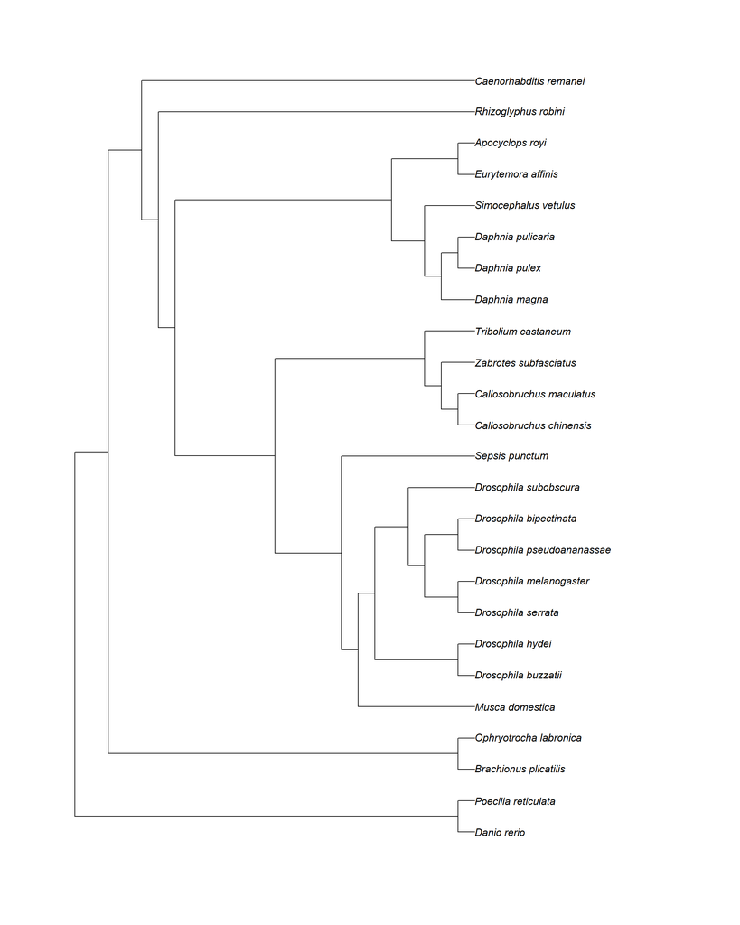

```r
tree$tip.label <- strip_ott_ids(tree$tip.label) # Remove ott IDs for presentation
#plot(tree, no.margin=TRUE, cex=1)

tree <- multi2di(tree, random = TRUE) # Resolve polytomy at random, but it matches classification from Cornetti et al. 2019. Molecular Phylogenetics and Evolution; with D. pulex and D. pulicaria being more closely related to eachother than D. magna
phylo_tree <- compute.brlen(tree, method = "Grafen", power = 1) # Compute branch lengths

# Plot tree
plot(phylo_tree)
```

```r
# Compute phylogenetic correlation matrix
phylo_matrix <- vcv(phylo_tree, cor = T)  # The vcv function returns a variance-covariance matrix

# Add an additional column for phylogeny
data <- mutate(data, phylogeny = gsub(" ", "_", species),
               obs = row_number())

# Convert tibble to data frame
data <- as.data.frame(data)

# Rename trait type
data$trait_type <- factor(data$trait_type,
                          levels = c("body_size", "fecundity", "survival"),
                          labels = c("Body size", "Fecundity", "Survival"))

# Rename temperature regime
data$warm_cold <- factor(data$warm_cold,
                          levels = c("cold", "warm"),
                          labels = c("Cold", "Warm"))
```

### **Non-independence due to shared cohorts**

Because different traits were sometimes measured on the cohort of animals, we account for this source of non-independence with a variance-covariance matrix to correlate errors of each trait (cf. Noble et al. 2017)

```r
# VCV matrix for lnRR
VCV_lnRR <- vcalc(vi = var_lnRR,
                  cluster = shared_control_ID,
                  rho = 0.5,
                  obs = obs,
                  data = data)

# VCV matrix for lnCVR
VCV_lnCVR <- vcalc(vi = var_lnCVR,
                  cluster = shared_control_ID,
                  rho = 0.5,
                  obs = obs,
                  data = data)

# VCV matrix for lnVR
VCV_lnVR <- vcalc(vi = var_lnVR,
                  cluster = shared_control_ID,
                  rho = 0.5,
                  obs = obs,
                  data = data)
```

# **Overview of the dataset**

```r
# Summarize overall metrics
overall <- data %>%
  summarise(
    Group = "Overall",
    `Number of Studies` = n_distinct(ref),
    `Number of Species` = n_distinct(species),
    `Number of Effect Sizes` = n_distinct(obs)
  )

# Summarize by trait
by_trait <- data %>%
  group_by(trait_type) %>%
  summarise(
    Group = paste("Trait -", unique(trait_type)),
    `Number of Studies` = n_distinct(ref),
    `Number of Species` = n_distinct(species),
    `Number of Effect Sizes` = n_distinct(obs)
  ) %>%
  ungroup()

# Summarize by temperature regime
by_temperature <- data %>%
  group_by(warm_cold) %>%
  summarise(
    Group = paste("Temperature regime -", unique(warm_cold)),
    `Number of Studies` = n_distinct(ref),
    `Number of Species` = n_distinct(species),
    `Number of Effect Sizes` = n_distinct(obs)
  ) %>%
  ungroup()

# Combine all summaries
table_sample_sizes <- bind_rows(overall, by_trait, by_temperature) %>%
  dplyr::select(-trait_type, -warm_cold)

# Create the table
table_sample_sizes %>%
  kable() %>%
  kable_styling(full_width = FALSE, position = "center", fixed_thead = TRUE) %>%
  column_spec(1, bold = TRUE, border_right = TRUE) %>%
  row_spec(0, background = "white", color = "black", bold = TRUE) %>%
  kable_styling(fixed_thead = TRUE)
```

| Group | Number of Studies | Number of Species | Number of Effect Sizes |
| --- | --- | --- | --- |
| Overall | 44 | 25 | 476 |
| Trait - Body size | 27 | 14 | 171 |
| Trait - Fecundity | 31 | 22 | 196 |
| Trait - Survival | 22 | 13 | 109 |
| Temperature regime - Cold | 13 | 5 | 95 |
| Temperature regime - Warm | 38 | 23 | 381 |

# **Main meta-analytic models**

Note that these models take a substantial amount of time to run. Therefore, these models were ran on the computational cluster Katana, supported by Research Technology Services at UNSW Sydney. Resources needed to run these models are provided in the /pbs/ folder, and the R code used for each model is in the R/models/ folder.

## **Changes in trait means (lnRR)**

### **Overall model**

#### *Model specification*

```r
# Model specification
formula <- bf(lnRR ~ trait_type -1 + # Separate effects by trait type
                (trait_type-1|ref) + # Correlation between traits among studies
                (1|species) + # Species-level random effect
                (1|gr(phylogeny, cov = phylo_matrix)) + # Phylogenetic relatedness
                (1|experiment_ID) + # Experiment-level random effect
                (1|obs) + # Observation-level random effect
                fcor(VCV_lnRR)) # Variance covariance matix of correlated sampling variances

# Define priors
prior = c(
  prior(constant(1), class = "sigma")
) # Because the residual variance-covariance structure is specified in fcor, there is no need to estimate sigma so it is left as a constant

# Fit model
lnRR_model_overall <- brm(formula,
                           family = gaussian(),
                           data = data,
                           data2 = list(phylo_matrix = phylo_matrix,
                                        VCV_lnRR = VCV_lnRR),
                           prior = prior,
                           control = list(adapt_delta = 0.99, max_treedepth = 15),
                           iter = 4000,
                           warmup = 2000,
                           chains = 4,
                           cores = 4,
                           seed = 123)

# Save model
saveRDS(lnRR_model_overall, file = "RData/lnRR_model_overall.rds")
```

#### *Model output*

```r
# Load model
lnRR_model_overall <- readRDS("RData/lnRR_model_overall.rds")

# Display model output
summary(lnRR_model_overall)
```

```
##  Family: gaussian
##   Links: mu = identity; sigma = identity
## Formula: lnRR ~ trait_type - 1 + (trait_type - 1 | ref) + (1 | species) + (1 | gr(phylogeny, cov = phylo_matrix)) + (1 | experiment_ID) + (1 | obs) + fcor(VCV_lnRR)
##    Data: data (Number of observations: 476)
##   Draws: 4 chains, each with iter = 4000; warmup = 2000; thin = 1;
##          total post-warmup draws = 8000
##
## Multilevel Hyperparameters:
## ~experiment_ID (Number of levels: 88)
##               Estimate Est.Error l-95% CI u-95% CI Rhat Bulk_ESS Tail_ESS
## sd(Intercept)     0.05      0.01     0.03     0.06 1.00     2428     4079
##
## ~obs (Number of levels: 476)
##               Estimate Est.Error l-95% CI u-95% CI Rhat Bulk_ESS Tail_ESS
## sd(Intercept)     0.08      0.01     0.07     0.09 1.00     2314     4469
##
## ~phylogeny (Number of levels: 25)
##               Estimate Est.Error l-95% CI u-95% CI Rhat Bulk_ESS Tail_ESS
## sd(Intercept)     0.02      0.02     0.00     0.06 1.00     4112     5342
##
## ~ref (Number of levels: 44)
##                                              Estimate Est.Error l-95% CI
## sd(trait_typebody_size)                          0.01      0.01     0.00
## sd(trait_typefecundity)                          0.19      0.04     0.13
## sd(trait_typesurvival)                           0.11      0.03     0.06
## cor(trait_typebody_size,trait_typefecundity)    -0.14      0.47    -0.90
## cor(trait_typebody_size,trait_typesurvival)      0.03      0.49    -0.86
## cor(trait_typefecundity,trait_typesurvival)      0.08      0.50    -0.84
##                                              u-95% CI Rhat Bulk_ESS Tail_ESS
## sd(trait_typebody_size)                          0.03 1.00     2591     4316
## sd(trait_typefecundity)                          0.27 1.00     3834     5633
## sd(trait_typesurvival)                           0.17 1.00     4383     5237
## cor(trait_typebody_size,trait_typefecundity)     0.80 1.01      627     1380
## cor(trait_typebody_size,trait_typesurvival)      0.89 1.00     1331     3070
## cor(trait_typefecundity,trait_typesurvival)      0.89 1.00     1888     3903
##
## ~species (Number of levels: 25)
##               Estimate Est.Error l-95% CI u-95% CI Rhat Bulk_ESS Tail_ESS
## sd(Intercept)     0.01      0.01     0.00     0.04 1.00     5301     5459
##
## Regression Coefficients:
##                     Estimate Est.Error l-95% CI u-95% CI Rhat Bulk_ESS Tail_ESS
## trait_typebody_size    -0.00      0.02    -0.04     0.04 1.00     5199     4640
## trait_typefecundity    -0.02      0.04    -0.11     0.06 1.00     5736     6136
## trait_typesurvival      0.02      0.03    -0.04     0.09 1.00     6349     6309
##
## Further Distributional Parameters:
##       Estimate Est.Error l-95% CI u-95% CI Rhat Bulk_ESS Tail_ESS
## sigma     1.00      0.00     1.00     1.00   NA       NA       NA
##
## Draws were sampled using sampling(NUTS). For each parameter, Bulk_ESS
## and Tail_ESS are effective sample size measures, and Rhat is the potential
## scale reduction factor on split chains (at convergence, Rhat = 1).
```

```r
# Cleaned model output
as.data.frame(fixef(lnRR_model_overall, summary = TRUE)) %>%
  # Rename categorical variables for cleaner display
  rownames_to_column(var = "Parameter") %>%
  mutate(
    Parameter = gsub("trait_type([a-z_]+)", "\\1", Parameter)
  ) %>%
  # Round numbers to 3 decimal points
  mutate(across(c(Estimate, Q2.5, Q97.5), ~ round(., 3))) %>%
  select(Parameter, Estimate, `Lower CI` = Q2.5, `Upper CI` = Q97.5) %>%
  kable() %>%
  kable_styling(full_width = FALSE, position = "center", fixed_thead = TRUE) %>%
  column_spec(1, bold = TRUE, border_right = TRUE) %>%
  row_spec(0, background = "white", color = "black", bold = TRUE) %>%
  kable_styling(fixed_thead = TRUE)
```

| Parameter | Estimate | Lower CI | Upper CI |
| --- | --- | --- | --- |
| body_size | -0.001 | -0.044 | 0.040 |
| fecundity | -0.022 | -0.106 | 0.061 |
| survival | 0.023 | -0.041 | 0.090 |

#### *Heterogeneity analysis*

```r
# Extracting the posterior distribution from the model
posterior <- posterior_samples(lnRR_model_overall)

# Calculate measurement error variance
sigma2_v <- sum(1/diag(VCV_lnRR)) * (length(diag(VCV_lnRR))- 1)/(sum(1/diag(VCV_lnRR))^2 - sum((1/diag(VCV_lnRR))^2))

# Calculate the total variance (including the measurement error variance)
var_total <- posterior$sd_experiment_ID__Intercept +
             posterior$sd_obs__Intercept +
             posterior$sd_phylogeny__Intercept +
             posterior$sd_ref__trait_typebody_size +
             posterior$sd_ref__trait_typefecundity +
             posterior$sd_ref__trait_typesurvival +
             posterior$sd_species__Intercept +
             sigma2_v

# Calculate heterogeneity (I2)
I2 <- list(
    I2_total = (var_total - sigma2_v) / var_total, # Total heterogeneity
    I2_study = (posterior$sd_ref__trait_typebody_size + # Heterogeneity explained by study differences
                posterior$sd_ref__trait_typefecundity +
                posterior$sd_ref__trait_typesurvival) / var_total,
    I2_exp = posterior$sd_experiment_ID__Intercept / var_total, # Heterogeneity explained by experiment differences
    I2_sp = posterior$sd_species__Intercept / var_total, # Heterogeneity explained by species differences
    I2_phylo = posterior$sd_phylogeny__Intercept / var_total, # Heterogeneity explained by phylogenetic relatedness
    I2_obs = posterior$sd_obs__Intercept / var_total # Heterogeneity explained by residual variation

)

# Calculate mean and credible intervals
summary_table <- t(sapply(I2, function(x) {
    c(Mean = 100*round(mean(x),4),
      ` ` = 100* round(quantile(x, 0.025),4),
      ` ` = 100*round(quantile(x, 0.975),4))
}))

# Customise table
summary_table <- summary_table %>%
    as.data.frame() %>%
    rownames_to_column("Variable") %>%
    mutate(
        Variable = recode(Variable,
                          "I2_total"  = "Total",
                          "I2_study"  = "Study",
                          "I2_exp"    = "Experiment",
                          "I2_sp"     = "Species",
                          "I2_phylo"  = "Phylogeny",
                          "I2_obs"    = "Residual")
    ) %>%
    rename(
        lower_HPD = ` .2.5%`,
        upper_HPD = ` .97.5%`
    ) %>%
  mutate(
    Variable = paste0("I<sup>2</sup><sub>", Variable)   # Create a new column with formatted I² and subscripts
  )


# Display table
kable(summary_table, "html", escape = FALSE,
      col.names = c("Heterogeneity (%)", "Mean", "Lower HPD", "Upper HPD"),
      align = c('l', 'r', 'r', 'r')) %>%
  kable_styling(full_width = FALSE, position = "center", fixed_thead = TRUE) %>%
  column_spec(1, width = "200px", bold = TRUE, border_right = TRUE) %>%
  row_spec(0, background = "white", color = "black", bold = TRUE) %>%
  kable_styling(fixed_thead = TRUE)
```

| Heterogeneity (%) | Mean | Lower HPD | Upper HPD |
| --- | --- | --- | --- |
| I<sup>2</sup><sub>Total</sub> | 99.97 | 99.97 | 99.98 |
| I<sup>2</sup><sub>Study</sub> | 65.40 | 55.25 | 73.94 |
| I<sup>2</sup><sub>Experiment</sub> | 9.96 | 6.52 | 14.36 |
| I<sup>2</sup><sub>Species</sub> | 2.77 | 0.11 | 7.91 |
| I<sup>2</sup><sub>Phylogeny</sub> | 4.42 | 0.19 | 12.53 |
| I<sup>2</sup><sub>Residual</sub> | 17.43 | 13.34 | 22.34 |

#### *Data visualisation*

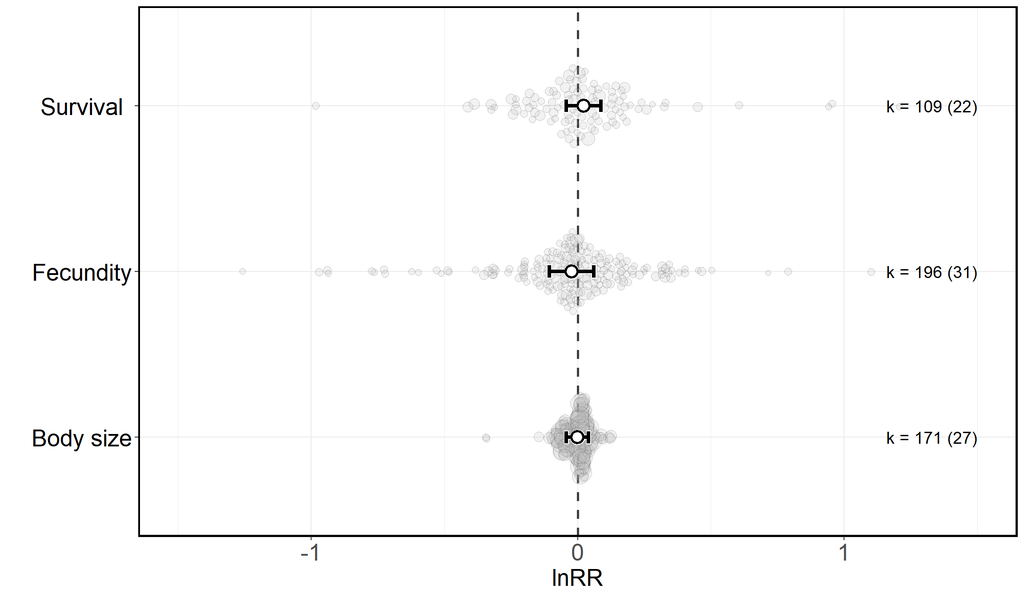

```r
# Generate predictions
emmeans_overall <- as.data.frame(emmeans(lnRR_model_overall, ~ trait_type))

emmeans_overall$trait_type <- factor(emmeans_overall$trait_type,
                          levels = c("body_size", "fecundity", "survival"),
                          labels = c("Body size", "Fecundity", "Survival"))

# Calculate sample sizes and study counts
sample_sizes_traits <- data %>%
  group_by(trait_type) %>%
  summarise(
    estimates = n(),
    studies = n_distinct(ref)
  )

# Plot
ggplot() +
    geom_hline(yintercept = 0, # Horizontal line
               linetype = 2,
               colour = "black",
               alpha = 0.75,
               lwd=1) +
    geom_quasirandom(data = data, # Plot effect sizes, scaled by precision
                     aes(x = trait_type,
                         y = lnRR,
                         size = 1/sqrt(var_lnRR)),
                     fill = "gray75",
                     shape = 21,
                     width = 0.25,
                     alpha = 0.2) +
    geom_errorbar(data = emmeans_overall,   # Plot the point estimates in white for background
                  aes(ymin = lower.HPD,
                      ymax = upper.HPD,
                      x = trait_type),
                  size = 2,
                  width = 0.085,
                  color = "white") +
    geom_point(data = emmeans_overall, # Plot the credible intervals in white for background
               aes(x = trait_type,
                   y = emmean),
               size = 4.5,
               stroke = 1.5,
               shape = 21,
               color="white",
               fill = "white") +
    geom_errorbar(data = emmeans_overall,  # Plot the point estimates
                  aes(x = trait_type,
                      ymin = lower.HPD,
                      ymax = upper.HPD),
                  size = 1.5,
                  width = 0.075,
                  color = "black") +
    geom_point(data = emmeans_overall, # Plot the credible intervals
               aes(x = trait_type,
                   y = emmean),
               size = 4,
               shape = 21,
               stroke = 1.5,
               color="black",
               fill = "white") +
    geom_text(data = sample_sizes_traits,  # Sample size annotations
              aes(x = trait_type,
                  y = 1.5,
                  label = paste0("k = ", estimates, " (", studies, ")")),
              hjust = 1, size = 5, show.legend = FALSE) +
    theme_bw() +     # Customize the plot
    labs(y = "lnRR", x = "") +
    scale_size_continuous(range = c(2, 8))+
    theme(text = element_text(size = 20, color = "black"),
          legend.title = ggplot2::element_text(size = 16),
          legend.text = ggplot2::element_text(size = 14),
          axis.text.y = ggplot2::element_text(size = 20,
                colour = "black", hjust = 0.5),
          axis.text.x = ggplot2::element_text(size = 20),
          panel.border = element_rect(color = "black", size = 1.5)) +
    guides(color = "none", size = "none")+
    coord_flip() +
    ylim(-1.5, 1.5)
```

```r
# Save figure
ggsave(file = "fig/lnRR_overall.png", width = 12, height = 7, dpi = 500)
```

### **Temperature regime**

#### *Model specification*

```r
# Model specification
formula <- bf(lnRR ~ trait_type:warm_cold -1 + # Separate effects by trait type
                (trait_type-1|ref) + # Correlation between traits among studies
                (1|species) + # Species-level random effect
                (1|gr(phylogeny, cov = phylo_matrix)) + # Phylogenetic relatedness
                (1|experiment_ID) + # Experiment-level random effect
                (1|obs) + # Observation-level random effect
                fcor(VCV_lnRR)) # Variance covariance matix of correlated sampling variances

# Define priors
prior = c(
  prior(constant(1), class = "sigma")
) # Because the residual variance-covariance structure is specified in fcor, there is no need to estimate sigma so it is left as a constant

# Fit model
lnRR_model_warm_cold <- brm(formula,
                  family = gaussian(),
                  data = data,
                  data2 = list(phylo_matrix = phylo_matrix,
                               VCV_lnRR = VCV_lnRR),
                  prior = prior,
                  control = list(adapt_delta = 0.99, max_treedepth = 15),
                  iter = 4000,
                  warmup = 2000,
                  chains = 4,
                  cores = 4,
                  seed = 123)

# Save model
saveRDS(lnRR_model_warm_cold, file = "RData/lnRR_model_warm_cold.rds")
```

#### *Model output*

```r
# Load model
lnRR_model_warm_cold <- readRDS("RData/lnRR_model_warm_cold.rds")

# Display model output
summary(lnRR_model_warm_cold)
```

```
##  Family: gaussian
##   Links: mu = identity; sigma = identity
## Formula: lnRR ~ trait_type:warm_cold - 1 + (trait_type - 1 | ref) + (1 | species) + (1 | gr(phylogeny, cov = phylo_matrix)) + (1 | experiment_ID) + (1 | obs) + fcor(VCV_lnRR)
##    Data: data (Number of observations: 476)
##   Draws: 4 chains, each with iter = 4000; warmup = 2000; thin = 1;
##          total post-warmup draws = 8000
##
## Multilevel Hyperparameters:
## ~experiment_ID (Number of levels: 88)
##               Estimate Est.Error l-95% CI u-95% CI Rhat Bulk_ESS Tail_ESS
## sd(Intercept)     0.05      0.01     0.03     0.06 1.00     2199     3535
##
## ~obs (Number of levels: 476)
##               Estimate Est.Error l-95% CI u-95% CI Rhat Bulk_ESS Tail_ESS
## sd(Intercept)     0.08      0.01     0.07     0.09 1.00     1978     3594
##
## ~phylogeny (Number of levels: 25)
##               Estimate Est.Error l-95% CI u-95% CI Rhat Bulk_ESS Tail_ESS
## sd(Intercept)     0.02      0.02     0.00     0.07 1.00     2828     3846
##
## ~ref (Number of levels: 44)
##                                              Estimate Est.Error l-95% CI
## sd(trait_typebody_size)                          0.01      0.01     0.00
## sd(trait_typefecundity)                          0.21      0.04     0.14
## sd(trait_typesurvival)                           0.11      0.03     0.06
## cor(trait_typebody_size,trait_typefecundity)    -0.14      0.48    -0.91
## cor(trait_typebody_size,trait_typesurvival)      0.03      0.49    -0.86
## cor(trait_typefecundity,trait_typesurvival)      0.00      0.49    -0.85
##                                              u-95% CI Rhat Bulk_ESS Tail_ESS
## sd(trait_typebody_size)                          0.03 1.00     1823     3152
## sd(trait_typefecundity)                          0.30 1.00     3014     4756
## sd(trait_typesurvival)                           0.18 1.00     2917     3897
## cor(trait_typebody_size,trait_typefecundity)     0.81 1.01      439      934
## cor(trait_typebody_size,trait_typesurvival)      0.88 1.01      922     2295
## cor(trait_typefecundity,trait_typesurvival)      0.85 1.00     1462     2565
##
## ~species (Number of levels: 25)
##               Estimate Est.Error l-95% CI u-95% CI Rhat Bulk_ESS Tail_ESS
## sd(Intercept)     0.01      0.01     0.00     0.04 1.00     3404     3916
##
```

[output cut: 8 more lines]

```
##                                   Bulk_ESS Tail_ESS
## trait_typebody_size:warm_coldcold     1848     2500
## trait_typefecundity:warm_coldcold     3849     5593
## trait_typesurvival:warm_coldcold      3599     4514
## trait_typebody_size:warm_coldwarm     2375     3035
## trait_typefecundity:warm_coldwarm     3592     4745
## trait_typesurvival:warm_coldwarm      3239     4369
##
## Further Distributional Parameters:
##       Estimate Est.Error l-95% CI u-95% CI Rhat Bulk_ESS Tail_ESS
## sigma     1.00      0.00     1.00     1.00   NA       NA       NA
##
## Draws were sampled using sampling(NUTS). For each parameter, Bulk_ESS
## and Tail_ESS are effective sample size measures, and Rhat is the potential
## scale reduction factor on split chains (at convergence, Rhat = 1).
```

```r
# R2
r2(lnRR_model_warm_cold)
```

```
## # Bayesian R2 with Compatibility Interval
##
##   Conditional R2: 0.289 (95% CI [0.237, 0.345])
##      Marginal R2: 0.013 (95% CI [5.466e-04, 0.039])
```

```r
# Cleaned model output
as.data.frame(fixef(lnRR_model_warm_cold, summary = TRUE)) %>%
  # Rename categorical variables for cleaner display
  rownames_to_column(var = "Parameter") %>%
  mutate(
    # Simplify `trait_type` and `warm_cold` interactions
    Parameter = gsub("trait_type([a-z_]+):warm_cold(cold|warm)", "\\1(\\2)", Parameter)
  ) %>%
  # Round numbers to 3 decimal points
  mutate(across(c(Estimate, Q2.5, Q97.5), ~ round(., 3))) %>%
  select(Parameter, Estimate, `Lower CI` = Q2.5, `Upper CI` = Q97.5) %>%
  kable() %>%
  kable_styling(full_width = FALSE, position = "center", fixed_thead = TRUE) %>%
  column_spec(1, bold = TRUE, border_right = TRUE) %>%
  row_spec(0, background = "white", color = "black", bold = TRUE) %>%
  kable_styling(fixed_thead = TRUE)
```

| Parameter | Estimate | Lower CI | Upper CI |
| --- | --- | --- | --- |
| body_size(cold) | 0.014 | -0.036 | 0.066 |
| fecundity(cold) | -0.080 | -0.222 | 0.056 |
| survival(cold) | 0.030 | -0.074 | 0.139 |
| body_size(warm) | -0.006 | -0.051 | 0.036 |
| fecundity(warm) | -0.006 | -0.097 | 0.089 |
| survival(warm) | 0.022 | -0.050 | 0.093 |

#### *Contrasts*

```r
# Generate predictions
emms <- emmeans(lnRR_model_warm_cold,
                specs = ~ warm_cold | trait_type)

# Generate contrasts
contrast(emms, method = "pairwise")
```

```
## trait_type = body_size:
##  contrast    estimate lower.HPD upper.HPD
##  cold - warm   0.0205   -0.0114    0.0542
##
## trait_type = fecundity:
##  contrast    estimate lower.HPD upper.HPD
##  cold - warm  -0.0731   -0.2010    0.0595
##
## trait_type = survival:
##  contrast    estimate lower.HPD upper.HPD
##  cold - warm   0.0083   -0.0993    0.1137
##
## Point estimate displayed: median
## HPD interval probability: 0.95
```

#### *Data visualisation*

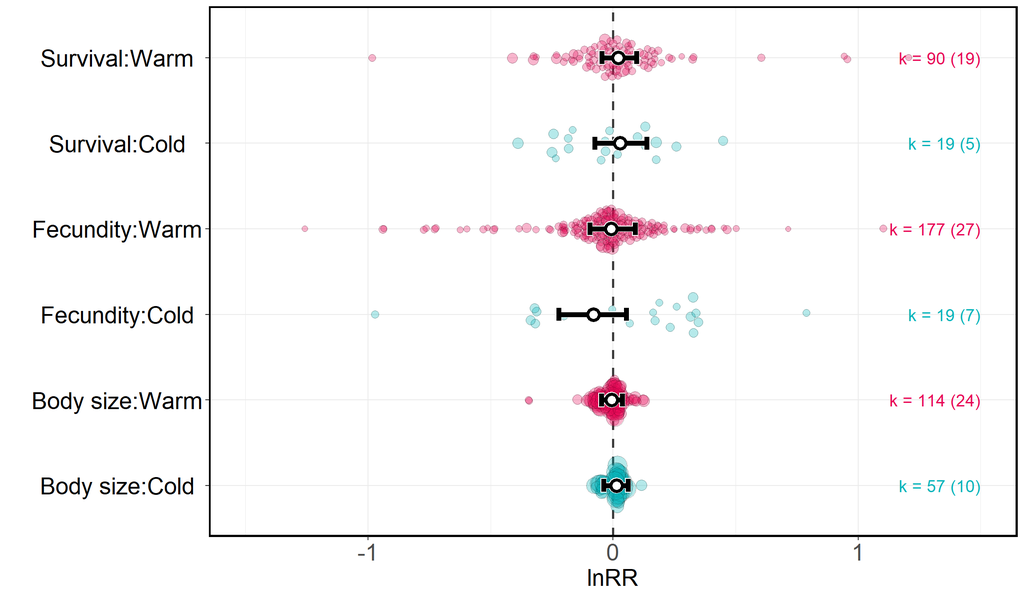

```r
# Generate predictions
emmeans_warm_cold <- as.data.frame(emmeans(lnRR_model_warm_cold,
                                           specs = ~ warm_cold | trait_type))

emmeans_warm_cold$trait_type <- factor(emmeans_warm_cold$trait_type,
                          levels = c("body_size", "fecundity", "survival"),
                          labels = c("Body size", "Fecundity", "Survival"))

emmeans_warm_cold$warm_cold <- factor(emmeans_warm_cold$warm_cold,
                          levels = c("cold", "warm"),
                          labels = c("Cold", "Warm"))

# Calculate sample sizes and study counts
sample_sizes <- data %>%
  group_by(trait_type, warm_cold) %>%
  summarise(
    estimates = n(),
    studies = n_distinct(ref)
  )

# Plot
ggplot() +
    geom_hline(yintercept = 0, # Horizontal line
               linetype = 2,
               colour = "black",
               alpha = 0.75,
               lwd=1) +
    geom_quasirandom(data = data,     # Plot effect sizes, scaled by precision
                     aes(x = trait_type:warm_cold,
                         y = lnRR,
                         fill = trait_type:warm_cold,
                         size = 1/sqrt(var_lnRR)),
                     color = "black",
                     shape = 21,
                     width = 0.25,
                     alpha = 0.3) +
    geom_errorbar(data = emmeans_warm_cold,  # Plot the point estimates in white for background
                  aes(x = trait_type:warm_cold,
                      ymin = lower.HPD,
                      ymax = upper.HPD),
                  color="white",
                  size = 2.5,
                  width = 0.17) +
    geom_point(data = emmeans_warm_cold,  # Plot the credible intervals in white for background
               aes(x = trait_type:warm_cold,
                   y = emmean),
               shape = 21,
               size = 4,
               stroke = 2,
               color="white",
               fill = "white") +
    geom_errorbar(data = emmeans_warm_cold, # Plot the point estimates
                  aes(x = trait_type:warm_cold,
                      ymin = lower.HPD,
                      ymax = upper.HPD),
                  color="black",
                  size = 2,
                  width = 0.15) +
    geom_point(data = emmeans_warm_cold, # Plot the credible intervals
               aes(x = trait_type:warm_cold,
                   y = emmean),
               shape = 21,
               size = 3.5,
               stroke = 2,
               color="black",
               fill = "white") +
    geom_text(data = sample_sizes,  # Sample size annotations
              aes(x = trait_type:warm_cold,
                  y = 1.5,
                  label = paste0("k = ", estimates, " (", studies, ")"),
                  color = warm_cold),
              hjust = 1, size = 5, show.legend = FALSE) +
    theme_bw() +     # Customize the plot
    labs(y = "lnRR", x = "") +
    scale_size_continuous(range = c(2, 8))+
#    scale_fill_manual(values = c("#A5F820", "#73B706",  "#9CEFFC", "#06A2BA",  "#FED2ED", "#B90674"))+
    scale_fill_manual(values = c("#06B4BA", "#E80756", "#06B4BA", "#E80756", "#06B4BA", "#E80756"))+
    scale_color_manual(values = c("Cold" = "#06B4BA", "Warm" = "#E80756")) +  # Text colour
    theme(text = element_text(size = 20, color = "black"),
          legend.title = ggplot2::element_text(size = 16),
          legend.text = ggplot2::element_text(size = 14),
          axis.text.y = ggplot2::element_text(size = 20,
                colour = "black", hjust = 0.5),
          axis.text.x = ggplot2::element_text(size = 20),
          panel.border = element_rect(color = "black", size = 1.5)) +
    guides(fill = "none", size = "none")+
    coord_flip() +
    ylim(-1.5, 1.5)
```

```r
ggsave(file = "fig/lnRR_warm_cold.png", width = 12, height = 7, dpi = 500)
```

### **Assay temperature difference**

We calculated the difference between the assay temperature and control temperature (assay_temp_diff) to account for the fact that animals were tested to a different range of temperatures. We also predicted that effects will vary if traits are assayed at colder- or warmer-than-control conditions, depending on the temperature regime. Because the variation in assay temperature generates some nuisance heterogeneity (sensu Noble et al., 2017), the results of subsequent models were provided after controlling for assay temperature differences. In order words, the results of all moderators are conditional on assay temperature, meaning that results are interpretable as the difference between control and selected lines, when animals are tested at the control temperature.

#### *Model specification*

```r
# Model specification
formula <- bf(lnRR ~ 0 + trait_type:warm_cold + trait_type:warm_cold:assay_temp_diff + # Separate effects by trait type
                (trait_type-1|ref) + # Correlation between traits among studies
                (1|species) + # Species-level random effect
                (1|gr(phylogeny, cov = phylo_matrix)) + # Phylogenetic relatedness
                (1|experiment_ID) + # Experiment-level random effect
                (1|obs) + # Observation-level random effect
                fcor(VCV_lnRR)) # Variance covariance matix of correlated sampling variances

# Define priors
prior = c(
  prior(constant(1), class = "sigma")
) # Because the residual variance-covariance structure is specified in fcor, there is no need to estimate sigma so it is left as a constant

# Fit model
lnRR_model_assay_temp_diff <- brm(formula,
                                  family = gaussian(),
                                  data = data,
                                  data2 = list(phylo_matrix = phylo_matrix,
                                               VCV_lnRR = VCV_lnRR),
                                  prior = prior,
                                  control = list(adapt_delta = 0.99, max_treedepth = 15),
                                  iter = 4000,
                                  warmup = 2000,
                                  chains = 4,
                                  cores = 4,
                                  seed = 123)

# Save model
saveRDS(lnRR_model_assay_temp_diff, file = "RData/lnRR_model_assay_temp_diff.rds")
```

#### *Model output*

```r
# Load model
lnRR_model_assay_temp_diff <- readRDS("RData/lnRR_model_assay_temp_diff.rds")

# Display model output
summary(lnRR_model_assay_temp_diff)
```

```
##  Family: gaussian
##   Links: mu = identity; sigma = identity
## Formula: lnRR ~ 0 + trait_type:warm_cold + trait_type:warm_cold:assay_temp_diff + (trait_type - 1 | ref) + (1 | species) + (1 | gr(phylogeny, cov = phylo_matrix)) + (1 | experiment_ID) + (1 | obs) + fcor(VCV_lnRR)
##    Data: data (Number of observations: 476)
##   Draws: 4 chains, each with iter = 4000; warmup = 2000; thin = 1;
##          total post-warmup draws = 8000
##
## Multilevel Hyperparameters:
## ~experiment_ID (Number of levels: 88)
##               Estimate Est.Error l-95% CI u-95% CI Rhat Bulk_ESS Tail_ESS
## sd(Intercept)     0.02      0.01     0.00     0.04 1.01      836     1101
##
## ~obs (Number of levels: 476)
##               Estimate Est.Error l-95% CI u-95% CI Rhat Bulk_ESS Tail_ESS
## sd(Intercept)     0.05      0.00     0.04     0.06 1.00     1704     3138
##
## ~phylogeny (Number of levels: 25)
##               Estimate Est.Error l-95% CI u-95% CI Rhat Bulk_ESS Tail_ESS
## sd(Intercept)     0.02      0.02     0.00     0.07 1.00     2385     3776
##
## ~ref (Number of levels: 44)
##                                              Estimate Est.Error l-95% CI
## sd(trait_typebody_size)                          0.01      0.01     0.00
## sd(trait_typefecundity)                          0.21      0.04     0.15
## sd(trait_typesurvival)                           0.13      0.03     0.08
## cor(trait_typebody_size,trait_typefecundity)    -0.13      0.46    -0.89
## cor(trait_typebody_size,trait_typesurvival)      0.08      0.49    -0.84
## cor(trait_typefecundity,trait_typesurvival)     -0.07      0.52    -0.90
##                                              u-95% CI Rhat Bulk_ESS Tail_ESS
## sd(trait_typebody_size)                          0.02 1.00     1547     3228
## sd(trait_typefecundity)                          0.30 1.00     3481     5702
## sd(trait_typesurvival)                           0.20 1.00     3243     5184
## cor(trait_typebody_size,trait_typefecundity)     0.77 1.01      426     1075
## cor(trait_typebody_size,trait_typesurvival)      0.89 1.00      862     2032
## cor(trait_typefecundity,trait_typesurvival)      0.83 1.01      799     2678
##
## ~species (Number of levels: 25)
##               Estimate Est.Error l-95% CI u-95% CI Rhat Bulk_ESS Tail_ESS
## sd(Intercept)     0.02      0.01     0.00     0.04 1.00     1970     3307
##
```

[output cut: 33 more lines]

```
## trait_typesurvival:warm_coldwarm                      4161
## trait_typebody_size:warm_coldcold:assay_temp_diff     3599
## trait_typefecundity:warm_coldcold:assay_temp_diff     6330
## trait_typesurvival:warm_coldcold:assay_temp_diff      5524
## trait_typebody_size:warm_coldwarm:assay_temp_diff     4949
## trait_typefecundity:warm_coldwarm:assay_temp_diff     5467
## trait_typesurvival:warm_coldwarm:assay_temp_diff      5841
##
## Further Distributional Parameters:
##       Estimate Est.Error l-95% CI u-95% CI Rhat Bulk_ESS Tail_ESS
## sigma     1.00      0.00     1.00     1.00   NA       NA       NA
##
## Draws were sampled using sampling(NUTS). For each parameter, Bulk_ESS
## and Tail_ESS are effective sample size measures, and Rhat is the potential
## scale reduction factor on split chains (at convergence, Rhat = 1).
```

```r
# R2
r2(lnRR_model_assay_temp_diff)
```

```
## # Bayesian R2 with Compatibility Interval
##
##   Conditional R2: 0.278 (95% CI [0.228, 0.329])
##      Marginal R2: 0.070 (95% CI [0.049, 0.101])
```

```r
# Cleaned model output
as.data.frame(fixef(lnRR_model_assay_temp_diff, summary = TRUE)) %>%
  # Rename categorical variables for cleaner display
  rownames_to_column(var = "Parameter") %>%
  mutate(
    Parameter = gsub("trait_type([a-z_]+):warm_cold(cold|warm)", "\\1(\\2)", Parameter),
    Parameter = gsub("trait_type([a-z_]+)\\(warm\\):assay_temp_diff", "\\1(warm): assay_temp_diff", Parameter)
  ) %>%
  # Round numbers to 3 decimal points
  mutate(across(c(Estimate, Q2.5, Q97.5), ~ round(., 3))) %>%
  select(Parameter, Estimate, `Lower CI` = Q2.5, `Upper CI` = Q97.5) %>%
  kable() %>%
  kable_styling(full_width = FALSE, position = "center", fixed_thead = TRUE) %>%
  column_spec(1, bold = TRUE, border_right = TRUE) %>%
  row_spec(0, background = "white", color = "black", bold = TRUE) %>%
  kable_styling(fixed_thead = TRUE)
```

| Parameter | Estimate | Lower CI | Upper CI |
| --- | --- | --- | --- |
| body_size(cold) | 0.022 | -0.022 | 0.067 |
| fecundity(cold) | -0.167 | -0.295 | -0.042 |
| survival(cold) | -0.062 | -0.166 | 0.052 |
| body_size(warm) | -0.001 | -0.042 | 0.041 |
| fecundity(warm) | -0.036 | -0.126 | 0.056 |
| survival(warm) | -0.010 | -0.087 | 0.062 |
| body_size(cold):assay_temp_diff | 0.001 | -0.004 | 0.006 |
| fecundity(cold):assay_temp_diff | -0.062 | -0.073 | -0.052 |
| survival(cold):assay_temp_diff | -0.044 | -0.053 | -0.034 |
| body_size(warm):assay_temp_diff | -0.001 | -0.004 | 0.002 |
| fecundity(warm):assay_temp_diff | 0.004 | -0.003 | 0.011 |
| survival(warm):assay_temp_diff | 0.005 | -0.002 | 0.011 |

#### *Data visualisation*

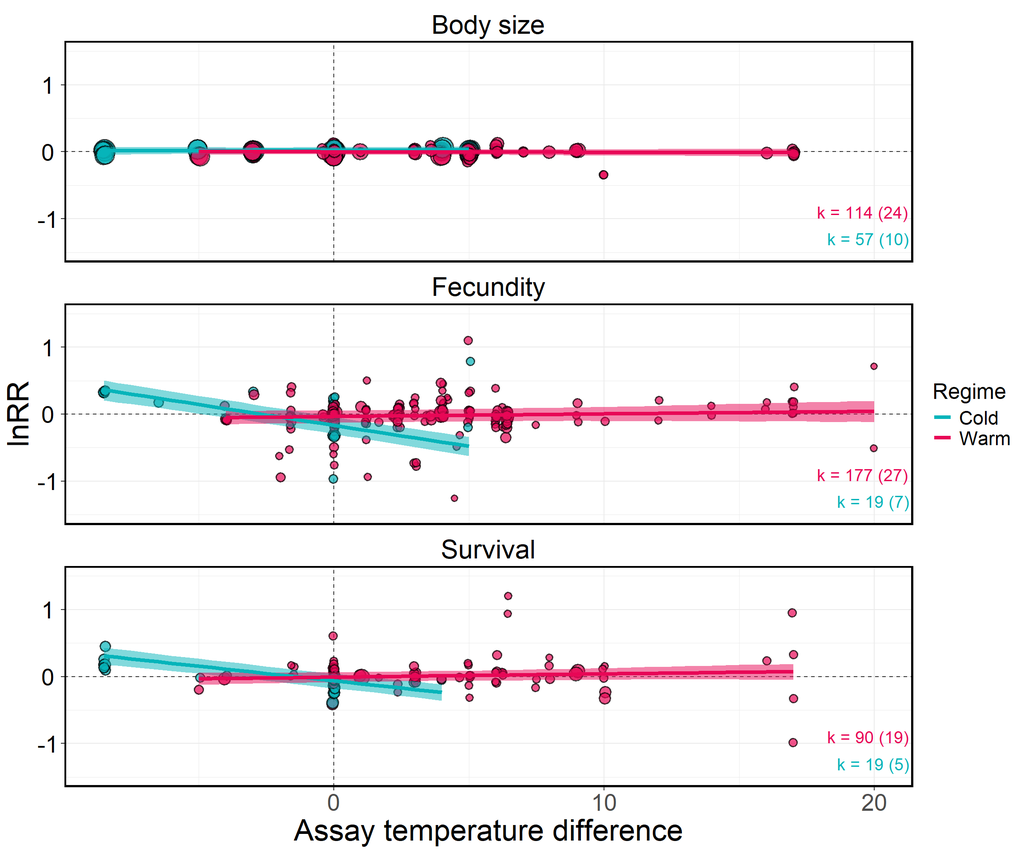

```r
# Generate predictions
emmeans_assay_temp_diff <- as.data.frame(emmeans(
  lnRR_model_assay_temp_diff,
  specs = ~ assay_temp_diff | trait_type * warm_cold,
  at = list(assay_temp_diff = seq(min(data$assay_temp_diff), max(data$assay_temp_diff), by = 0.5)))
  )

# Calculate range of values for each category
range_df <- data %>%
  group_by(trait_type, warm_cold) %>%
  summarize(
    min_assay_temp_diff = min(assay_temp_diff),
    max_assay_temp_diff = max(assay_temp_diff)
  )

emmeans_assay_temp_diff$trait_type <- factor(emmeans_assay_temp_diff$trait_type,
                          levels = c("body_size", "fecundity", "survival"),
                          labels = c("Body size", "Fecundity", "Survival"))

emmeans_assay_temp_diff$warm_cold <- factor(emmeans_assay_temp_diff$warm_cold,
                          levels = c("cold", "warm"),
                          labels = c("Cold", "Warm"))

# Tailor predictions to the range of the data
emmeans_assay_temp_diff <- emmeans_assay_temp_diff %>%
  left_join(range_df, by = c("trait_type", "warm_cold")) %>%
  filter(
    assay_temp_diff >= min_assay_temp_diff,
    assay_temp_diff <= max_assay_temp_diff
  )

# Plot
ggplot() +
    geom_hline(yintercept = 0, # Horizontal line
               linetype = 2,
               colour = "black",
               alpha = 0.75) +
    geom_vline(xintercept = 0, # Vertical line
               linetype = 2,
               colour = "black",
               alpha = 0.75) +
    geom_point(data = data, # Effect sizes, scaled by precision
                  aes(x = assay_temp_diff,
                      y = lnRR,
                      size = 1/sqrt(var_lnRR),
                      fill = warm_cold),
                  shape = 21,
                  alpha = 0.7,
                  stroke = 1,
                  position = position_jitter(width = 0.05)) +
     geom_ribbon(data = emmeans_assay_temp_diff, # Shaded area for credible intervals
                 aes(x = assay_temp_diff,
                     ymin = lower.HPD,
                     ymax = upper.HPD,
                     fill = warm_cold,
                     group = warm_cold),
                 alpha = .5) +
     geom_line(data = emmeans_assay_temp_diff,  # Predicted regression line
               aes(y = emmean,
                   x = assay_temp_diff,
                   color = warm_cold,
                   group = warm_cold),
               size = 1.5) +
      geom_text(data = sample_sizes,
              aes(x = Inf,
                  y = ifelse(warm_cold == "Warm", -0.9, -1.3),  # Sample sizes
                  label = paste0("k = ", estimates, " (", studies, ")"),
                  color = warm_cold),
              hjust = 1.05, size = 5, show.legend = FALSE) +

  facet_wrap(~ trait_type, ncol = 1) + # Different panels for each trait
  scale_fill_manual(values = c("#06B4BA", "#E80756"))+
  scale_color_manual(values = c("#06B4BA", "#E80756"))+
  labs(x = "Assay temperature difference", y = "lnRR", col = "Regime") +
  theme_bw() +
  scale_size_continuous(range = c(2, 8))+
  theme(text = element_text(size = 25, color = "black"),
          legend.title = ggplot2::element_text(size = 18),
          legend.text = ggplot2::element_text(size = 16),
          axis.text.y = ggplot2::element_text(size = 20,
                colour = "black", hjust = 0.5),
          axis.text.x = ggplot2::element_text(size = 20),
        panel.border = element_rect(color = "black", size = 1.5),
        strip.background = element_blank(),
        strip.text = element_text(color = "black", size = 22)) +
    guides(fill = "none", size = "none")+
    ylim(-1.5, 1.5)
```

```r
ggsave(file = "fig/lnRR_assay_temp_diff.png", width = 12, height = 10, dpi = 500)
```

### **Selection temperature**

#### *Model specification*

```r
# Model specification
formula <- bf(lnRR ~ 0 + trait_type:warm_cold +
                         trait_type:warm_cold:assay_temp_diff +
                         trait_type:warm_cold:select_temp_diff + # Separate effects by trait type
                (trait_type-1|ref) + # Correlation between traits among studies
                (1|species) + # Species-level random effect
                (1|gr(phylogeny, cov = phylo_matrix)) + # Phylogenetic relatedness
                (1|experiment_ID) + # Experiment-level random effect
                (1|obs) + # Observation-level random effect
                fcor(VCV_lnRR)) # Variance covariance matix of correlated sampling variances

# Define priors
prior = c(
  prior(constant(1), class = "sigma")
) # Because the residual variance-covariance structure is specified in fcor, there is no need to estimate sigma so it is left as a constant

# Fit model
lnRR_model_sel_temp_diff <- brm(formula,
                                family = gaussian(),
                                data = data,
                                data2 = list(phylo_matrix = phylo_matrix,
                                             VCV_lnRR = VCV_lnRR),
                                prior = prior,
                                control = list(adapt_delta = 0.99, max_treedepth = 15),
                                iter = 4000,
                                warmup = 2000,
                                chains = 4,
                                cores = 4,
                                seed = 123)

# Save model
saveRDS(lnRR_model_sel_temp_diff, file = "RData/lnRR_model_sel_temp_diff.rds")
```

#### *Model output*

```r
# Load model
lnRR_model_sel_temp_diff <- readRDS("RData/lnRR_model_sel_temp_diff.rds")

# Display model output
summary(lnRR_model_sel_temp_diff)
```

```
##  Family: gaussian
##   Links: mu = identity; sigma = identity
## Formula: lnRR ~ 0 + trait_type:warm_cold + trait_type:warm_cold:assay_temp_diff + trait_type:warm_cold:select_temp_diff + (trait_type - 1 | ref) + (1 | species) + (1 | gr(phylogeny, cov = phylo_matrix)) + (1 | experiment_ID) + (1 | obs) + fcor(VCV_lnRR)
##    Data: data (Number of observations: 476)
##   Draws: 4 chains, each with iter = 4000; warmup = 2000; thin = 1;
##          total post-warmup draws = 8000
##
## Multilevel Hyperparameters:
## ~experiment_ID (Number of levels: 88)
##               Estimate Est.Error l-95% CI u-95% CI Rhat Bulk_ESS Tail_ESS
## sd(Intercept)     0.02      0.01     0.00     0.04 1.02      496      672
##
## ~obs (Number of levels: 476)
##               Estimate Est.Error l-95% CI u-95% CI Rhat Bulk_ESS Tail_ESS
## sd(Intercept)     0.05      0.00     0.04     0.06 1.00     1440     2615
##
## ~phylogeny (Number of levels: 25)
##               Estimate Est.Error l-95% CI u-95% CI Rhat Bulk_ESS Tail_ESS
## sd(Intercept)     0.02      0.02     0.00     0.07 1.00     1936     2888
##
## ~ref (Number of levels: 44)
##                                              Estimate Est.Error l-95% CI
## sd(trait_typebody_size)                          0.01      0.01     0.00
## sd(trait_typefecundity)                          0.22      0.04     0.16
## sd(trait_typesurvival)                           0.13      0.03     0.08
## cor(trait_typebody_size,trait_typefecundity)    -0.19      0.45    -0.90
## cor(trait_typebody_size,trait_typesurvival)      0.19      0.48    -0.80
## cor(trait_typefecundity,trait_typesurvival)     -0.40      0.53    -0.98
##                                              u-95% CI Rhat Bulk_ESS Tail_ESS
## sd(trait_typebody_size)                          0.03 1.00     1232     2854
## sd(trait_typefecundity)                          0.31 1.00     3355     4947
## sd(trait_typesurvival)                           0.19 1.00     3672     5213
## cor(trait_typebody_size,trait_typefecundity)     0.75 1.02      429      825
## cor(trait_typebody_size,trait_typesurvival)      0.91 1.00      744     1327
## cor(trait_typefecundity,trait_typesurvival)      0.75 1.00      766     1965
##
## ~species (Number of levels: 25)
##               Estimate Est.Error l-95% CI u-95% CI Rhat Bulk_ESS Tail_ESS
## sd(Intercept)     0.02      0.01     0.00     0.04 1.00     1901     3018
##
```

[output cut: 51 more lines]

```
## trait_typesurvival:warm_coldwarm:assay_temp_diff       4931
## trait_typebody_size:warm_coldcold:select_temp_diff     2795
## trait_typefecundity:warm_coldcold:select_temp_diff     4593
## trait_typesurvival:warm_coldcold:select_temp_diff      4371
## trait_typebody_size:warm_coldwarm:select_temp_diff     4514
## trait_typefecundity:warm_coldwarm:select_temp_diff     4257
## trait_typesurvival:warm_coldwarm:select_temp_diff      3936
##
## Further Distributional Parameters:
##       Estimate Est.Error l-95% CI u-95% CI Rhat Bulk_ESS Tail_ESS
## sigma     1.00      0.00     1.00     1.00   NA       NA       NA
##
## Draws were sampled using sampling(NUTS). For each parameter, Bulk_ESS
## and Tail_ESS are effective sample size measures, and Rhat is the potential
## scale reduction factor on split chains (at convergence, Rhat = 1).
```

```r
# R2
r2(lnRR_model_sel_temp_diff)
```

```
## # Bayesian R2 with Compatibility Interval
##
##   Conditional R2: 0.280 (95% CI [0.232, 0.331])
##      Marginal R2: 0.077 (95% CI [0.053, 0.111])
```

```r
# Cleaned model output
as.data.frame(fixef(lnRR_model_sel_temp_diff, summary = TRUE)) %>%
  # Rename categorical variables for cleaner display
  rownames_to_column(var = "Parameter") %>%
  mutate(
    Parameter = gsub("trait_type([a-z_]+):warm_cold(cold|warm)", "\\1(\\2)", Parameter),
    Parameter = gsub("trait_type([a-z_]+)\\(warm\\):select_temp_diff", "\\1(warm): select_temp_diff", Parameter)
  ) %>%
  # Round numbers to 3 decimal points
  mutate(across(c(Estimate, Q2.5, Q97.5), ~ round(., 3))) %>%
  select(Parameter, Estimate, `Lower CI` = Q2.5, `Upper CI` = Q97.5) %>%
  kable() %>%
  kable_styling(full_width = FALSE, position = "center", fixed_thead = TRUE) %>%
  column_spec(1, bold = TRUE, border_right = TRUE) %>%
  row_spec(0, background = "white", color = "black", bold = TRUE) %>%
  kable_styling(fixed_thead = TRUE)
```

| Parameter | Estimate | Lower CI | Upper CI |
| --- | --- | --- | --- |
| body_size(cold) | 0.018 | -0.049 | 0.084 |
| fecundity(cold) | -0.048 | -0.313 | 0.222 |
| survival(cold) | 0.349 | -0.033 | 0.746 |
| body_size(warm) | 0.008 | -0.044 | 0.055 |
| fecundity(warm) | -0.024 | -0.157 | 0.115 |
| survival(warm) | -0.029 | -0.162 | 0.108 |
| body_size(cold):assay_temp_diff | 0.001 | -0.004 | 0.006 |
| fecundity(cold):assay_temp_diff | -0.063 | -0.073 | -0.052 |
| survival(cold):assay_temp_diff | -0.045 | -0.055 | -0.036 |
| body_size(warm):assay_temp_diff | 0.000 | -0.004 | 0.004 |
| fecundity(warm):assay_temp_diff | 0.004 | -0.003 | 0.011 |
| survival(warm):assay_temp_diff | 0.004 | -0.003 | 0.011 |
| body_size(cold):select_temp_diff | 0.000 | -0.009 | 0.009 |
| fecundity(cold):select_temp_diff | -0.022 | -0.064 | 0.020 |
| survival(cold):select_temp_diff | -0.060 | -0.116 | -0.006 |
| body_size(warm):select_temp_diff | -0.002 | -0.008 | 0.004 |
| fecundity(warm):select_temp_diff | 0.000 | -0.019 | 0.019 |
| survival(warm):select_temp_diff | 0.006 | -0.014 | 0.025 |

#### *Data visualisation*

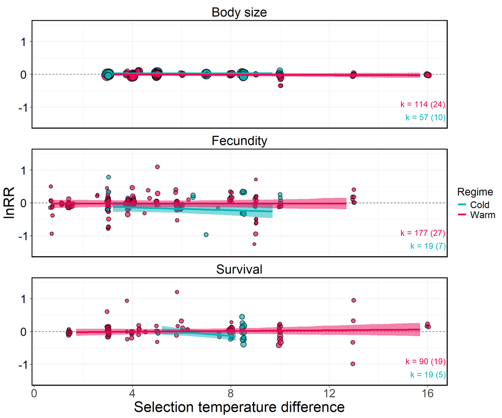

```r
# Generate predictions
emmeans_sel_temp_diff <- as.data.frame(emmeans(
  lnRR_model_sel_temp_diff,
  specs = ~ select_temp_diff | trait_type * warm_cold,
  at = list(select_temp_diff = seq(min(data$select_temp_diff), max(data$select_temp_diff), by = 0.5),
            assay_temp_diff = 0))
  ) # Conditional effects on assay_temp_diff = 0

# Calculate range of values for each category
range_df <- data %>%
  group_by(trait_type, warm_cold) %>%
  summarize(
    min_select_temp_diff = min(select_temp_diff),
    max_select_temp_diff = max(select_temp_diff)
  )

emmeans_sel_temp_diff$trait_type <- factor(emmeans_sel_temp_diff$trait_type,
                          levels = c("body_size", "fecundity", "survival"),
                          labels = c("Body size", "Fecundity", "Survival"))

emmeans_sel_temp_diff$warm_cold <- factor(emmeans_sel_temp_diff$warm_cold,
                          levels = c("cold", "warm"),
                          labels = c("Cold", "Warm"))

# Tailor predictions to the range of the data
emmeans_sel_temp_diff <- emmeans_sel_temp_diff %>%
  left_join(range_df, by = c("trait_type", "warm_cold")) %>%
  filter(
    select_temp_diff >= min_select_temp_diff,
    select_temp_diff <= max_select_temp_diff
  )

# Plot
ggplot() +
    geom_hline(yintercept = 0, # Horizontal line
               linetype = 2,
               colour = "black",
               alpha = 0.75) +
    geom_point(data = data,  # Effect sizes, scaled by precision
                  aes(x = select_temp_diff,
                      y = lnRR,
                      size = 1/sqrt(var_lnRR),
                      fill = warm_cold),
                  shape = 21,
                  alpha = 0.7,
                  stroke = 1,
                  position = position_jitter(width = 0.05)) +
     geom_ribbon(data = emmeans_sel_temp_diff, # Shaded area for credible intervals
                 aes(x = select_temp_diff,
                     ymin = lower.HPD,
                     ymax = upper.HPD,
                     fill = warm_cold,
                     group = warm_cold),
                 alpha = .5) +
     geom_line(data = emmeans_sel_temp_diff, # Predicted regression line
               aes(y = emmean,
                   x = select_temp_diff,
                   color = warm_cold,
                   group = warm_cold),
               size = 1.5) +
     geom_text(data = sample_sizes,
              aes(x = Inf,
                  y = ifelse(warm_cold == "Warm", -0.9, -1.3),  # Sample sizes
                  label = paste0("k = ", estimates, " (", studies, ")"),
                  color = warm_cold),
              hjust = 1.05, size = 5, show.legend = FALSE) +
  facet_wrap(~ trait_type, ncol = 1) +  # Different panels for each trait
  scale_fill_manual(values = c("#06B4BA", "#E80756"))+
  scale_color_manual(values = c("#06B4BA", "#E80756"))+
  labs(x = "Selection temperature difference", y = "lnRR", col = "Regime") +
  theme_bw() +
  scale_size_continuous(range = c(2, 8))+
  theme(text = element_text(size = 25, color = "black"),
          legend.title = ggplot2::element_text(size = 18),
          legend.text = ggplot2::element_text(size = 16),
          axis.text.y = ggplot2::element_text(size = 20,
                colour = "black", hjust = 0.5),
          axis.text.x = ggplot2::element_text(size = 20),
        panel.border = element_rect(color = "black", size = 1.5),
        strip.background = element_blank(),
        strip.text = element_text(color = "black", size = 22)) +
    guides(fill = "none", size = "none")+
    ylim(-1.5, 1.5)
```

```r
ggsave(file = "fig/lnRR_sel_temp_diff.png", width = 12, height = 7, dpi = 500)
```

### **Number of generations of selection**

#### *Model specification*

```r
# Model specification
formula <- bf(lnRR ~ 0 + trait_type:warm_cold +
                         trait_type:warm_cold:assay_temp_diff +
                         trait_type:warm_cold:scale(gen_selection) + # Separate effects by trait type
                (trait_type-1|ref) + # Correlation between traits among studies
                (1|species) + # Species-level random effect
                (1|gr(phylogeny, cov = phylo_matrix)) + # Phylogenetic relatedness
                (1|experiment_ID) + # Experiment-level random effect
                (1|obs) + # Observation-level random effect
                fcor(VCV_lnRR)) # Variance covariance matix of correlated sampling variances

# Define priors
prior = c(
  prior(constant(1), class = "sigma")
) # Because the residual variance-covariance structure is specified in fcor, there is no need to estimate sigma so it is left as a constant

# Fit model
lnRR_model_gen_selection <- brm(formula,
                                family = gaussian(),
                                data = data,
                                data2 = list(phylo_matrix = phylo_matrix,
                                             VCV_lnRR = VCV_lnRR),
                                prior = prior,
                                control = list(adapt_delta = 0.99, max_treedepth = 15),
                                iter = 4000,
                                warmup = 2000,
                                chains = 4,
                                cores = 4,
                                seed = 123)
# Save model
saveRDS(lnRR_model_gen_selection, file = "RData/lnRR_model_gen_selection.rds")
```

#### *Model output*

```r
# Load model
lnRR_model_gen_selection <- readRDS("RData/lnRR_model_gen_selection.rds")

# Display model output
summary(lnRR_model_gen_selection)
```

```
##  Family: gaussian
##   Links: mu = identity; sigma = identity
## Formula: lnRR ~ 0 + trait_type:warm_cold + trait_type:warm_cold:assay_temp_diff + trait_type:warm_cold:scale(gen_selection) + (trait_type - 1 | ref) + (1 | species) + (1 | gr(phylogeny, cov = phylo_matrix)) + (1 | experiment_ID) + (1 | obs) + fcor(VCV_lnRR)
##    Data: data (Number of observations: 476)
##   Draws: 4 chains, each with iter = 4000; warmup = 2000; thin = 1;
##          total post-warmup draws = 8000
##
## Multilevel Hyperparameters:
## ~experiment_ID (Number of levels: 88)
##               Estimate Est.Error l-95% CI u-95% CI Rhat Bulk_ESS Tail_ESS
## sd(Intercept)     0.02      0.01     0.00     0.04 1.01      617      776
##
## ~obs (Number of levels: 476)
##               Estimate Est.Error l-95% CI u-95% CI Rhat Bulk_ESS Tail_ESS
## sd(Intercept)     0.05      0.00     0.04     0.06 1.00     1605     2480
##
## ~phylogeny (Number of levels: 25)
##               Estimate Est.Error l-95% CI u-95% CI Rhat Bulk_ESS Tail_ESS
## sd(Intercept)     0.03      0.02     0.00     0.07 1.00     2219     3539
##
## ~ref (Number of levels: 44)
##                                              Estimate Est.Error l-95% CI
## sd(trait_typebody_size)                          0.01      0.01     0.00
## sd(trait_typefecundity)                          0.21      0.04     0.15
## sd(trait_typesurvival)                           0.13      0.03     0.08
## cor(trait_typebody_size,trait_typefecundity)    -0.09      0.46    -0.87
## cor(trait_typebody_size,trait_typesurvival)      0.01      0.50    -0.89
## cor(trait_typefecundity,trait_typesurvival)      0.21      0.45    -0.73
##                                              u-95% CI Rhat Bulk_ESS Tail_ESS
## sd(trait_typebody_size)                          0.03 1.00     1513     2634
## sd(trait_typefecundity)                          0.30 1.00     3039     5427
## sd(trait_typesurvival)                           0.20 1.00     3835     5162
## cor(trait_typebody_size,trait_typefecundity)     0.81 1.01      443      913
## cor(trait_typebody_size,trait_typesurvival)      0.87 1.00      740     1751
## cor(trait_typefecundity,trait_typesurvival)      0.88 1.00     1349     2888
##
## ~species (Number of levels: 25)
##               Estimate Est.Error l-95% CI u-95% CI Rhat Bulk_ESS Tail_ESS
## sd(Intercept)     0.02      0.01     0.00     0.04 1.00     1886     3491
##
```

[output cut: 51 more lines]

```
## trait_typesurvival:warm_coldwarm:assay_temp_diff         5423     5804
## trait_typebody_size:warm_coldcold:scalegen_selection     2243     3575
## trait_typefecundity:warm_coldcold:scalegen_selection     4317     4963
## trait_typesurvival:warm_coldcold:scalegen_selection      2591     4399
## trait_typebody_size:warm_coldwarm:scalegen_selection     3682     4568
## trait_typefecundity:warm_coldwarm:scalegen_selection     4275     5172
## trait_typesurvival:warm_coldwarm:scalegen_selection      4296     5586
##
## Further Distributional Parameters:
##       Estimate Est.Error l-95% CI u-95% CI Rhat Bulk_ESS Tail_ESS
## sigma     1.00      0.00     1.00     1.00   NA       NA       NA
##
## Draws were sampled using sampling(NUTS). For each parameter, Bulk_ESS
## and Tail_ESS are effective sample size measures, and Rhat is the potential
## scale reduction factor on split chains (at convergence, Rhat = 1).
```

```r
# R2
r2(lnRR_model_gen_selection)
```

```
## # Bayesian R2 with Compatibility Interval
##
##   Conditional R2: 0.284 (95% CI [0.236, 0.336])
##      Marginal R2: 0.091 (95% CI [0.059, 0.134])
```

```r
# Cleaned model output
as.data.frame(fixef(lnRR_model_gen_selection, summary = TRUE)) %>%
  # Rename categorical variables for cleaner display
  rownames_to_column(var = "Parameter") %>%
  mutate(
    # Simplify `trait_type` and `warm_cold` interactions
    Parameter = gsub("trait_type([a-z_]+):warm_cold(cold|warm)", "\\1(\\2)", Parameter),
    # Adjust for assay_temp_diff
    Parameter = gsub("trait_type([a-z_]+)\\((cold|warm)\\):assay_temp_diff", "\\1(\\2): assay_temp_diff", Parameter),
    # Remove "scale" from gen_selection
    Parameter = gsub("scalegen_selection", "gen_selection", Parameter)
  ) %>%
  # Round numbers to 3 decimal points
  mutate(across(c(Estimate, Q2.5, Q97.5), ~ round(., 3))) %>%
  select(Parameter, Estimate, `Lower CI` = Q2.5, `Upper CI` = Q97.5) %>%
  kable() %>%
  kable_styling(full_width = FALSE, position = "center", fixed_thead = TRUE) %>%
  column_spec(1, bold = TRUE, border_right = TRUE) %>%
  row_spec(0, background = "white", color = "black", bold = TRUE) %>%
  kable_styling(fixed_thead = TRUE)
```

| Parameter | Estimate | Lower CI | Upper CI |
| --- | --- | --- | --- |
| body_size(cold) | 0.015 | -0.031 | 0.061 |
| fecundity(cold) | -0.012 | -0.199 | 0.174 |
| survival(cold) | -0.067 | -0.220 | 0.087 |
| body_size(warm) | -0.005 | -0.051 | 0.037 |
| fecundity(warm) | -0.040 | -0.134 | 0.053 |
| survival(warm) | -0.028 | -0.121 | 0.062 |
| body_size(cold):assay_temp_diff | 0.001 | -0.003 | 0.006 |
| fecundity(cold):assay_temp_diff | -0.063 | -0.073 | -0.052 |
| survival(cold):assay_temp_diff | -0.045 | -0.055 | -0.035 |
| body_size(warm):assay_temp_diff | -0.001 | -0.004 | 0.003 |
| fecundity(warm):assay_temp_diff | 0.003 | -0.004 | 0.011 |
| survival(warm):assay_temp_diff | 0.004 | -0.002 | 0.011 |
| body_size(cold):gen_selection | 0.005 | -0.012 | 0.023 |
| fecundity(cold):gen_selection | -0.163 | -0.283 | -0.050 |
| survival(cold):gen_selection | -0.048 | -0.146 | 0.051 |
| body_size(warm):gen_selection | 0.001 | -0.010 | 0.011 |
| fecundity(warm):gen_selection | -0.014 | -0.112 | 0.084 |
| survival(warm):gen_selection | -0.090 | -0.233 | 0.045 |

#### *Data visualisation*

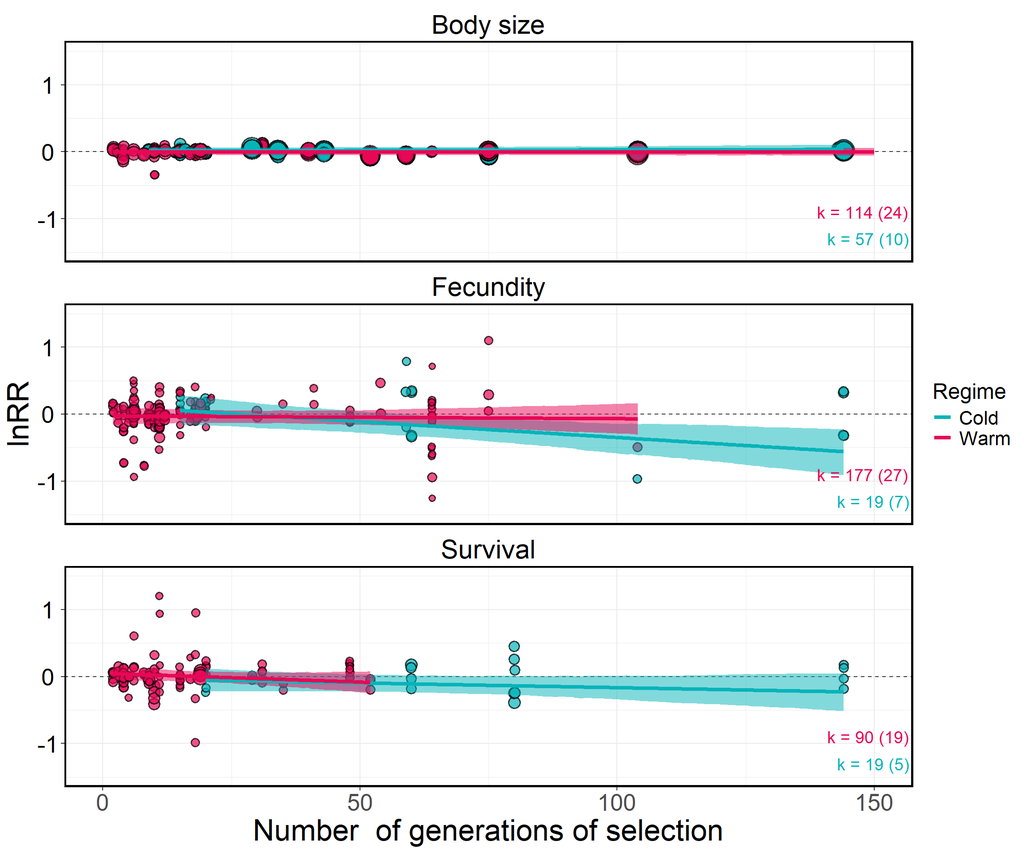

```r
# Generate predictions
emmeans_gen_selection <- as.data.frame(emmeans(
  lnRR_model_gen_selection,
  specs = ~ gen_selection | trait_type * warm_cold,
  at = list(gen_selection = seq(min(data$gen_selection), max(data$gen_selection), by = 0.5),
            assay_temp_diff = 0))
  ) # Conditional effects on assay_temp_diff = 0

# Calculate range of values for each category
range_df <- data %>%
  group_by(trait_type, warm_cold) %>%
  summarize(
    min_gen_selection = min(gen_selection),
    max_gen_selection = max(gen_selection)
  )

emmeans_gen_selection$trait_type <- factor(emmeans_gen_selection$trait_type,
                          levels = c("body_size", "fecundity", "survival"),
                          labels = c("Body size", "Fecundity", "Survival"))

emmeans_gen_selection$warm_cold <- factor(emmeans_gen_selection$warm_cold,
                          levels = c("cold", "warm"),
                          labels = c("Cold", "Warm"))

# Tailor predictions to the range of the data
emmeans_gen_selection <- emmeans_gen_selection %>%
  left_join(range_df, by = c("trait_type", "warm_cold")) %>%
  filter(
    gen_selection >= min_gen_selection,
    gen_selection <= max_gen_selection
  )

# Plot
ggplot() +
    geom_hline(yintercept = 0, # Horizontal line
               linetype = 2,
               colour = "black",
               alpha = 0.75) +
    geom_point(data = data,  # Effect sizes, scaled by precision
                  aes(x = gen_selection,
                      y = lnRR,
                      size = 1/sqrt(var_lnRR),
                      fill = warm_cold),
                  shape = 21,
                  alpha = 0.7,
                  stroke = 1,
                  position = position_jitter(width = 0.05)) +
     geom_ribbon(data = emmeans_gen_selection, # Shaded area for credible intervals
                 aes(x = gen_selection,
                     ymin = lower.HPD,
                     ymax = upper.HPD,
                     fill = warm_cold,
                     group = warm_cold),
                 alpha = .5) +
     geom_line(data = emmeans_gen_selection, # Predicted regression line
               aes(y = emmean,
                   x = gen_selection,
                   color = warm_cold,
                   group = warm_cold),
               size = 1.5) +
     geom_text(data = sample_sizes,
              aes(x = Inf,
                  y = ifelse(warm_cold == "Warm", -0.9, -1.3),  # Sample sizes
                  label = paste0("k = ", estimates, " (", studies, ")"),
                  color = warm_cold),
              hjust = 1.05, size = 5, show.legend = FALSE) +
  facet_wrap(~ trait_type, ncol = 1) +  # Different panels for each trait
  scale_fill_manual(values = c("#06B4BA", "#E80756"))+
  scale_color_manual(values = c("#06B4BA", "#E80756"))+
  labs(x = "Number  of generations of selection", y = "lnRR", col = "Regime") +
  theme_bw() +
  scale_size_continuous(range = c(2, 8))+
  theme(text = element_text(size = 25, color = "black"),
          legend.title = ggplot2::element_text(size = 18),
          legend.text = ggplot2::element_text(size = 16),
          axis.text.y = ggplot2::element_text(size = 20,
                colour = "black", hjust = 0.5),
          axis.text.x = ggplot2::element_text(size = 20),
        panel.border = element_rect(color = "black", size = 1.5),
        strip.background = element_blank(),
        strip.text = element_text(color = "black", size = 22)) +
    guides(fill = "none", size = "none")+
    ylim(-1.5, 1.5)+
    xlim(0, 150)
```

```r
ggsave(file = "fig/lnRR_gen_selection.png", width = 12, height = 7, dpi = 500)
```

### **Number of generations of common garden**

#### *Model specification*

```r
# Model specification
formula <- bf(lnRR ~ 0 + trait_type:warm_cold +
                         trait_type:warm_cold:assay_temp_diff +
                         trait_type:warm_cold:scale(gen_common_garden) + # Separate effects by trait type
                (trait_type-1|ref) + # Correlation between traits among studies
                (1|species) + # Species-level random effect
                (1|gr(phylogeny, cov = phylo_matrix)) + # Phylogenetic relatedness
                (1|experiment_ID) + # Experiment-level random effect
                (1|obs) + # Observation-level random effect
                fcor(VCV_lnRR)) # Variance covariance matix of correlated sampling variances

# Define priors
prior = c(
  prior(constant(1), class = "sigma")
) # Because the residual variance-covariance structure is specified in fcor, there is no need to estimate sigma so it is left as a constant

# Fit model
lnRR_model_gen_common_garden <- brm(formula,
                                family = gaussian(),
                                data = data,
                                data2 = list(phylo_matrix = phylo_matrix,
                                             VCV_lnRR = VCV_lnRR),
                                prior = prior,
                                control = list(adapt_delta = 0.99, max_treedepth = 15),
                                iter = 4000,
                                warmup = 2000,
                                chains = 4,
                                cores = 4,
                                seed = 123)
# Save model
saveRDS(lnRR_model_gen_common_garden, file = "RData/lnRR_model_gen_common_garden.rds")
```

#### *Model output*

```r
# Load model
lnRR_model_gen_common_garden <- readRDS("RData/lnRR_model_gen_common_garden.rds")

# Display model output
summary(lnRR_model_gen_common_garden)
```

```
##  Family: gaussian
##   Links: mu = identity; sigma = identity
## Formula: lnRR ~ 0 + trait_type:warm_cold + trait_type:warm_cold:assay_temp_diff + trait_type:warm_cold:scale(gen_common_garden) + (trait_type - 1 | ref) + (1 | species) + (1 | gr(phylogeny, cov = phylo_matrix)) + (1 | experiment_ID) + (1 | obs) + fcor(VCV_lnRR)
##    Data: data (Number of observations: 476)
##   Draws: 4 chains, each with iter = 4000; warmup = 2000; thin = 1;
##          total post-warmup draws = 8000
##
## Multilevel Hyperparameters:
## ~experiment_ID (Number of levels: 88)
##               Estimate Est.Error l-95% CI u-95% CI Rhat Bulk_ESS Tail_ESS
## sd(Intercept)     0.02      0.01     0.00     0.04 1.01      733      688
##
## ~obs (Number of levels: 476)
##               Estimate Est.Error l-95% CI u-95% CI Rhat Bulk_ESS Tail_ESS
## sd(Intercept)     0.05      0.00     0.04     0.06 1.00     1435     3238
##
## ~phylogeny (Number of levels: 25)
##               Estimate Est.Error l-95% CI u-95% CI Rhat Bulk_ESS Tail_ESS
## sd(Intercept)     0.03      0.02     0.00     0.07 1.00     2223     3481
##
## ~ref (Number of levels: 44)
##                                              Estimate Est.Error l-95% CI
## sd(trait_typebody_size)                          0.01      0.01     0.00
## sd(trait_typefecundity)                          0.20      0.03     0.14
## sd(trait_typesurvival)                           0.50      0.21     0.14
## cor(trait_typebody_size,trait_typefecundity)    -0.14      0.44    -0.89
## cor(trait_typebody_size,trait_typesurvival)      0.10      0.48    -0.83
## cor(trait_typefecundity,trait_typesurvival)     -0.48      0.34    -0.92
##                                              u-95% CI Rhat Bulk_ESS Tail_ESS
## sd(trait_typebody_size)                          0.03 1.00     1642     3193
## sd(trait_typefecundity)                          0.28 1.00     3616     5629
## sd(trait_typesurvival)                           0.95 1.01      578      988
## cor(trait_typebody_size,trait_typefecundity)     0.78 1.01      438      782
## cor(trait_typebody_size,trait_typesurvival)      0.89 1.01      579     1488
## cor(trait_typefecundity,trait_typesurvival)      0.33 1.00     1661     3238
##
## ~species (Number of levels: 25)
##               Estimate Est.Error l-95% CI u-95% CI Rhat Bulk_ESS Tail_ESS
## sd(Intercept)     0.02      0.01     0.00     0.04 1.00     2154     3219
##
```

[output cut: 51 more lines]

```
## trait_typesurvival:warm_coldwarm:assay_temp_diff             4614     5578
## trait_typebody_size:warm_coldcold:scalegen_common_garden     3148     4107
## trait_typefecundity:warm_coldcold:scalegen_common_garden     7731     5761
## trait_typesurvival:warm_coldcold:scalegen_common_garden       655     1522
## trait_typebody_size:warm_coldwarm:scalegen_common_garden     2303     3862
## trait_typefecundity:warm_coldwarm:scalegen_common_garden     5577     4857
## trait_typesurvival:warm_coldwarm:scalegen_common_garden       628     1296
##
## Further Distributional Parameters:
##       Estimate Est.Error l-95% CI u-95% CI Rhat Bulk_ESS Tail_ESS
## sigma     1.00      0.00     1.00     1.00   NA       NA       NA
##
## Draws were sampled using sampling(NUTS). For each parameter, Bulk_ESS
## and Tail_ESS are effective sample size measures, and Rhat is the potential
## scale reduction factor on split chains (at convergence, Rhat = 1).
```

```r
# R2
r2(lnRR_model_gen_common_garden)
```

```
## # Bayesian R2 with Compatibility Interval
##
##   Conditional R2: 0.307 (95% CI [0.254, 0.357])
##      Marginal R2: 0.279 (95% CI [0.106, 0.385])
```

```r
# Cleaned model output
as.data.frame(fixef(lnRR_model_gen_common_garden, summary = TRUE)) %>%
  # Rename categorical variables for cleaner display
  rownames_to_column(var = "Parameter") %>%
  mutate(
    # Simplify `trait_type` and `warm_cold` interactions
    Parameter = gsub("trait_type([a-z_]+):warm_cold(cold|warm)", "\\1(\\2)", Parameter),
    # Adjust for assay_temp_diff
    Parameter = gsub("trait_type([a-z_]+)\\((cold|warm)\\):assay_temp_diff", "\\1(\\2): assay_temp_diff", Parameter),
    # Remove "scale" from gen_common_garden
    Parameter = gsub("scalegen_common_garden", "gen_common_garden", Parameter)
  ) %>%
  # Round numbers to 3 decimal points
  mutate(across(c(Estimate, Q2.5, Q97.5), ~ round(., 3))) %>%
  select(Parameter, Estimate, `Lower CI` = Q2.5, `Upper CI` = Q97.5) %>%
  kable() %>%
  kable_styling(full_width = FALSE, position = "center", fixed_thead = TRUE) %>%
  column_spec(1, bold = TRUE, border_right = TRUE) %>%
  row_spec(0, background = "white", color = "black", bold = TRUE) %>%
  kable_styling(fixed_thead = TRUE)
```

| Parameter | Estimate | Lower CI | Upper CI |
| --- | --- | --- | --- |
| body_size(cold) | 0.016 | -0.030 | 0.061 |
| fecundity(cold) | -0.170 | -0.295 | -0.048 |
| survival(cold) | 0.125 | -0.107 | 0.416 |
| body_size(warm) | -0.003 | -0.049 | 0.039 |
| fecundity(warm) | -0.043 | -0.133 | 0.047 |
| survival(warm) | 0.097 | -0.118 | 0.354 |
| body_size(cold):assay_temp_diff | 0.001 | -0.003 | 0.006 |
| fecundity(cold):assay_temp_diff | -0.062 | -0.073 | -0.052 |
| survival(cold):assay_temp_diff | -0.045 | -0.055 | -0.036 |
| body_size(warm):assay_temp_diff | 0.000 | -0.004 | 0.003 |
| fecundity(warm):assay_temp_diff | 0.004 | -0.003 | 0.012 |
| survival(warm):assay_temp_diff | 0.002 | -0.005 | 0.010 |
| body_size(cold):gen_common_garden | -0.042 | -0.150 | 0.073 |
| fecundity(cold):gen_common_garden | 0.357 | -0.118 | 0.839 |
| survival(cold):gen_common_garden | 1.836 | 0.292 | 3.301 |
| body_size(warm):gen_common_garden | 0.031 | -0.060 | 0.128 |
| fecundity(warm):gen_common_garden | 0.018 | -0.011 | 0.046 |
| survival(warm):gen_common_garden | 2.069 | 0.558 | 3.455 |

#### *Data visualisation*

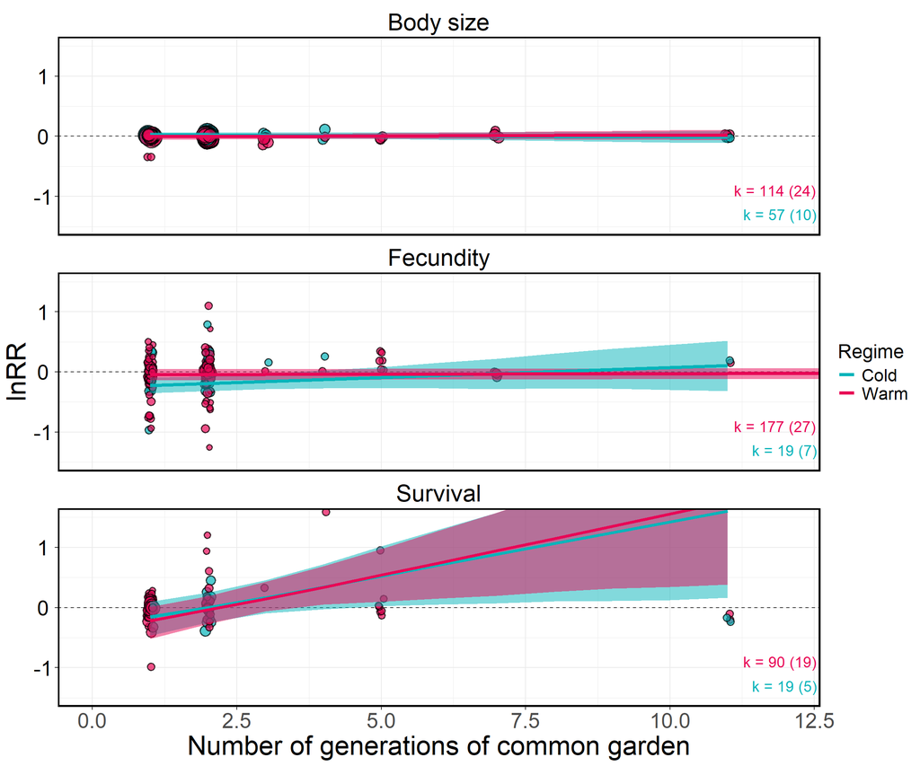

```r
# Generate predictions
emmeans_gen_common_garden <- as.data.frame(emmeans(
  lnRR_model_gen_common_garden,
  specs = ~ gen_common_garden | trait_type * warm_cold,
  at = list(gen_common_garden = seq(min(data$gen_common_garden), max(data$gen_common_garden), by = 1),
            assay_temp_diff = 0))
  ) # Conditional effects on assay_temp_diff = 0


# Calculate range of values for each category
range_df <- data %>%
  group_by(trait_type, warm_cold) %>%
  summarize(
    min_gen_common_garden = min(gen_common_garden),
    max_gen_common_garden = max(gen_common_garden)
  )

emmeans_gen_common_garden$trait_type <- factor(emmeans_gen_common_garden$trait_type,
                          levels = c("body_size", "fecundity", "survival"),
                          labels = c("Body size", "Fecundity", "Survival"))

emmeans_gen_common_garden$warm_cold <- factor(emmeans_gen_common_garden$warm_cold,
                          levels = c("cold", "warm"),
                          labels = c("Cold", "Warm"))

# Tailor predictions to the range of the data
emmeans_gen_common_garden <- emmeans_gen_common_garden %>%
  left_join(range_df, by = c("trait_type", "warm_cold")) %>%
  filter(
    gen_common_garden >= min_gen_common_garden,
    gen_common_garden <= max_gen_common_garden
  )

# Plot
ggplot() +
    geom_hline(yintercept = 0, # Horizontal line
               linetype = 2,
               colour = "black",
               alpha = 0.75) +
    geom_point(data = data,  # Effect sizes, scaled by precision
                  aes(x = gen_common_garden,
                      y = lnRR,
                      size = 1/sqrt(var_lnRR),
                      fill = warm_cold),
                  shape = 21,
                  alpha = 0.7,
                  stroke = 1,
                  position = position_jitter(width = 0.05)) +
     geom_ribbon(data = emmeans_gen_common_garden, # Shaded area for credible intervals
                 aes(x = gen_common_garden,
                     ymin = lower.HPD,
                     ymax = upper.HPD,
                     fill = warm_cold,
                     group = warm_cold),
                 alpha = .5) +
     geom_line(data = emmeans_gen_common_garden, # Predicted regression line
               aes(y = emmean,
                   x = gen_common_garden,
                   color = warm_cold,
                   group = warm_cold),
               size = 1.5) +
     geom_text(data = sample_sizes,
              aes(x = Inf,
                  y = ifelse(warm_cold == "Warm", -0.9, -1.3),  # Sample sizes
                  label = paste0("k = ", estimates, " (", studies, ")"),
                  color = warm_cold),
              hjust = 1.05, size = 5, show.legend = FALSE) +
  facet_wrap(~ trait_type, ncol = 1) +  # Different panels for each trait
  scale_fill_manual(values = c("#06B4BA", "#E80756"))+
  scale_color_manual(values = c("#06B4BA", "#E80756"))+
  labs(x = "Number of generations of common garden", y = "lnRR", col = "Regime") +
  theme_bw() +
  scale_size_continuous(range = c(2, 8))+
  theme(text = element_text(size = 25, color = "black"),
          legend.title = ggplot2::element_text(size = 18),
          legend.text = ggplot2::element_text(size = 16),
          axis.text.y = ggplot2::element_text(size = 20,
                colour = "black", hjust = 0.5),
          axis.text.x = ggplot2::element_text(size = 20),
        panel.border = element_rect(color = "black", size = 1.5),
        strip.background = element_blank(),
        strip.text = element_text(color = "black", size = 22)) +
    guides(fill = "none", size = "none")+
    coord_cartesian(ylim = c(-1.5, 1.5),
                    xlim = c(0, 12))
```

```r
ggsave(file = "fig/lnRR_gen_common_garden.png", width = 12, height = 7, dpi = 500)
```

### **Population size**

#### *Model specification*

```r
# Model specification
formula <- bf(lnRR ~ 0 + trait_type:warm_cold +
                         trait_type:warm_cold:assay_temp_diff +
                         trait_type:warm_cold:scale(pop_size) + # Separate effects by trait type
                (trait_type-1|ref) + # Correlation between traits among studies
                (1|species) + # Species-level random effect
                (1|gr(phylogeny, cov = phylo_matrix)) + # Phylogenetic relatedness
                (1|experiment_ID) + # Experiment-level random effect
                (1|obs) + # Observation-level random effect
                fcor(VCV_lnRR)) # Variance covariance matix of correlated sampling variances

# Define priors
prior = c(
  prior(constant(1), class = "sigma")
) # Because the residual variance-covariance structure is specified in fcor, there is no need to estimate sigma so it is left as a constant

# Fit model
lnRR_model_pop_size <- brm(formula,
                                family = gaussian(),
                                data = data,
                                data2 = list(phylo_matrix = phylo_matrix,
                                             VCV_lnRR = VCV_lnRR),
                                prior = prior,
                                control = list(adapt_delta = 0.99, max_treedepth = 15),
                                iter = 4000,
                                warmup = 2000,
                                chains = 4,
                                cores = 4,
                                seed = 123)
# Save model
saveRDS(lnRR_model_pop_size, file = "RData/lnRR_model_pop_size.rds")
```

#### *Model output*

```r
# Load model
lnRR_model_pop_size <- readRDS("RData/lnRR_model_pop_size.rds")

# Display model output
summary(lnRR_model_pop_size)
```

```
##  Family: gaussian
##   Links: mu = identity; sigma = identity
## Formula: lnRR ~ 0 + trait_type:warm_cold + trait_type:warm_cold:assay_temp_diff + trait_type:warm_cold:scale(pop_size) + (trait_type - 1 | ref) + (1 | species) + (1 | gr(phylogeny, cov = phylo_matrix)) + (1 | experiment_ID) + (1 | obs) + fcor(VCV_lnRR)
##    Data: data (Number of observations: 426)
##   Draws: 4 chains, each with iter = 4000; warmup = 2000; thin = 1;
##          total post-warmup draws = 8000
##
## Multilevel Hyperparameters:
## ~experiment_ID (Number of levels: 79)
##               Estimate Est.Error l-95% CI u-95% CI Rhat Bulk_ESS Tail_ESS
## sd(Intercept)     0.01      0.01     0.00     0.03 1.00      743     1669
##
## ~obs (Number of levels: 426)
##               Estimate Est.Error l-95% CI u-95% CI Rhat Bulk_ESS Tail_ESS
## sd(Intercept)     0.05      0.00     0.04     0.05 1.00     1926     3742
##
## ~phylogeny (Number of levels: 22)
##               Estimate Est.Error l-95% CI u-95% CI Rhat Bulk_ESS Tail_ESS
## sd(Intercept)     0.03      0.02     0.00     0.07 1.00     2664     3599
##
## ~ref (Number of levels: 41)
##                                              Estimate Est.Error l-95% CI
## sd(trait_typebody_size)                          0.01      0.01     0.00
## sd(trait_typefecundity)                          0.23      0.04     0.16
## sd(trait_typesurvival)                           0.13      0.03     0.08
## cor(trait_typebody_size,trait_typefecundity)    -0.07      0.46    -0.88
## cor(trait_typebody_size,trait_typesurvival)      0.18      0.49    -0.81
## cor(trait_typefecundity,trait_typesurvival)      0.02      0.48    -0.83
##                                              u-95% CI Rhat Bulk_ESS Tail_ESS
## sd(trait_typebody_size)                          0.03 1.00     1496     3181
## sd(trait_typefecundity)                          0.33 1.00     2900     5491
## sd(trait_typesurvival)                           0.21 1.00     3678     4857
## cor(trait_typebody_size,trait_typefecundity)     0.83 1.01      381      878
## cor(trait_typebody_size,trait_typesurvival)      0.92 1.01      904     1910
## cor(trait_typefecundity,trait_typesurvival)      0.85 1.00     1220     2830
##
## ~species (Number of levels: 22)
##               Estimate Est.Error l-95% CI u-95% CI Rhat Bulk_ESS Tail_ESS
## sd(Intercept)     0.02      0.01     0.00     0.04 1.00     2638     3700
##
```

[output cut: 51 more lines]

```
## trait_typesurvival:warm_coldwarm:assay_temp_diff      6159
## trait_typebody_size:warm_coldcold:scalepop_size       3983
## trait_typefecundity:warm_coldcold:scalepop_size       4860
## trait_typesurvival:warm_coldcold:scalepop_size        4835
## trait_typebody_size:warm_coldwarm:scalepop_size       3997
## trait_typefecundity:warm_coldwarm:scalepop_size       4570
## trait_typesurvival:warm_coldwarm:scalepop_size        4389
##
## Further Distributional Parameters:
##       Estimate Est.Error l-95% CI u-95% CI Rhat Bulk_ESS Tail_ESS
## sigma     1.00      0.00     1.00     1.00   NA       NA       NA
##
## Draws were sampled using sampling(NUTS). For each parameter, Bulk_ESS
## and Tail_ESS are effective sample size measures, and Rhat is the potential
## scale reduction factor on split chains (at convergence, Rhat = 1).
```

```r
# R2
r2(lnRR_model_pop_size)
```

```
## # Bayesian R2 with Compatibility Interval
##
##   Conditional R2: 0.300 (95% CI [0.245, 0.353])
##      Marginal R2: 0.095 (95% CI [0.065, 0.135])
```

```r
# Cleaned model output
as.data.frame(fixef(lnRR_model_pop_size, summary = TRUE)) %>%
  # Rename categorical variables for cleaner display
  rownames_to_column(var = "Parameter") %>%
  mutate(
    # Simplify `trait_type` and `warm_cold` interactions
    Parameter = gsub("trait_type([a-z_]+):warm_cold(cold|warm)", "\\1(\\2)", Parameter),
    # Adjust for assay_temp_diff
    Parameter = gsub("trait_type([a-z_]+)\\((cold|warm)\\):assay_temp_diff", "\\1(\\2): assay_temp_diff", Parameter),
    # Remove "scale" from pop_size
    Parameter = gsub("scalepop_size", "pop_size", Parameter)
  ) %>%
  # Round numbers to 3 decimal points
  mutate(across(c(Estimate, Q2.5, Q97.5), ~ round(., 3))) %>%
  select(Parameter, Estimate, `Lower CI` = Q2.5, `Upper CI` = Q97.5) %>%
  kable() %>%
  kable_styling(full_width = FALSE, position = "center", fixed_thead = TRUE) %>%
  column_spec(1, bold = TRUE, border_right = TRUE) %>%
  row_spec(0, background = "white", color = "black", bold = TRUE) %>%
  kable_styling(fixed_thead = TRUE)
```

| Parameter | Estimate | Lower CI | Upper CI |
| --- | --- | --- | --- |
| body_size(cold) | 0.015 | -0.032 | 0.062 |
| fecundity(cold) | -0.252 | -0.408 | -0.102 |
| survival(cold) | -0.125 | -0.254 | 0.007 |
| body_size(warm) | -0.001 | -0.046 | 0.041 |
| fecundity(warm) | -0.042 | -0.149 | 0.067 |
| survival(warm) | 0.006 | -0.072 | 0.087 |
| body_size(cold):assay_temp_diff | 0.001 | -0.004 | 0.005 |
| fecundity(cold):assay_temp_diff | -0.064 | -0.074 | -0.054 |
| survival(cold):assay_temp_diff | -0.046 | -0.055 | -0.037 |
| body_size(warm):assay_temp_diff | -0.001 | -0.004 | 0.002 |
| fecundity(warm):assay_temp_diff | 0.007 | -0.001 | 0.015 |
| survival(warm):assay_temp_diff | 0.004 | -0.002 | 0.010 |
| body_size(cold):pop_size | 0.000 | -0.019 | 0.019 |
| fecundity(cold):pop_size | 0.085 | -0.048 | 0.221 |
| survival(cold):pop_size | 0.119 | 0.004 | 0.244 |
| body_size(warm):pop_size | -0.007 | -0.021 | 0.008 |
| fecundity(warm):pop_size | -0.001 | -0.106 | 0.098 |
| survival(warm):pop_size | 0.025 | -0.042 | 0.093 |

#### *Data visualisation*

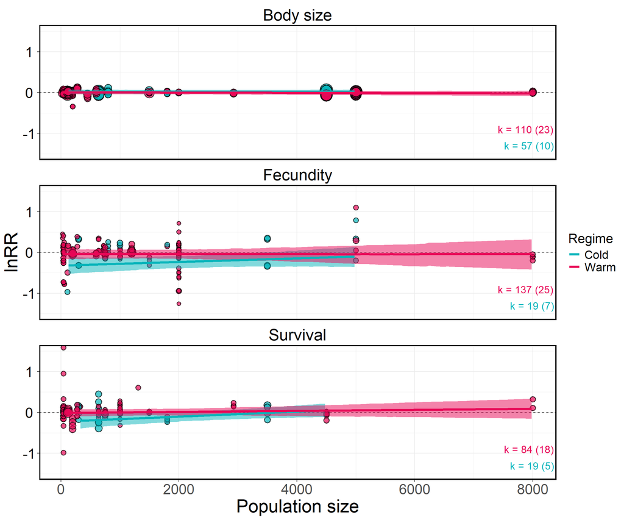

```r
# Generate predictions
emmeans_pop_size <- as.data.frame(emmeans(
  lnRR_model_pop_size,
  specs = ~ pop_size | trait_type * warm_cold,
  at = list(pop_size = seq(min(data$pop_size, na.rm=T), max(data$pop_size, na.rm=T), by = 50),
            assay_temp_diff = 0))
  ) # Conditional effects on assay_temp_diff = 0


# Calculate range of values for each category
range_df <- data %>%
  group_by(trait_type, warm_cold) %>%
  summarize(
    min_pop_size = min(pop_size, na.rm=T),
    max_pop_size = max(pop_size, na.rm=T)
  )

emmeans_pop_size$trait_type <- factor(emmeans_pop_size$trait_type,
                          levels = c("body_size", "fecundity", "survival"),
                          labels = c("Body size", "Fecundity", "Survival"))

emmeans_pop_size$warm_cold <- factor(emmeans_pop_size$warm_cold,
                          levels = c("cold", "warm"),
                          labels = c("Cold", "Warm"))

# Tailor predictions to the range of the data
emmeans_pop_size <- emmeans_pop_size %>%
  left_join(range_df, by = c("trait_type", "warm_cold")) %>%
  filter(
    pop_size >= min_pop_size,
    pop_size <= max_pop_size
  )

# Calculate sample sizes and study counts for population size
sample_sizes_pop_size <- data %>%
  filter(is.na(pop_size)==FALSE) %>%
  group_by(trait_type, warm_cold) %>%
  summarise(
    estimates = n(),
    studies = n_distinct(ref)
  )

# Plot
ggplot() +
    geom_hline(yintercept = 0, # Horizontal line
               linetype = 2,
               colour = "black",
               alpha = 0.75) +
    geom_point(data = data,  # Effect sizes, scaled by precision
                  aes(x = pop_size,
                      y = lnRR,
                      size = 1/sqrt(var_lnRR),
                      fill = warm_cold),
                  shape = 21,
                  alpha = 0.7,
                  stroke = 1,
                  position = position_jitter(width = 0.05)) +
     geom_ribbon(data = emmeans_pop_size, # Shaded area for credible intervals
                 aes(x = pop_size,
                     ymin = lower.HPD,
                     ymax = upper.HPD,
                     fill = warm_cold,
                     group = warm_cold),
                 alpha = .5) +
     geom_line(data = emmeans_pop_size, # Predicted regression line
               aes(y = emmean,
                   x = pop_size,
                   color = warm_cold,
                   group = warm_cold),
               size = 1.5) +
     geom_text(data = sample_sizes_pop_size,
              aes(x = Inf,
                  y = ifelse(warm_cold == "Warm", -0.9, -1.3),  # Sample sizes
                  label = paste0("k = ", estimates, " (", studies, ")"),
                  color = warm_cold),
              hjust = 1.05, size = 5, show.legend = FALSE) +
  facet_wrap(~ trait_type, ncol = 1) +  # Different panels for each trait
  scale_fill_manual(values = c("#06B4BA", "#E80756"))+
  scale_color_manual(values = c("#06B4BA", "#E80756"))+
  labs(x = "Population size", y = "lnRR", col = "Regime") +
  theme_bw() +
  scale_size_continuous(range = c(2, 8))+
  theme(text = element_text(size = 25, color = "black"),
          legend.title = ggplot2::element_text(size = 18),
          legend.text = ggplot2::element_text(size = 16),
          axis.text.y = ggplot2::element_text(size = 20,
                colour = "black", hjust = 0.5),
          axis.text.x = ggplot2::element_text(size = 20),
        panel.border = element_rect(color = "black", size = 1.5),
        strip.background = element_blank(),
        strip.text = element_text(color = "black", size = 22)) +
    guides(fill = "none", size = "none")+
    coord_cartesian(ylim = c(-1.5, 1.5))
```

```r
ggsave(file = "fig/lnRR_pop_size.png", width = 12, height = 7, dpi = 500)
```

### **All moderators**

#### *Model specification*

```r
# Model specification
formula <- bf(lnRR ~ 0 + trait_type:warm_cold +
                trait_type:warm_cold:assay_temp_diff +
                trait_type:warm_cold:scale(select_temp_diff) +
                trait_type:warm_cold:scale(gen_selection) +
                trait_type:warm_cold:scale(gen_common_garden) + # Separate effects by trait type
                (trait_type-1|ref) + # Correlation between traits among studies
                (1|species) + # Species-level random effect
                (1|gr(phylogeny, cov = phylo_matrix)) + # Phylogenetic relatedness
                (1|experiment_ID) + # Experiment-level random effect
                (1|obs) + # Observation-level random effect
                fcor(VCV_lnRR)) # Variance covariance matix of correlated sampling variances

# Define priors
prior = c(
  prior(constant(1), class = "sigma")
) # Because the residual variance-covariance structure is specified in fcor, there is no need to estimate sigma so it is left as a constant

# Fit model
lnRR_model_all_moderators <- brm(formula,
                                  family = gaussian(),
                                  data = data,
                                  data2 = list(phylo_matrix = phylo_matrix,
                                               VCV_lnRR = VCV_lnRR),
                                  prior = prior,
                                  control = list(adapt_delta = 0.99, max_treedepth = 15),
                                  iter = 4000,
                                  warmup = 2000,
                                  chains = 4,
                                  cores = 4,
                                  seed = 123)

# Save model
saveRDS(lnRR_model_all_moderators, file = "RData/lnRR_model_all_moderators.rds")
```

#### *Model output*

```r
# Load model
lnRR_model_all_moderators <- readRDS("RData/lnRR_model_all_moderators.rds")

# Display model output
summary(lnRR_model_all_moderators)
```

```
##  Family: gaussian
##   Links: mu = identity; sigma = identity
## Formula: lnRR ~ 0 + trait_type:warm_cold + trait_type:warm_cold:assay_temp_diff + trait_type:warm_cold:scale(select_temp_diff) + trait_type:warm_cold:scale(gen_selection) + trait_type:warm_cold:scale(gen_common_garden) + (trait_type - 1 | ref) + (1 | species) + (1 | gr(phylogeny, cov = phylo_matr…
##    Data: data (Number of observations: 476)
##   Draws: 4 chains, each with iter = 4000; warmup = 2000; thin = 1;
##          total post-warmup draws = 8000
##
## Multilevel Hyperparameters:
## ~experiment_ID (Number of levels: 88)
##               Estimate Est.Error l-95% CI u-95% CI Rhat Bulk_ESS Tail_ESS
## sd(Intercept)     0.02      0.01     0.00     0.04 1.00      748     1068
##
## ~obs (Number of levels: 476)
##               Estimate Est.Error l-95% CI u-95% CI Rhat Bulk_ESS Tail_ESS
## sd(Intercept)     0.05      0.00     0.04     0.06 1.00     1779     3050
##
## ~phylogeny (Number of levels: 25)
##               Estimate Est.Error l-95% CI u-95% CI Rhat Bulk_ESS Tail_ESS
## sd(Intercept)     0.03      0.02     0.00     0.07 1.00     2434     3885
##
## ~ref (Number of levels: 44)
##                                              Estimate Est.Error l-95% CI
## sd(trait_typebody_size)                          0.01      0.01     0.00
## sd(trait_typefecundity)                          0.21      0.04     0.14
## sd(trait_typesurvival)                           0.64      0.21     0.24
## cor(trait_typebody_size,trait_typefecundity)    -0.14      0.46    -0.89
## cor(trait_typebody_size,trait_typesurvival)      0.08      0.48    -0.83
## cor(trait_typefecundity,trait_typesurvival)     -0.40      0.34    -0.91
##                                              u-95% CI Rhat Bulk_ESS Tail_ESS
## sd(trait_typebody_size)                          0.03 1.00     1776     3327
## sd(trait_typefecundity)                          0.30 1.00     3633     5612
## sd(trait_typesurvival)                           1.10 1.00     1279     1252
## cor(trait_typebody_size,trait_typefecundity)     0.81 1.02      494     1049
## cor(trait_typebody_size,trait_typesurvival)      0.89 1.01      551     1374
## cor(trait_typefecundity,trait_typesurvival)      0.38 1.00     2284     3612
##
## ~species (Number of levels: 25)
##               Estimate Est.Error l-95% CI u-95% CI Rhat Bulk_ESS Tail_ESS
## sd(Intercept)     0.02      0.01     0.00     0.04 1.00     2569     4362
##
```

[output cut: 87 more lines]

```
## trait_typesurvival:warm_coldwarm:scalegen_selection          4011     4623
## trait_typebody_size:warm_coldcold:scalegen_common_garden     3429     4295
## trait_typefecundity:warm_coldcold:scalegen_common_garden     5690     5471
## trait_typesurvival:warm_coldcold:scalegen_common_garden      1730     2239
## trait_typebody_size:warm_coldwarm:scalegen_common_garden     3496     4478
## trait_typefecundity:warm_coldwarm:scalegen_common_garden     6349     5572
## trait_typesurvival:warm_coldwarm:scalegen_common_garden      1677     1288
##
## Further Distributional Parameters:
##       Estimate Est.Error l-95% CI u-95% CI Rhat Bulk_ESS Tail_ESS
## sigma     1.00      0.00     1.00     1.00   NA       NA       NA
##
## Draws were sampled using sampling(NUTS). For each parameter, Bulk_ESS
## and Tail_ESS are effective sample size measures, and Rhat is the potential
## scale reduction factor on split chains (at convergence, Rhat = 1).
```

```r
# R2
r2(lnRR_model_all_moderators)
```

```
## # Bayesian R2 with Compatibility Interval
##
##   Conditional R2: 0.318 (95% CI [0.265, 0.370])
##      Marginal R2: 0.344 (95% CI [0.201, 0.428])
```

```r
# Cleaned model output
as.data.frame(fixef(lnRR_model_all_moderators, summary = TRUE)) %>%
  # Rename categorical variables for cleaner display
  rownames_to_column(var = "Parameter") %>%
  mutate(
    # Simplify `trait_type` and `warm_cold` interactions
    Parameter = gsub("trait_type([a-z_]+):warm_cold(cold|warm)", "\\1(\\2)", Parameter),
    # Adjust for assay_temp_diff
    Parameter = gsub("trait_type([a-z_]+)\\((cold|warm)\\):assay_temp_diff", "\\1(\\2): assay_temp_diff", Parameter),
    # Remove "scale" from all moderator variables
    Parameter = gsub("scale", "", Parameter)
  ) %>%
  # Round numbers to 3 decimal points
  mutate(across(c(Estimate, Q2.5, Q97.5), ~ round(., 3))) %>%
  select(Parameter, Estimate, `Lower CI` = Q2.5, `Upper CI` = Q97.5) %>%
  kable() %>%
  kable_styling(full_width = FALSE, position = "center", fixed_thead = TRUE) %>%
  column_spec(1, bold = TRUE, border_right = TRUE) %>%
  row_spec(0, background = "white", color = "black", bold = TRUE) %>%
  kable_styling(fixed_thead = TRUE)
```

| Parameter | Estimate | Lower CI | Upper CI |
| --- | --- | --- | --- |
| body_size(cold) | 0.015 | -0.035 | 0.064 |
| fecundity(cold) | -0.045 | -0.235 | 0.150 |
| survival(cold) | -0.071 | -0.662 | 0.508 |
| body_size(warm) | -0.006 | -0.055 | 0.038 |
| fecundity(warm) | -0.042 | -0.142 | 0.060 |
| survival(warm) | 0.054 | -0.307 | 0.431 |
| body_size(cold):assay_temp_diff | 0.002 | -0.003 | 0.008 |
| fecundity(cold):assay_temp_diff | -0.063 | -0.073 | -0.052 |
| survival(cold):assay_temp_diff | -0.045 | -0.055 | -0.035 |
| body_size(warm):assay_temp_diff | 0.001 | -0.003 | 0.005 |
| fecundity(warm):assay_temp_diff | 0.004 | -0.003 | 0.012 |
| survival(warm):assay_temp_diff | 0.002 | -0.005 | 0.009 |
| body_size(cold):select_temp_diff | 0.005 | -0.027 | 0.039 |
| fecundity(cold):select_temp_diff | -0.032 | -0.190 | 0.120 |
| survival(cold):select_temp_diff | -0.289 | -1.893 | 1.267 |
| body_size(warm):select_temp_diff | -0.008 | -0.028 | 0.012 |
| fecundity(warm):select_temp_diff | 0.006 | -0.050 | 0.064 |
| survival(warm):select_temp_diff | 0.012 | -0.174 | 0.194 |
| body_size(cold):gen_selection | 0.001 | -0.021 | 0.021 |
| fecundity(cold):gen_selection | -0.144 | -0.287 | -0.009 |
| survival(cold):gen_selection | 0.300 | -0.480 | 1.174 |
| body_size(warm):gen_selection | 0.000 | -0.010 | 0.011 |
| fecundity(warm):gen_selection | -0.018 | -0.123 | 0.086 |
| survival(warm):gen_selection | -0.217 | -0.700 | 0.274 |
| body_size(cold):gen_common_garden | -0.052 | -0.169 | 0.071 |
| fecundity(cold):gen_common_garden | 0.110 | -0.468 | 0.690 |
| survival(cold):gen_common_garden | 2.891 | 0.690 | 5.460 |
| body_size(warm):gen_common_garden | 0.034 | -0.058 | 0.132 |
| fecundity(warm):gen_common_garden | 0.019 | -0.012 | 0.049 |
| survival(warm):gen_common_garden | 2.564 | 0.983 | 3.713 |

```r
# Generate predicted values at different assay temperatures
emmeans_full_model <- as.data.frame(emmeans(
  lnRR_model_all_moderators,
  specs = ~ assay_temp_diff * select_temp_diff * gen_selection * gen_common_garden | trait_type * warm_cold,
  at = list(assay_temp_diff = c(-8.5, -4, 0, 4, 5, -5, 17, 20)) # Predict at unique min, control, max values
))

# Calculate range of values for each category
range_df <- data %>%
  group_by(trait_type, warm_cold) %>%
  summarize(
    min_assay = min(assay_temp_diff),
    max_assay = max(assay_temp_diff),
    control_assay = 0
  )

emmeans_full_model$trait_type <- factor(emmeans_full_model$trait_type,
                          levels = c("body_size", "fecundity", "survival"),
                          labels = c("Body size", "Fecundity", "Survival"))

emmeans_full_model$warm_cold <- factor(emmeans_full_model$warm_cold,
                          levels = c("cold", "warm"),
                          labels = c("Cold", "Warm"))

# Tailor predictions to the range of the data
emmeans_full_model %>%
  left_join(range_df, by = c("trait_type", "warm_cold")) %>%
  filter(
    assay_temp_diff == min_assay |
    assay_temp_diff == max_assay |
    assay_temp_diff == control_assay) %>%
    dplyr::select(-min_assay, -max_assay, -control_assay) %>%
    mutate(percentage_change = (exp(emmean) - 1) * 100,
           percentage_lower_HPD = (exp(lower.HPD) - 1) * 100,
           percentage_upper_HPD = (exp(upper.HPD) - 1) * 100) %>%
  mutate(across(c(emmean,
                  lower.HPD,
                  upper.HPD,
                  percentage_change,
                  percentage_lower_HPD,
                  percentage_upper_HPD), ~ round(., 3))) %>%   # Round numbers to 3 decimal points
  kable() %>%
  kable_styling(full_width = FALSE, position = "center", fixed_thead = TRUE) %>%
  column_spec(1, bold = TRUE, border_right = TRUE) %>%
  row_spec(0, background = "white", color = "black", bold = TRUE) %>%
  kable_styling(fixed_thead = TRUE)
```

| assay_temp_diff | select_temp_diff | gen_selection | gen_common_garden | trait_type | warm_cold | emmean | lower.HPD | upper.HPD | percentage_change | percentage_lower_HPD | percentage_upper_HPD |
| --- | --- | --- | --- | --- | --- | --- | --- | --- | --- | --- | --- |
| -8.5 | 5.64645 | 29.0084 | 2.710084 | Body size | Cold | -0.002 | -0.068 | 0.063 | -0.174 | -6.570 | 6.513 |
| 0.0 | 5.64645 | 29.0084 | 2.710084 | Body size | Cold | 0.015 | -0.033 | 0.066 | 1.532 | -3.216 | 6.847 |
| 5.0 | 5.64645 | 29.0084 | 2.710084 | Body size | Cold | 0.026 | -0.028 | 0.083 | 2.583 | -2.791 | 8.605 |
| -8.5 | 5.64645 | 29.0084 | 2.710084 | Fecundity | Cold | 0.492 | 0.287 | 0.693 | 63.516 | 33.287 | 100.029 |
| 0.0 | 5.64645 | 29.0084 | 2.710084 | Fecundity | Cold | -0.045 | -0.235 | 0.150 | -4.374 | -20.917 | 16.194 |
| 5.0 | 5.64645 | 29.0084 | 2.710084 | Fecundity | Cold | -0.360 | -0.565 | -0.155 | -30.208 | -43.189 | -14.385 |
| -8.5 | 5.64645 | 29.0084 | 2.710084 | Survival | Cold | 0.315 | -0.258 | 0.919 | 36.989 | -22.732 | 150.565 |
| 0.0 | 5.64645 | 29.0084 | 2.710084 | Survival | Cold | -0.069 | -0.679 | 0.491 | -6.711 | -49.275 | 63.319 |
| 4.0 | 5.64645 | 29.0084 | 2.710084 | Survival | Cold | -0.250 | -0.870 | 0.298 | -22.093 | -58.093 | 34.776 |
| 0.0 | 5.64645 | 29.0084 | 2.710084 | Body size | Warm | -0.006 | -0.053 | 0.039 | -0.591 | -5.122 | 4.027 |
| -5.0 | 5.64645 | 29.0084 | 2.710084 | Body size | Warm | -0.010 | -0.062 | 0.047 | -1.006 | -5.979 | 4.817 |
| 17.0 | 5.64645 | 29.0084 | 2.710084 | Body size | Warm | 0.007 | -0.063 | 0.077 | 0.753 | -6.076 | 8.004 |
| -4.0 | 5.64645 | 29.0084 | 2.710084 | Fecundity | Warm | -0.059 | -0.170 | 0.052 | -5.715 | -15.648 | 5.345 |
| 0.0 | 5.64645 | 29.0084 | 2.710084 | Fecundity | Warm | -0.043 | -0.145 | 0.056 | -4.167 | -13.472 | 5.761 |
| 20.0 | 5.64645 | 29.0084 | 2.710084 | Fecundity | Warm | 0.039 | -0.119 | 0.197 | 4.023 | -11.244 | 21.776 |
| 0.0 | 5.64645 | 29.0084 | 2.710084 | Survival | Warm | 0.050 | -0.317 | 0.416 | 5.092 | -27.163 | 51.561 |
| -5.0 | 5.64645 | 29.0084 | 2.710084 | Survival | Warm | 0.038 | -0.330 | 0.409 | 3.924 | -28.111 | 50.568 |
| 17.0 | 5.64645 | 29.0084 | 2.710084 | Survival | Warm | 0.089 | -0.302 | 0.443 | 9.325 | -26.032 | 55.763 |

#### *Data visualisation*

**Marginal means**

```r
# Generate predictions at assay_temp_diff = 0, or 5 degrees below or above the control temperatures
emmeans_full_model <- as.data.frame(emmeans(
  lnRR_model_all_moderators,
  specs = ~ assay_temp_diff * select_temp_diff * gen_selection * gen_common_garden | trait_type * warm_cold,
  at = list(assay_temp_diff = c(-5, 0, 5) # Re-acclimated to control, or 5 degrees above/below the control
  )))

# Rename variable levels
emmeans_full_model$trait_type <- factor(emmeans_full_model$trait_type,
                          levels = c("body_size", "fecundity", "survival"),
                          labels = c("Body size", "Fecundity", "Survival"))

emmeans_full_model$warm_cold <- factor(emmeans_full_model$warm_cold,
                          levels = c("cold", "warm"),
                          labels = c("Cold", "Warm"))
emmeans_full_model
```

```
## trait_type = Body size, warm_cold = Cold:
##  assay_temp_diff select_temp_diff gen_selection gen_common_garden     emmean
##               -5          5.64645       29.0084          2.710084  0.0051488
##                0          5.64645       29.0084          2.710084  0.0152074
##                5          5.64645       29.0084          2.710084  0.0255007
##   lower.HPD  upper.HPD
##  -0.0497062  0.0595286
##  -0.0326931  0.0662315
##  -0.0283083  0.0825513
##
## trait_type = Fecundity, warm_cold = Cold:
##  assay_temp_diff select_temp_diff gen_selection gen_common_garden     emmean
##               -5          5.64645       29.0084          2.710084  0.2708512
##                0          5.64645       29.0084          2.710084 -0.0447251
##                5          5.64645       29.0084          2.710084 -0.3596574
##   lower.HPD  upper.HPD
##   0.0697942  0.4601487
##  -0.2346751  0.1500900
##  -0.5654399 -0.1553069
##
## trait_type = Survival, warm_cold = Cold:
##  assay_temp_diff select_temp_diff gen_selection gen_common_garden     emmean
##               -5          5.64645       29.0084          2.710084  0.1562808
##                0          5.64645       29.0084          2.710084 -0.0694729
##                5          5.64645       29.0084          2.710084 -0.2950308
##   lower.HPD  upper.HPD
##  -0.4249119  0.7482233
##  -0.6787537  0.4905372
##  -0.9138111  0.2575703
##
## trait_type = Body size, warm_cold = Warm:
##  assay_temp_diff select_temp_diff gen_selection gen_common_garden     emmean
##               -5          5.64645       29.0084          2.710084 -0.0101101
##                0          5.64645       29.0084          2.710084 -0.0059270
##                5          5.64645       29.0084          2.710084 -0.0019690
##   lower.HPD  upper.HPD
##  -0.0616528  0.0470429
##  -0.0525742  0.0394804
##  -0.0498652  0.0397519
##
## trait_type = Fecundity, warm_cold = Warm:
##  assay_temp_diff select_temp_diff gen_selection gen_common_garden     emmean
##               -5          5.64645       29.0084          2.710084 -0.0631058
##                0          5.64645       29.0084          2.710084 -0.0425625
##                5          5.64645       29.0084          2.710084 -0.0221184
##   lower.HPD  upper.HPD
##  -0.1779660  0.0517052
##  -0.1447038  0.0560126
##  -0.1162492  0.0831464
##
## trait_type = Survival, warm_cold = Warm:
##  assay_temp_diff select_temp_diff gen_selection gen_common_garden     emmean
##               -5          5.64645       29.0084          2.710084  0.0384937
##                0          5.64645       29.0084          2.710084  0.0496642
##                5          5.64645       29.0084          2.710084  0.0614980
##   lower.HPD  upper.HPD
##  -0.3300472  0.4092435
##  -0.3169484  0.4158191
##  -0.3091321  0.4217934
##
## Point estimate displayed: median
## HPD interval probability: 0.95
```

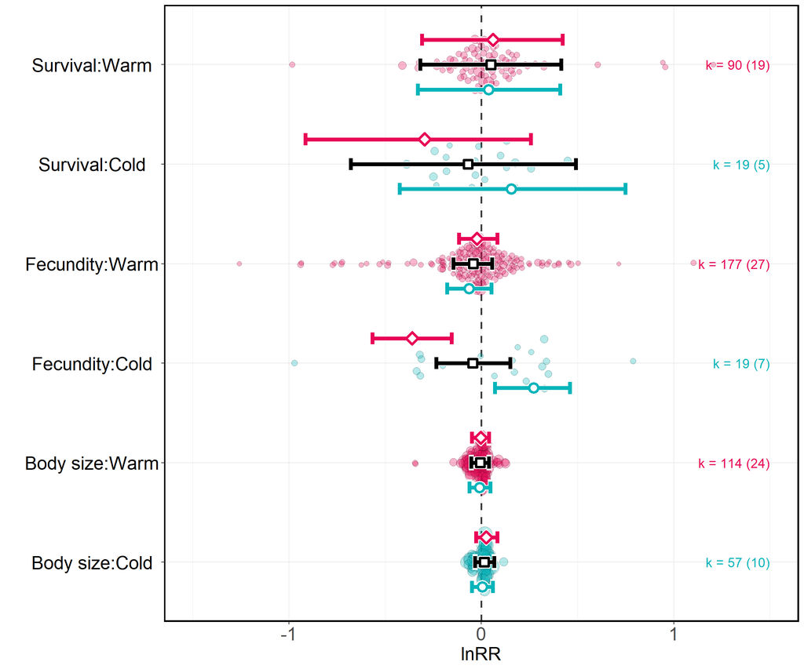

```r
# Plot
ggplot() +
    geom_hline(yintercept = 0, # Horizontal line
               linetype = 2,
               colour = "black",
               alpha = 0.75,
               lwd=1) +
    geom_quasirandom(data = data,     # Plot effect sizes, scaled by precision
                     aes(x = trait_type:warm_cold,
                         y = lnRR,
                         fill = trait_type:warm_cold,
                         size = 1/sqrt(var_lnRR)),
                     color = "black",
                     shape = 21,
                     width = 0.3,
                     alpha = 0.3) +
    geom_errorbar(data = filter(emmeans_full_model,
                                assay_temp_diff == "-5"),  # 5 degrees below control (background)
                  aes(x = trait_type:warm_cold,
                      ymin = lower.HPD,
                      ymax = upper.HPD),
                  color="white",
                  size = 2.75,
                  width = 0.16,
               position = position_nudge(x=-0.25)) +
    geom_point(data = filter(emmeans_full_model,
                             assay_temp_diff == "-5"),  # 5 degrees below control (background)
               aes(x = trait_type:warm_cold,
                   y = emmean),
               shape = 21,
               size = 4.5,
               stroke = 2,
               color="white",
               fill = "white",
               position = position_nudge(x=-0.25)) +
    geom_errorbar(data = filter(emmeans_full_model,
                             assay_temp_diff == "-5"), # 5 degrees below control (credible intervals)
                  aes(x = trait_type:warm_cold,
                      ymin = lower.HPD,
                      ymax = upper.HPD),
                  color="#06B4BA",
                  size = 2,
                  width = 0.12,
               position = position_nudge(x=-0.25)) +
    geom_point(data = filter(emmeans_full_model,
                             assay_temp_diff == "-5"), # 5 degrees below control  (point estimates)
               aes(x = trait_type:warm_cold,
                   y = emmean),
               shape = 21,
               size = 3.5,
               stroke = 2,
               color="#06B4BA",
               fill = "white",
               position = position_nudge(x=-0.25)) +

      geom_errorbar(data = filter(emmeans_full_model,
                                assay_temp_diff == "0"),  # control temperature (background)
                  aes(x = trait_type:warm_cold,
                      ymin = lower.HPD,
                      ymax = upper.HPD),
                  color="white",
                  size = 2.75,
                  width = 0.16,
               position = position_nudge(x=0)) +
    geom_point(data = filter(emmeans_full_model,
                             assay_temp_diff == "0"),  # control temperature (background)
               aes(x = trait_type:warm_cold,
                   y = emmean),
               shape = 22,
               size = 4.5,
               stroke = 2,
               color="white",
               fill = "white",
               position = position_nudge(x=0)) +
    geom_errorbar(data = filter(emmeans_full_model,
                             assay_temp_diff == "0"), # control temperature (credible intervals)
                  aes(x = trait_type:warm_cold,
                      ymin = lower.HPD,
                      ymax = upper.HPD),
                  color="black",
                  size = 2,
                  width = 0.12,
               position = position_nudge(x=0)) +
    geom_point(data = filter(emmeans_full_model,
                             assay_temp_diff == "0"), # control temperature (point estimates)
               aes(x = trait_type:warm_cold,
                   y = emmean),
               shape = 22,
               size = 3.5,
               stroke = 2,
               color="black",
               fill = "white",
               position = position_nudge(x=0)) +

      geom_errorbar(data = filter(emmeans_full_model,
                                assay_temp_diff == "5"),  # 5 degrees above control (background)
                  aes(x = trait_type:warm_cold,
                      ymin = lower.HPD,
                      ymax = upper.HPD),
                  color="white",
                  size = 2.75,
                  width = 0.16,
               position = position_nudge(x=0.25)) +
    geom_point(data = filter(emmeans_full_model,
                             assay_temp_diff == "5"),  # 5 degrees above control (background)
               aes(x = trait_type:warm_cold,
                   y = emmean),
               shape = 23,
               size = 4.5,
               stroke = 2,
               color="white",
               fill = "white",
               position = position_nudge(x=0.25)) +
    geom_errorbar(data = filter(emmeans_full_model,
                             assay_temp_diff == "5"), # 5 degrees above control (credible intervals)
                  aes(x = trait_type:warm_cold,
                      ymin = lower.HPD,
                      ymax = upper.HPD),
                  color="#E80756",
                  size = 2,
                  width = 0.12,
               position = position_nudge(x=0.25)) +
    geom_point(data = filter(emmeans_full_model,
                             assay_temp_diff == "5"), # 5 degrees above control (point estimates)
               aes(x = trait_type:warm_cold,
                   y = emmean),
               shape = 23,
               size = 3.5,
               stroke = 2,
               color="#E80756",
               fill = "white",
               position = position_nudge(x=0.25)) +

    geom_text(data = sample_sizes,  # Sample size annotations
              aes(x = trait_type:warm_cold,
                  y = 1.5,
                  label = paste0("k = ", estimates, " (", studies, ")"),
                  color = warm_cold),
              hjust = 1, size = 5, show.legend = FALSE) +

    theme_bw() +     # Customize the plot
    labs(y = "lnRR", x = "") +
    scale_size_continuous(range = c(2, 8))+
    scale_fill_manual(values = c("#06B4BA", "#E80756", "#06B4BA", "#E80756", "#06B4BA", "#E80756"))+
    scale_color_manual(values = c("Cold" = "#06B4BA", "Warm" = "#E80756")) +  # Text colour
    theme(text = element_text(size = 20, color = "black"),
          legend.title = ggplot2::element_text(size = 16),
          legend.text = ggplot2::element_text(size = 14),
          axis.text.y = ggplot2::element_text(size = 20,
                colour = "black", hjust = 0.5),
          axis.text.x = ggplot2::element_text(size = 20),
          panel.border = element_rect(color = "black", size = 1.5)) +
    guides(fill = "none", size = "none")+
    coord_flip() +
    ylim(-1.5, 1.5)
```

```r
ggsave(file = "fig/lnRR_all_moderators_marginal_means.png", width = 12, height = 8, dpi = 500)
```

**Overall trend with assay temperature**

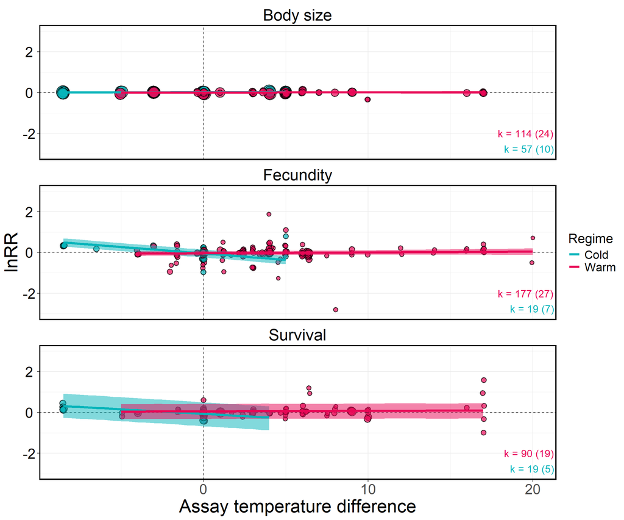

```r
# Generate predictions for all assay temperatures
emmeans_full_model_assay <- as.data.frame(emmeans(
  lnRR_model_all_moderators,
  specs = ~ assay_temp_diff * select_temp_diff * gen_selection * gen_common_garden | trait_type * warm_cold,
  at = list(assay_temp_diff = seq(min(data$assay_temp_diff), max(data$assay_temp_diff), by = 0.5) # Re-acclimated to control, or 5 degrees above/below the contol
  )))

# Calculate range of values for each category
range_df <- data %>%
  group_by(trait_type, warm_cold) %>%
  summarize(
    min_assay_temp_diff = min(assay_temp_diff),
    max_assay_temp_diff = max(assay_temp_diff)
  )

# Rename variable levels
emmeans_full_model_assay$trait_type <- factor(emmeans_full_model_assay$trait_type,
                          levels = c("body_size", "fecundity", "survival"),
                          labels = c("Body size", "Fecundity", "Survival"))

emmeans_full_model_assay$warm_cold <- factor(emmeans_full_model_assay$warm_cold,
                          levels = c("cold", "warm"),
                          labels = c("Cold", "Warm"))

# Tailor predictions to the range of the data
emmeans_full_model_assay <- emmeans_full_model_assay %>%
  left_join(range_df, by = c("trait_type", "warm_cold")) %>%
  filter(
    assay_temp_diff >= min_assay_temp_diff,
    assay_temp_diff <= max_assay_temp_diff
  )


# Plot
ggplot() +
    geom_hline(yintercept = 0, # Horizontal line
               linetype = 2,
               colour = "black",
               alpha = 0.75) +
    geom_vline(xintercept = 0, # Vertical line
               linetype = 2,
               colour = "black",
               alpha = 0.75) +
    geom_point(data = data, # Effect sizes, scaled by precision
                  aes(x = assay_temp_diff,
                      y = lnRR,
                      size = 1/sqrt(var_lnRR),
                      fill = warm_cold),
                  shape = 21,
                  alpha = 0.7,
                  stroke = 1,
                  position = position_jitter(width = 0.05)) +
     geom_ribbon(data = emmeans_full_model_assay, # Shaded area for credible intervals
                 aes(x = assay_temp_diff,
                     ymin = lower.HPD,
                     ymax = upper.HPD,
                     fill = warm_cold,
                     group = warm_cold),
                 alpha = .5) +
     geom_line(data = emmeans_full_model_assay,  # Predicted regression line
               aes(y = emmean,
                   x = assay_temp_diff,
                   color = warm_cold,
                   group = warm_cold),
               size = 1.5) +

    geom_text(data = sample_sizes,
              aes(x = Inf,
                  y = ifelse(warm_cold == "Warm", -2, -2.75),  # Sample sizes
                  label = paste0("k = ", estimates, " (", studies, ")"),
                  color = warm_cold),
              hjust = 1.05, size = 5, show.legend = FALSE) +

  facet_wrap(~ trait_type, ncol = 1) + # Different panels for each trait
  scale_fill_manual(values = c("#06B4BA", "#E80756"))+
  scale_color_manual(values = c("#06B4BA", "#E80756"))+
  labs(x = "Assay temperature difference", y = "lnRR",
       col = "Regime") +
  theme_bw() +
  scale_size_continuous(range = c(2, 8))+
  theme(text = element_text(size = 25, color = "black"),
          legend.title = ggplot2::element_text(size = 18),
          legend.text = ggplot2::element_text(size = 16),
          axis.text.y = ggplot2::element_text(size = 20,
                colour = "black", hjust = 0.5),
          axis.text.x = ggplot2::element_text(size = 20),
        panel.border = element_rect(color = "black", size = 1.5),
        strip.background = element_blank(),
        strip.text = element_text(color = "black", size = 22)) +
    guides(fill = "none", size = "none")+
    coord_cartesian(ylim = c(-3, 3))
```

```r
ggsave(file = "fig/lnRR_all_moderators_assay_temp_diff.png", width = 12, height = 10, dpi = 500)
```

## **Changes in relative trait variance (lnCVR)**

### **Overall model**

#### *Model specification*

```r
# Model specification
formula <- bf(lnCVR ~ trait_type -1 + # Separate effects by trait type
                (trait_type-1|ref) + # Correlation between traits among studies
                (1|species) + # Species-level random effect
                (1|gr(phylogeny, cov = phylo_matrix)) + # Phylogenetic relatedness
                (1|experiment_ID) + # Experiment-level random effect
                (1|obs) + # Observation-level random effect
                fcor(VCV_lnCVR)) # Variance covariance matix of correlated sampling variances

# Define priors
prior = c(
  prior(constant(1), class = "sigma")
) # Because the residual variance-covariance structure is specified in fcor, there is no need to estimate sigma so it is left as a constant

# Fit model
lnCVR_model_overall <- brm(formula,
                           family = gaussian(),
                           data = data,
                           data2 = list(phylo_matrix = phylo_matrix,
                                        VCV_lnCVR = VCV_lnCVR),
                           prior = prior,
                           control = list(adapt_delta = 0.99, max_treedepth = 15),
                           iter = 4000,
                           warmup = 2000,
                           chains = 4,
                           cores = 4,
                           seed = 123)

# Save model
saveRDS(lnCVR_model_overall, file = "RData/lnCVR_model_overall.rds")
```

#### *Model output*

```r
# Load model
lnCVR_model_overall <- readRDS("RData/lnCVR_model_overall.rds")

# Display model output
summary(lnCVR_model_overall)
```

```
##  Family: gaussian
##   Links: mu = identity; sigma = identity
## Formula: lnCVR ~ trait_type - 1 + (trait_type - 1 | ref) + (1 | species) + (1 | gr(phylogeny, cov = phylo_matrix)) + (1 | experiment_ID) + (1 | obs) + fcor(VCV_lnCVR)
##    Data: data (Number of observations: 476)
##   Draws: 4 chains, each with iter = 4000; warmup = 2000; thin = 1;
##          total post-warmup draws = 8000
##
## Multilevel Hyperparameters:
## ~experiment_ID (Number of levels: 88)
##               Estimate Est.Error l-95% CI u-95% CI Rhat Bulk_ESS Tail_ESS
## sd(Intercept)     0.11      0.05     0.01     0.22 1.00     1362     2302
##
## ~obs (Number of levels: 476)
##               Estimate Est.Error l-95% CI u-95% CI Rhat Bulk_ESS Tail_ESS
## sd(Intercept)     0.40      0.04     0.32     0.48 1.00     2165     4001
##
## ~phylogeny (Number of levels: 25)
##               Estimate Est.Error l-95% CI u-95% CI Rhat Bulk_ESS Tail_ESS
## sd(Intercept)     0.10      0.08     0.00     0.29 1.00     3123     3747
##
## ~ref (Number of levels: 44)
##                                              Estimate Est.Error l-95% CI
## sd(trait_typebody_size)                          0.06      0.05     0.00
## sd(trait_typefecundity)                          0.14      0.09     0.01
## sd(trait_typesurvival)                           0.48      0.15     0.21
## cor(trait_typebody_size,trait_typefecundity)     0.09      0.49    -0.84
## cor(trait_typebody_size,trait_typesurvival)     -0.03      0.49    -0.88
## cor(trait_typefecundity,trait_typesurvival)     -0.06      0.43    -0.85
##                                              u-95% CI Rhat Bulk_ESS Tail_ESS
## sd(trait_typebody_size)                          0.18 1.00     4025     4524
## sd(trait_typefecundity)                          0.34 1.00     1577     3479
## sd(trait_typesurvival)                           0.81 1.00     3029     3706
## cor(trait_typebody_size,trait_typefecundity)     0.89 1.00     2800     4724
## cor(trait_typebody_size,trait_typesurvival)      0.87 1.00     1260     3139
## cor(trait_typefecundity,trait_typesurvival)      0.76 1.00     2096     3841
##
## ~species (Number of levels: 25)
##               Estimate Est.Error l-95% CI u-95% CI Rhat Bulk_ESS Tail_ESS
## sd(Intercept)     0.07      0.05     0.00     0.20 1.00     3402     4336
##
## Regression Coefficients:
##                     Estimate Est.Error l-95% CI u-95% CI Rhat Bulk_ESS Tail_ESS
## trait_typebody_size     0.04      0.10    -0.14     0.25 1.00     3920     4162
## trait_typefecundity    -0.01      0.10    -0.21     0.19 1.00     4316     4214
## trait_typesurvival      0.13      0.16    -0.19     0.45 1.00     4845     5467
##
## Further Distributional Parameters:
##       Estimate Est.Error l-95% CI u-95% CI Rhat Bulk_ESS Tail_ESS
## sigma     1.00      0.00     1.00     1.00   NA       NA       NA
##
## Draws were sampled using sampling(NUTS). For each parameter, Bulk_ESS
## and Tail_ESS are effective sample size measures, and Rhat is the potential
## scale reduction factor on split chains (at convergence, Rhat = 1).
```

```r
# Cleaned model output
as.data.frame(fixef(lnCVR_model_overall, summary = TRUE)) %>%
  # Rename categorical variables for cleaner display
  rownames_to_column(var = "Parameter") %>%
  mutate(
    Parameter = gsub("trait_type([a-z_]+)", "\\1", Parameter)
  ) %>%
  # Round numbers to 3 decimal points
  mutate(across(c(Estimate, Q2.5, Q97.5), ~ round(., 3))) %>%
  select(Parameter, Estimate, `Lower CI` = Q2.5, `Upper CI` = Q97.5) %>%
  kable() %>%
  kable_styling(full_width = FALSE, position = "center", fixed_thead = TRUE) %>%
  column_spec(1, bold = TRUE, border_right = TRUE) %>%
  row_spec(0, background = "white", color = "black", bold = TRUE) %>%
  kable_styling(fixed_thead = TRUE)
```

| Parameter | Estimate | Lower CI | Upper CI |
| --- | --- | --- | --- |
| body_size | 0.045 | -0.139 | 0.250 |
| fecundity | -0.013 | -0.212 | 0.192 |
| survival | 0.127 | -0.185 | 0.449 |

#### *Heterogeneity analysis*

```r
# Extracting the posterior distribution from the model
posterior <- posterior_samples(lnCVR_model_overall)

# Calculate measurement error variance
sigma2_v <- sum(1/diag(VCV_lnCVR)) * (length(diag(VCV_lnCVR))- 1)/(sum(1/diag(VCV_lnCVR))^2 - sum((1/diag(VCV_lnCVR))^2))

# Calculate the total variance (including the measurement error variance)
var_total <- posterior$sd_experiment_ID__Intercept +
             posterior$sd_obs__Intercept +
             posterior$sd_phylogeny__Intercept +
             posterior$sd_ref__trait_typebody_size +
             posterior$sd_ref__trait_typefecundity +
             posterior$sd_ref__trait_typesurvival +
             posterior$sd_species__Intercept +
             sigma2_v

# Calculate heterogeneity (I2)
I2 <- list(
    I2_total = (var_total - sigma2_v) / var_total, # Total heterogeneity
    I2_study = (posterior$sd_ref__trait_typebody_size + # Heterogeneity explained by study differences
                posterior$sd_ref__trait_typefecundity +
                posterior$sd_ref__trait_typesurvival) / var_total,
    I2_exp = posterior$sd_experiment_ID__Intercept / var_total, # Heterogeneity explained by experiment differences
    I2_sp = posterior$sd_species__Intercept / var_total, # Heterogeneity explained by species differences
    I2_phylo = posterior$sd_phylogeny__Intercept / var_total, # Heterogeneity explained by phylogenetic relatedness
    I2_obs = posterior$sd_obs__Intercept / var_total # Heterogeneity explained by residual variation

)

# Calculate mean and credible intervals
summary_table <- t(sapply(I2, function(x) {
    c(Mean = 100*round(mean(x),4),
      ` ` = 100* round(quantile(x, 0.025),4),
      ` ` = 100*round(quantile(x, 0.975),4))
}))

# Customise table
summary_table <- summary_table %>%
    as.data.frame() %>%
    rownames_to_column("Variable") %>%
    mutate(
        Variable = recode(Variable,
                          "I2_total"  = "Total",
                          "I2_study"  = "Study",
                          "I2_exp"    = "Experiment",
                          "I2_sp"     = "Species",
                          "I2_phylo"  = "Phylogeny",
                          "I2_obs"    = "Residual")
    ) %>%
    rename(
        lower_HPD = ` .2.5%`,
        upper_HPD = ` .97.5%`
    ) %>%
  mutate(
    Variable = paste0("I<sup>2</sup><sub>", Variable)   # Create a new column with formatted I² and subscripts
  )


# Display table
kable(summary_table, "html", escape = FALSE,
      col.names = c("Heterogeneity (%)", "Mean", "Lower HPD", "Upper HPD"),
      align = c('l', 'r', 'r', 'r')) %>%
  kable_styling(full_width = FALSE, position = "center", fixed_thead = TRUE) %>%
  column_spec(1, width = "200px", bold = TRUE, border_right = TRUE) %>%
  row_spec(0, background = "white", color = "black", bold = TRUE) %>%
  kable_styling(fixed_thead = TRUE)
```

| Heterogeneity (%) | Mean | Lower HPD | Upper HPD |
| --- | --- | --- | --- |
| I<sup>2</sup><sub>Total</sub> | 90.51 | 87.57 | 92.92 |
| I<sup>2</sup><sub>Study</sub> | 44.97 | 29.15 | 59.30 |
| I<sup>2</sup><sub>Experiment</sub> | 7.61 | 0.72 | 14.61 |
| I<sup>2</sup><sub>Species</sub> | 4.40 | 0.16 | 12.65 |
| I<sup>2</sup><sub>Phylogeny</sub> | 6.28 | 0.30 | 17.32 |
| I<sup>2</sup><sub>Residual</sub> | 27.26 | 18.94 | 37.61 |

#### *Data visualisation*

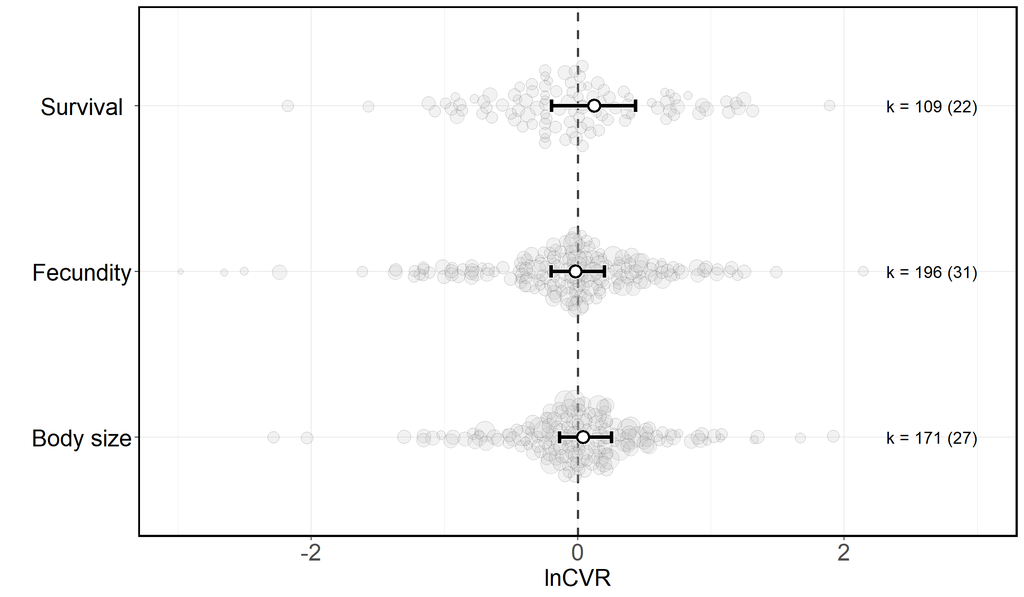

```r
# Generate predictions
emmeans_overall <- as.data.frame(emmeans(lnCVR_model_overall, ~ trait_type))

emmeans_overall$trait_type <- factor(emmeans_overall$trait_type,
                          levels = c("body_size", "fecundity", "survival"),
                          labels = c("Body size", "Fecundity", "Survival"))
# Plot
ggplot() +
    geom_hline(yintercept = 0, # Horizontal line
               linetype = 2,
               colour = "black",
               alpha = 0.75,
               lwd=1) +
    geom_quasirandom(data = data, # Plot effect sizes, scaled by precision
                     aes(x = trait_type,
                         y = lnCVR,
                         size = 1/sqrt(var_lnCVR)),
                     fill = "gray75",
                     shape = 21,
                     width = 0.25,
                     alpha = 0.2) +
    geom_errorbar(data = emmeans_overall,   # Plot the point estimates in white for background
                  aes(ymin = lower.HPD,
                      ymax = upper.HPD,
                      x = trait_type),
                  size = 2,
                  width = 0.085,
                  color = "white") +
    geom_point(data = emmeans_overall, # Plot the credible intervals in white for background
               aes(x = trait_type,
                   y = emmean),
               size = 4.5,
               stroke = 1.5,
               shape = 21,
               color="white",
               fill = "white") +
    geom_errorbar(data = emmeans_overall,  # Plot the point estimates
                  aes(x = trait_type,
                      ymin = lower.HPD,
                      ymax = upper.HPD),
                  size = 1.5,
                  width = 0.075,
                  color = "black") +
    geom_point(data = emmeans_overall, # Plot the credible intervals
               aes(x = trait_type,
                   y = emmean),
               size = 4,
               shape = 21,
               stroke = 1.5,
               color="black",
               fill = "white") +
    geom_text(data = sample_sizes_traits,  # Sample size annotations
              aes(x = trait_type,
                  y = 3,
                  label = paste0("k = ", estimates, " (", studies, ")")),
              hjust = 1, size = 5, show.legend = FALSE) +
    theme_bw() +     # Customize the plot
    labs(y = "lnCVR", x = "") +
    scale_size_continuous(range = c(2, 8))+
    theme(text = element_text(size = 20, color = "black"),
          legend.title = ggplot2::element_text(size = 16),
          legend.text = ggplot2::element_text(size = 14),
          axis.text.y = ggplot2::element_text(size = 20,
                colour = "black", hjust = 0.5),
          axis.text.x = ggplot2::element_text(size = 20),
          panel.border = element_rect(color = "black", size = 1.5)) +
    guides(color = "none", size = "none")+
    coord_flip() +
    ylim(-3, 3)
```

```r
# Save figure
ggsave(file = "fig/lnCVR_overall.png", width = 12, height = 7, dpi = 500)
```

### **Temperature regime**

#### *Model specification*

```r
# Model specification
formula <- bf(lnCVR ~ trait_type:warm_cold -1 + # Separate effects by trait type
                (trait_type-1|ref) + # Correlation between traits among studies
                (1|species) + # Species-level random effect
                (1|gr(phylogeny, cov = phylo_matrix)) + # Phylogenetic relatedness
                (1|experiment_ID) + # Experiment-level random effect
                (1|obs) + # Observation-level random effect
                fcor(VCV_lnCVR)) # Variance covariance matix of correlated sampling variances

# Define priors
prior = c(
  prior(constant(1), class = "sigma")
) # Because the residual variance-covariance structure is specified in fcor, there is no need to estimate sigma so it is left as a constant

# Fit model
lnCVR_model_warm_cold <- brm(formula,
                  family = gaussian(),
                  data = data,
                  data2 = list(phylo_matrix = phylo_matrix,
                               VCV_lnCVR = VCV_lnCVR),
                  prior = prior,
                  control = list(adapt_delta = 0.99, max_treedepth = 15),
                  iter = 4000,
                  warmup = 2000,
                  chains = 4,
                  cores = 4,
                  seed = 123)

# Save model
saveRDS(lnCVR_model_warm_cold, file = "RData/lnCVR_model_warm_cold.rds")
```

#### *Model output*

```r
# Load model
lnCVR_model_warm_cold <- readRDS("RData/lnCVR_model_warm_cold.rds")

# Display model output
summary(lnCVR_model_warm_cold)
```

```
##  Family: gaussian
##   Links: mu = identity; sigma = identity
## Formula: lnCVR ~ trait_type:warm_cold - 1 + (trait_type - 1 | ref) + (1 | species) + (1 | gr(phylogeny, cov = phylo_matrix)) + (1 | experiment_ID) + (1 | obs) + fcor(VCV_lnCVR)
##    Data: data (Number of observations: 476)
##   Draws: 4 chains, each with iter = 4000; warmup = 2000; thin = 1;
##          total post-warmup draws = 8000
##
## Multilevel Hyperparameters:
## ~experiment_ID (Number of levels: 88)
##               Estimate Est.Error l-95% CI u-95% CI Rhat Bulk_ESS Tail_ESS
## sd(Intercept)     0.11      0.05     0.01     0.21 1.00     1334     1916
##
## ~obs (Number of levels: 476)
##               Estimate Est.Error l-95% CI u-95% CI Rhat Bulk_ESS Tail_ESS
## sd(Intercept)     0.40      0.04     0.32     0.49 1.00     2074     4187
##
## ~phylogeny (Number of levels: 25)
##               Estimate Est.Error l-95% CI u-95% CI Rhat Bulk_ESS Tail_ESS
## sd(Intercept)     0.09      0.07     0.00     0.28 1.00     3146     4236
##
## ~ref (Number of levels: 44)
##                                              Estimate Est.Error l-95% CI
## sd(trait_typebody_size)                          0.06      0.05     0.00
## sd(trait_typefecundity)                          0.13      0.09     0.01
## sd(trait_typesurvival)                           0.49      0.15     0.22
## cor(trait_typebody_size,trait_typefecundity)     0.07      0.49    -0.86
## cor(trait_typebody_size,trait_typesurvival)     -0.00      0.51    -0.89
## cor(trait_typefecundity,trait_typesurvival)     -0.04      0.43    -0.84
##                                              u-95% CI Rhat Bulk_ESS Tail_ESS
## sd(trait_typebody_size)                          0.17 1.00     3651     3866
## sd(trait_typefecundity)                          0.33 1.00     1485     3152
## sd(trait_typesurvival)                           0.81 1.00     3533     4364
## cor(trait_typebody_size,trait_typefecundity)     0.89 1.00     3524     4596
## cor(trait_typebody_size,trait_typesurvival)      0.89 1.00     1148     2616
## cor(trait_typefecundity,trait_typesurvival)      0.79 1.00     2256     3614
##
## ~species (Number of levels: 25)
##               Estimate Est.Error l-95% CI u-95% CI Rhat Bulk_ESS Tail_ESS
## sd(Intercept)     0.06      0.05     0.00     0.19 1.00     4014     5084
##
```

[output cut: 8 more lines]

```
##                                   Bulk_ESS Tail_ESS
## trait_typebody_size:warm_coldcold     3244     3195
## trait_typefecundity:warm_coldcold     4902     4558
## trait_typesurvival:warm_coldcold      5701     5908
## trait_typebody_size:warm_coldwarm     3466     3174
## trait_typefecundity:warm_coldwarm     3853     2660
## trait_typesurvival:warm_coldwarm      5207     4433
##
## Further Distributional Parameters:
##       Estimate Est.Error l-95% CI u-95% CI Rhat Bulk_ESS Tail_ESS
## sigma     1.00      0.00     1.00     1.00   NA       NA       NA
##
## Draws were sampled using sampling(NUTS). For each parameter, Bulk_ESS
## and Tail_ESS are effective sample size measures, and Rhat is the potential
## scale reduction factor on split chains (at convergence, Rhat = 1).
```

```r
# R2
r2(lnCVR_model_warm_cold)
```

```
## # Bayesian R2 with Compatibility Interval
##
##   Conditional R2: 0.281 (95% CI [0.216, 0.349])
##      Marginal R2: 0.014 (95% CI [7.949e-04, 0.038])
```

```r
# Cleaned model output
as.data.frame(fixef(lnCVR_model_warm_cold, summary = TRUE)) %>%
  # Rename categorical variables for cleaner display
  rownames_to_column(var = "Parameter") %>%
  mutate(
    # Simplify `trait_type` and `warm_cold` interactions
    Parameter = gsub("trait_type([a-z_]+):warm_cold(cold|warm)", "\\1(\\2)", Parameter)
  ) %>%
  # Round numbers to 3 decimal points
  mutate(across(c(Estimate, Q2.5, Q97.5), ~ round(., 3))) %>%
  select(Parameter, Estimate, `Lower CI` = Q2.5, `Upper CI` = Q97.5) %>%
  kable() %>%
  kable_styling(full_width = FALSE, position = "center", fixed_thead = TRUE) %>%
  column_spec(1, bold = TRUE, border_right = TRUE) %>%
  row_spec(0, background = "white", color = "black", bold = TRUE) %>%
  kable_styling(fixed_thead = TRUE)
```

| Parameter | Estimate | Lower CI | Upper CI |
| --- | --- | --- | --- |
| body_size(cold) | -0.020 | -0.251 | 0.216 |
| fecundity(cold) | -0.152 | -0.529 | 0.227 |
| survival(cold) | 0.001 | -0.522 | 0.533 |
| body_size(warm) | 0.057 | -0.132 | 0.259 |
| fecundity(warm) | -0.002 | -0.194 | 0.201 |
| survival(warm) | 0.141 | -0.190 | 0.471 |

#### *Contrasts*

```r
# Generate predictions
emms <- emmeans(lnCVR_model_warm_cold,
                specs = ~ warm_cold | trait_type)

# Generate contrasts
contrast(emms, method = "pairwise")
```

```
## trait_type = body_size:
##  contrast    estimate lower.HPD upper.HPD
##  cold - warm  -0.0779    -0.265     0.114
##
## trait_type = fecundity:
##  contrast    estimate lower.HPD upper.HPD
##  cold - warm  -0.1509    -0.516     0.228
##
## trait_type = survival:
##  contrast    estimate lower.HPD upper.HPD
##  cold - warm  -0.1437    -0.667     0.384
##
## Point estimate displayed: median
## HPD interval probability: 0.95
```

#### *Data visualisation*

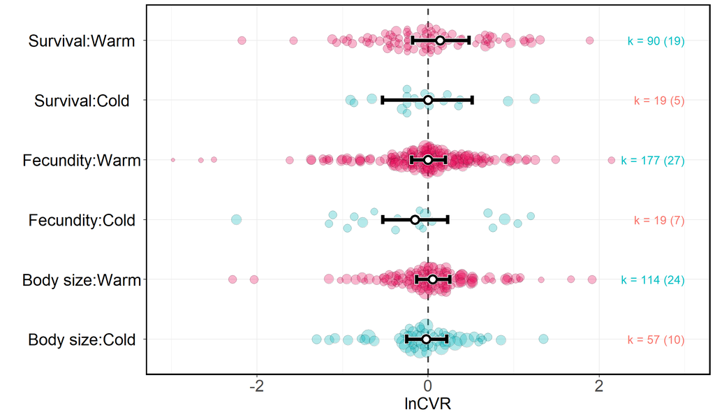

```r
# Generate predictions
emmeans_warm_cold <- as.data.frame(emmeans(lnCVR_model_warm_cold,
                                           specs = ~ warm_cold | trait_type))

emmeans_warm_cold$trait_type <- factor(emmeans_warm_cold$trait_type,
                          levels = c("body_size", "fecundity", "survival"),
                          labels = c("Body size", "Fecundity", "Survival"))


emmeans_warm_cold$warm_cold <- factor(emmeans_warm_cold$warm_cold,
                          levels = c("cold", "warm"),
                          labels = c("Cold", "Warm"))
# Plot
ggplot() +
    geom_hline(yintercept = 0, # Horizontal line
               linetype = 2,
               colour = "black",
               alpha = 0.75,
               lwd=1) +
    geom_quasirandom(data = data,     # Plot effect sizes, scaled by precision
                     aes(x = trait_type:warm_cold,
                         y = lnCVR,
                         fill = trait_type:warm_cold,
                         size = 1/sqrt(var_lnCVR)),
                     color = "black",
                     shape = 21,
                     width = 0.25,
                     alpha = 0.3) +
    geom_errorbar(data = emmeans_warm_cold,  # Plot the point estimates in white for background
                  aes(x = trait_type:warm_cold,
                      ymin = lower.HPD,
                      ymax = upper.HPD),
                  color="white",
                  size = 2.5,
                  width = 0.17) +
    geom_point(data = emmeans_warm_cold,  # Plot the credible intervals in white for background
               aes(x = trait_type:warm_cold,
                   y = emmean),
               shape = 21,
               size = 4,
               stroke = 2,
               color="white",
               fill = "white") +
    geom_errorbar(data = emmeans_warm_cold, # Plot the point estimates
                  aes(x = trait_type:warm_cold,
                      ymin = lower.HPD,
                      ymax = upper.HPD),
                  color="black",
                  size = 2,
                  width = 0.15) +
    geom_point(data = emmeans_warm_cold, # Plot the credible intervals
               aes(x = trait_type:warm_cold,
                   y = emmean),
               shape = 21,
               size = 3.5,
               stroke = 2,
               color="black",
               fill = "white") +
    geom_text(data = sample_sizes,  # Sample size annotations
              aes(x = trait_type:warm_cold,
                  y = 3,
                  label = paste0("k = ", estimates, " (", studies, ")"),
                  color = warm_cold),
              hjust = 1, size = 5, show.legend = FALSE) +
    theme_bw() +     # Customize the plot
    labs(y = "lnCVR", x = "") +
    scale_size_continuous(range = c(2, 8))+
#    scale_fill_manual(values = c("#A5F820", "#73B706",  "#9CEFFC", "#06A2BA",  "#FED2ED", "#B90674"))+
    scale_fill_manual(values = c("#06B4BA", "#E80756", "#06B4BA", "#E80756", "#06B4BA", "#E80756"))+
    theme(text = element_text(size = 20, color = "black"),
          legend.title = ggplot2::element_text(size = 16),
          legend.text = ggplot2::element_text(size = 14),
          axis.text.y = ggplot2::element_text(size = 20,
                colour = "black", hjust = 0.5),
          axis.text.x = ggplot2::element_text(size = 20),
          panel.border = element_rect(color = "black", size = 1.5)) +
    guides(fill = "none", size = "none")+
    coord_flip() +
    ylim(-3, 3)
```

```r
ggsave(file = "fig/lnCVR_warm_cold.png", width = 12, height = 7, dpi = 500)
```

### **Assay temperature difference**

We calculated the difference between the assay temperature and control temperature (assay_temp_diff) to account for the fact that animals were tested to a different range of temperatures. We also predicted that effects will vary if traits are assayed at colder- or warmer-than-control conditions, depending on the temperature regime. Because the variation in assay temperature generates some nuisance heterogeneity (sensu Noble et al., 2017), the results of subsequent models were provided after controlling for assay temperature differences. In order words, the results of all moderators are conditional on assay temperature, meaning that results are interpretable as the difference between control and selected lines, when animals are tested at the control temperature.

#### *Model specification*

```r
# Model specification
formula <- bf(lnCVR ~ 0 + trait_type:warm_cold + trait_type:warm_cold:assay_temp_diff + # Separate effects by trait type
                (trait_type-1|ref) + # Correlation between traits among studies
                (1|species) + # Species-level random effect
                (1|gr(phylogeny, cov = phylo_matrix)) + # Phylogenetic relatedness
                (1|experiment_ID) + # Experiment-level random effect
                (1|obs) + # Observation-level random effect
                fcor(VCV_lnCVR)) # Variance covariance matix of correlated sampling variances

# Define priors
prior = c(
  prior(constant(1), class = "sigma")
) # Because the residual variance-covariance structure is specified in fcor, there is no need to estimate sigma so it is left as a constant

# Fit model
lnCVR_model_assay_temp_diff <- brm(formula,
                                  family = gaussian(),
                                  data = data,
                                  data2 = list(phylo_matrix = phylo_matrix,
                                               VCV_lnCVR = VCV_lnCVR),
                                  prior = prior,
                                  control = list(adapt_delta = 0.99, max_treedepth = 15),
                                  iter = 4000,
                                  warmup = 2000,
                                  chains = 4,
                                  cores = 4,
                                  seed = 123)

# Save model
saveRDS(lnCVR_model_assay_temp_diff, file = "RData/lnCVR_model_assay_temp_diff.rds")
```

#### *Model output*

```r
# Load model
lnCVR_model_assay_temp_diff <- readRDS("RData/lnCVR_model_assay_temp_diff.rds")

# Display model output
summary(lnCVR_model_assay_temp_diff)
```

```
##  Family: gaussian
##   Links: mu = identity; sigma = identity
## Formula: lnCVR ~ 0 + trait_type:warm_cold + trait_type:warm_cold:assay_temp_diff + (trait_type - 1 | ref) + (1 | species) + (1 | gr(phylogeny, cov = phylo_matrix)) + (1 | experiment_ID) + (1 | obs) + fcor(VCV_lnCVR)
##    Data: data (Number of observations: 476)
##   Draws: 4 chains, each with iter = 4000; warmup = 2000; thin = 1;
##          total post-warmup draws = 8000
##
## Multilevel Hyperparameters:
## ~experiment_ID (Number of levels: 88)
##               Estimate Est.Error l-95% CI u-95% CI Rhat Bulk_ESS Tail_ESS
## sd(Intercept)     0.09      0.05     0.01     0.20 1.01     1355     3293
##
## ~obs (Number of levels: 476)
##               Estimate Est.Error l-95% CI u-95% CI Rhat Bulk_ESS Tail_ESS
## sd(Intercept)     0.40      0.04     0.32     0.48 1.00     2181     4146
##
## ~phylogeny (Number of levels: 25)
##               Estimate Est.Error l-95% CI u-95% CI Rhat Bulk_ESS Tail_ESS
## sd(Intercept)     0.09      0.07     0.00     0.28 1.00     3565     4130
##
## ~ref (Number of levels: 44)
##                                              Estimate Est.Error l-95% CI
## sd(trait_typebody_size)                          0.06      0.05     0.00
## sd(trait_typefecundity)                          0.10      0.08     0.00
## sd(trait_typesurvival)                           0.52      0.15     0.25
## cor(trait_typebody_size,trait_typefecundity)     0.05      0.49    -0.86
## cor(trait_typebody_size,trait_typesurvival)     -0.00      0.50    -0.88
## cor(trait_typefecundity,trait_typesurvival)     -0.05      0.45    -0.85
##                                              u-95% CI Rhat Bulk_ESS Tail_ESS
## sd(trait_typebody_size)                          0.18 1.00     4100     5188
## sd(trait_typefecundity)                          0.30 1.00     2451     3961
## sd(trait_typesurvival)                           0.86 1.00     3645     3396
## cor(trait_typebody_size,trait_typefecundity)     0.88 1.00     5017     5682
## cor(trait_typebody_size,trait_typesurvival)      0.87 1.00     1598     3433
## cor(trait_typefecundity,trait_typesurvival)      0.81 1.00     2117     3653
##
## ~species (Number of levels: 25)
##               Estimate Est.Error l-95% CI u-95% CI Rhat Bulk_ESS Tail_ESS
## sd(Intercept)     0.06      0.05     0.00     0.19 1.00     3679     4328
##
```

[output cut: 33 more lines]

```
## trait_typesurvival:warm_coldwarm                      5541
## trait_typebody_size:warm_coldcold:assay_temp_diff     5124
## trait_typefecundity:warm_coldcold:assay_temp_diff     6069
## trait_typesurvival:warm_coldcold:assay_temp_diff      6487
## trait_typebody_size:warm_coldwarm:assay_temp_diff     6990
## trait_typefecundity:warm_coldwarm:assay_temp_diff     6687
## trait_typesurvival:warm_coldwarm:assay_temp_diff      6171
##
## Further Distributional Parameters:
##       Estimate Est.Error l-95% CI u-95% CI Rhat Bulk_ESS Tail_ESS
## sigma     1.00      0.00     1.00     1.00   NA       NA       NA
##
## Draws were sampled using sampling(NUTS). For each parameter, Bulk_ESS
## and Tail_ESS are effective sample size measures, and Rhat is the potential
## scale reduction factor on split chains (at convergence, Rhat = 1).
```

```r
# R2
r2(lnCVR_model_assay_temp_diff)
```

```
## # Bayesian R2 with Compatibility Interval
##
##   Conditional R2: 0.300 (95% CI [0.237, 0.367])
##      Marginal R2: 0.047 (95% CI [0.018, 0.082])
```

```r
# Cleaned model output
as.data.frame(fixef(lnCVR_model_assay_temp_diff, summary = TRUE)) %>%
  # Rename categorical variables for cleaner display
  rownames_to_column(var = "Parameter") %>%
  mutate(
    Parameter = gsub("trait_type([a-z_]+):warm_cold(cold|warm)", "\\1(\\2)", Parameter),
    Parameter = gsub("trait_type([a-z_]+)\\(warm\\):assay_temp_diff", "\\1(warm): assay_temp_diff", Parameter)
  ) %>%
  # Round numbers to 3 decimal points
  mutate(across(c(Estimate, Q2.5, Q97.5), ~ round(., 3))) %>%
  select(Parameter, Estimate, `Lower CI` = Q2.5, `Upper CI` = Q97.5) %>%
  kable() %>%
  kable_styling(full_width = FALSE, position = "center", fixed_thead = TRUE) %>%
  column_spec(1, bold = TRUE, border_right = TRUE) %>%
  row_spec(0, background = "white", color = "black", bold = TRUE) %>%
  kable_styling(fixed_thead = TRUE)
```

| Parameter | Estimate | Lower CI | Upper CI |
| --- | --- | --- | --- |
| body_size(cold) | -0.017 | -0.237 | 0.230 |
| fecundity(cold) | -0.281 | -0.667 | 0.112 |
| survival(cold) | 0.118 | -0.450 | 0.694 |
| body_size(warm) | 0.055 | -0.144 | 0.277 |
| fecundity(warm) | -0.055 | -0.259 | 0.158 |
| survival(warm) | 0.235 | -0.133 | 0.619 |
| body_size(cold):assay_temp_diff | -0.007 | -0.049 | 0.034 |
| fecundity(cold):assay_temp_diff | -0.139 | -0.216 | -0.063 |
| survival(cold):assay_temp_diff | 0.028 | -0.048 | 0.101 |
| body_size(warm):assay_temp_diff | 0.002 | -0.031 | 0.036 |
| fecundity(warm):assay_temp_diff | 0.018 | -0.013 | 0.048 |
| survival(warm):assay_temp_diff | -0.025 | -0.074 | 0.022 |

#### *Data visualisation*

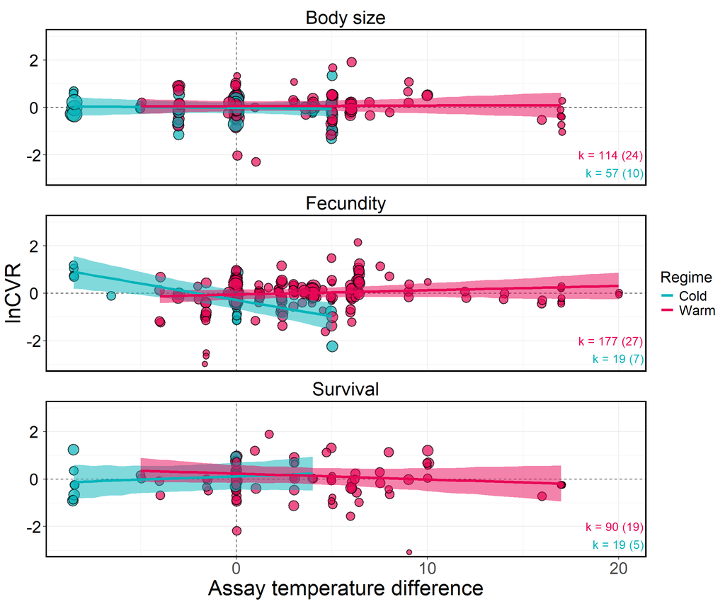

```r
# Generate predictions
emmeans_assay_temp_diff <- as.data.frame(emmeans(
  lnCVR_model_assay_temp_diff,
  specs = ~ assay_temp_diff | trait_type * warm_cold,
  at = list(assay_temp_diff = seq(min(data$assay_temp_diff), max(data$assay_temp_diff), by = 0.5)))
  )

# Calculate range of values for each category
range_df <- data %>%
  group_by(trait_type, warm_cold) %>%
  summarize(
    min_assay_temp_diff = min(assay_temp_diff),
    max_assay_temp_diff = max(assay_temp_diff)
  )

emmeans_assay_temp_diff$trait_type <- factor(emmeans_assay_temp_diff$trait_type,
                          levels = c("body_size", "fecundity", "survival"),
                          labels = c("Body size", "Fecundity", "Survival"))

emmeans_assay_temp_diff$warm_cold <- factor(emmeans_assay_temp_diff$warm_cold,
                          levels = c("cold", "warm"),
                          labels = c("Cold", "Warm"))

# Tailor predictions to the range of the data
emmeans_assay_temp_diff <- emmeans_assay_temp_diff %>%
  left_join(range_df, by = c("trait_type", "warm_cold")) %>%
  filter(
    assay_temp_diff >= min_assay_temp_diff,
    assay_temp_diff <= max_assay_temp_diff
  )

# Plot
ggplot() +
    geom_hline(yintercept = 0, # Horizontal line
               linetype = 2,
               colour = "black",
               alpha = 0.75) +
    geom_vline(xintercept = 0, # Vertical line
               linetype = 2,
               colour = "black",
               alpha = 0.75) +
    geom_point(data = data, # Effect sizes, scaled by precision
                  aes(x = assay_temp_diff,
                      y = lnCVR,
                      size = 1/sqrt(var_lnCVR),
                      fill = warm_cold),
                  shape = 21,
                  alpha = 0.7,
                  stroke = 1,
                  position = position_jitter(width = 0.05)) +
     geom_ribbon(data = emmeans_assay_temp_diff, # Shaded area for credible intervals
                 aes(x = assay_temp_diff,
                     ymin = lower.HPD,
                     ymax = upper.HPD,
                     fill = warm_cold,
                     group = warm_cold),
                 alpha = .5) +
     geom_line(data = emmeans_assay_temp_diff,  # Predicted regression line
               aes(y = emmean,
                   x = assay_temp_diff,
                   color = warm_cold,
                   group = warm_cold),
               size = 1.5) +

    geom_text(data = sample_sizes,
              aes(x = Inf,
                  y = ifelse(warm_cold == "Warm", -2, -2.75),  # Sample sizes
                  label = paste0("k = ", estimates, " (", studies, ")"),
                  color = warm_cold),
              hjust = 1.05, size = 5, show.legend = FALSE) +

  facet_wrap(~ trait_type, ncol = 1) + # Different panels for each trait
  scale_fill_manual(values = c("#06B4BA", "#E80756"))+
  scale_color_manual(values = c("#06B4BA", "#E80756"))+
  labs(x = "Assay temperature difference", y = "lnCVR",
       col = "Regime") +
  theme_bw() +
  scale_size_continuous(range = c(2, 8))+
  theme(text = element_text(size = 25, color = "black"),
          legend.title = ggplot2::element_text(size = 18),
          legend.text = ggplot2::element_text(size = 16),
          axis.text.y = ggplot2::element_text(size = 20,
                colour = "black", hjust = 0.5),
          axis.text.x = ggplot2::element_text(size = 20),
        panel.border = element_rect(color = "black", size = 1.5),
        strip.background = element_blank(),
        strip.text = element_text(color = "black", size = 22)) +
    guides(fill = "none", size = "none")+
    coord_cartesian(ylim = c(-3, 3))
```

```r
ggsave(file = "fig/lnCVR_assay_temp_diff.png", width = 12, height = 10, dpi = 500)
```

### **Selection temperature**

#### *Model specification*

```r
# Model specification
formula <- bf(lnCVR ~ 0 + trait_type:warm_cold +
                          trait_type:warm_cold:assay_temp_diff +
                          trait_type:warm_cold:select_temp_diff + # Separate effects by trait type
                (trait_type-1|ref) + # Correlation between traits among studies
                (1|species) + # Species-level random effect
                (1|gr(phylogeny, cov = phylo_matrix)) + # Phylogenetic relatedness
                (1|experiment_ID) + # Experiment-level random effect
                (1|obs) + # Observation-level random effect
                fcor(VCV_lnCVR)) # Variance covariance matix of correlated sampling variances

# Define priors
prior = c(
  prior(constant(1), class = "sigma")
) # Because the residual variance-covariance structure is specified in fcor, there is no need to estimate sigma so it is left as a constant

# Fit model
lnCVR_model_sel_temp_diff <- brm(formula,
                                family = gaussian(),
                                data = data,
                                data2 = list(phylo_matrix = phylo_matrix,
                                             VCV_lnCVR = VCV_lnCVR),
                                prior = prior,
                                control = list(adapt_delta = 0.99, max_treedepth = 15),
                                iter = 4000,
                                warmup = 2000,
                                chains = 4,
                                cores = 4,
                                seed = 123)

# Save model
saveRDS(lnCVR_model_sel_temp_diff, file = "RData/lnCVR_model_sel_temp_diff.rds")
```

#### *Model output*

```r
# Load model
lnCVR_model_sel_temp_diff <- readRDS("RData/lnCVR_model_sel_temp_diff.rds")

# Display model output
summary(lnCVR_model_sel_temp_diff)
```

```
##  Family: gaussian
##   Links: mu = identity; sigma = identity
## Formula: lnCVR ~ 0 + trait_type:warm_cold + trait_type:warm_cold:assay_temp_diff + trait_type:warm_cold:select_temp_diff + (trait_type - 1 | ref) + (1 | species) + (1 | gr(phylogeny, cov = phylo_matrix)) + (1 | experiment_ID) + (1 | obs) + fcor(VCV_lnCVR)
##    Data: data (Number of observations: 476)
##   Draws: 4 chains, each with iter = 4000; warmup = 2000; thin = 1;
##          total post-warmup draws = 8000
##
## Multilevel Hyperparameters:
## ~experiment_ID (Number of levels: 88)
##               Estimate Est.Error l-95% CI u-95% CI Rhat Bulk_ESS Tail_ESS
## sd(Intercept)     0.10      0.06     0.01     0.21 1.00     1120     2464
##
## ~obs (Number of levels: 476)
##               Estimate Est.Error l-95% CI u-95% CI Rhat Bulk_ESS Tail_ESS
## sd(Intercept)     0.39      0.04     0.32     0.47 1.00     2157     3877
##
## ~phylogeny (Number of levels: 25)
##               Estimate Est.Error l-95% CI u-95% CI Rhat Bulk_ESS Tail_ESS
## sd(Intercept)     0.09      0.08     0.00     0.28 1.00     3736     4900
##
## ~ref (Number of levels: 44)
##                                              Estimate Est.Error l-95% CI
## sd(trait_typebody_size)                          0.06      0.05     0.00
## sd(trait_typefecundity)                          0.12      0.09     0.00
## sd(trait_typesurvival)                           0.56      0.17     0.27
## cor(trait_typebody_size,trait_typefecundity)     0.01      0.50    -0.87
## cor(trait_typebody_size,trait_typesurvival)     -0.01      0.49    -0.88
## cor(trait_typefecundity,trait_typesurvival)     -0.01      0.44    -0.82
##                                              u-95% CI Rhat Bulk_ESS Tail_ESS
## sd(trait_typebody_size)                          0.19 1.00     4189     4553
## sd(trait_typefecundity)                          0.35 1.00     1509     3322
## sd(trait_typesurvival)                           0.93 1.00     3008     3730
## cor(trait_typebody_size,trait_typefecundity)     0.89 1.00     3113     4820
## cor(trait_typebody_size,trait_typesurvival)      0.86 1.00     1144     2987
## cor(trait_typefecundity,trait_typesurvival)      0.82 1.01     1465     3650
##
## ~species (Number of levels: 25)
##               Estimate Est.Error l-95% CI u-95% CI Rhat Bulk_ESS Tail_ESS
## sd(Intercept)     0.06      0.05     0.00     0.19 1.00     3694     4452
##
```

[output cut: 51 more lines]

```
## trait_typesurvival:warm_coldwarm:assay_temp_diff       6546
## trait_typebody_size:warm_coldcold:select_temp_diff     4678
## trait_typefecundity:warm_coldcold:select_temp_diff     5201
## trait_typesurvival:warm_coldcold:select_temp_diff      5669
## trait_typebody_size:warm_coldwarm:select_temp_diff     6029
## trait_typefecundity:warm_coldwarm:select_temp_diff     5784
## trait_typesurvival:warm_coldwarm:select_temp_diff      4512
##
## Further Distributional Parameters:
##       Estimate Est.Error l-95% CI u-95% CI Rhat Bulk_ESS Tail_ESS
## sigma     1.00      0.00     1.00     1.00   NA       NA       NA
##
## Draws were sampled using sampling(NUTS). For each parameter, Bulk_ESS
## and Tail_ESS are effective sample size measures, and Rhat is the potential
## scale reduction factor on split chains (at convergence, Rhat = 1).
```

```r
# Cleaned model output
as.data.frame(fixef(lnCVR_model_sel_temp_diff, summary = TRUE)) %>%
  # Rename categorical variables for cleaner display
  rownames_to_column(var = "Parameter") %>%
  mutate(
    Parameter = gsub("trait_type([a-z_]+):warm_cold(cold|warm)", "\\1(\\2)", Parameter),
    Parameter = gsub("trait_type([a-z_]+)\\(warm\\):select_temp_diff", "\\1(warm): select_temp_diff", Parameter)
  ) %>%
  # Round numbers to 3 decimal points
  mutate(across(c(Estimate, Q2.5, Q97.5), ~ round(., 3))) %>%
  select(Parameter, Estimate, `Lower CI` = Q2.5, `Upper CI` = Q97.5) %>%
  kable() %>%
  kable_styling(full_width = FALSE, position = "center", fixed_thead = TRUE) %>%
  column_spec(1, bold = TRUE, border_right = TRUE) %>%
  row_spec(0, background = "white", color = "black", bold = TRUE) %>%
  kable_styling(fixed_thead = TRUE)
```

| Parameter | Estimate | Lower CI | Upper CI |
| --- | --- | --- | --- |
| body_size(cold) | -0.273 | -0.764 | 0.221 |
| fecundity(cold) | -0.317 | -1.363 | 0.745 |
| survival(cold) | 0.229 | -2.449 | 2.924 |
| body_size(warm) | 0.247 | -0.072 | 0.576 |
| fecundity(warm) | 0.065 | -0.253 | 0.399 |
| survival(warm) | 0.315 | -0.316 | 1.036 |
| body_size(cold):assay_temp_diff | 0.005 | -0.040 | 0.050 |
| fecundity(cold):assay_temp_diff | -0.135 | -0.223 | -0.050 |
| survival(cold):assay_temp_diff | 0.028 | -0.050 | 0.105 |
| body_size(warm):assay_temp_diff | 0.017 | -0.020 | 0.055 |
| fecundity(warm):assay_temp_diff | 0.024 | -0.009 | 0.055 |
| survival(warm):assay_temp_diff | -0.024 | -0.073 | 0.027 |
| body_size(cold):select_temp_diff | 0.043 | -0.031 | 0.117 |
| fecundity(cold):select_temp_diff | 0.006 | -0.146 | 0.162 |
| survival(cold):select_temp_diff | -0.016 | -0.374 | 0.346 |
| body_size(warm):select_temp_diff | -0.046 | -0.099 | 0.007 |
| fecundity(warm):select_temp_diff | -0.031 | -0.094 | 0.031 |
| survival(warm):select_temp_diff | -0.014 | -0.120 | 0.077 |

#### *Data visualisation*

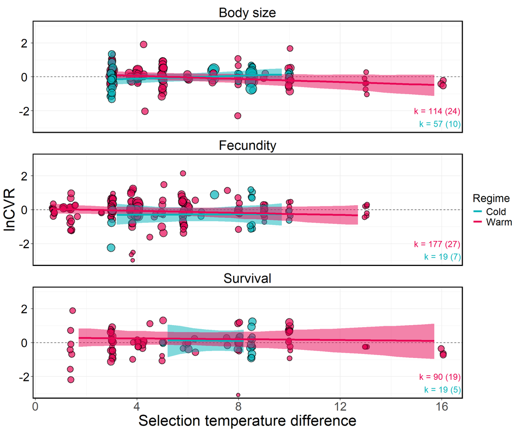

```r
# Generate predictions
emmeans_sel_temp_diff <- as.data.frame(emmeans(
  lnCVR_model_sel_temp_diff,
  specs = ~ select_temp_diff | trait_type * warm_cold,
  at = list(select_temp_diff = seq(min(data$select_temp_diff), max(data$select_temp_diff), by = 0.5),
            assay_temp_diff = 0))
  ) # Conditional effects on assay_temp_diff = 0

# Calculate range of values for each category
range_df <- data %>%
  group_by(trait_type, warm_cold) %>%
  summarize(
    min_select_temp_diff = min(select_temp_diff),
    max_select_temp_diff = max(select_temp_diff)
  )

emmeans_sel_temp_diff$trait_type <- factor(emmeans_sel_temp_diff$trait_type,
                          levels = c("body_size", "fecundity", "survival"),
                          labels = c("Body size", "Fecundity", "Survival"))

emmeans_sel_temp_diff$warm_cold <- factor(emmeans_sel_temp_diff$warm_cold,
                          levels = c("cold", "warm"),
                          labels = c("Cold", "Warm"))

# Tailor predictions to the range of the data
emmeans_sel_temp_diff <- emmeans_sel_temp_diff %>%
  left_join(range_df, by = c("trait_type", "warm_cold")) %>%
  filter(
    select_temp_diff >= min_select_temp_diff,
    select_temp_diff <= max_select_temp_diff
  )

# Plot
ggplot() +
    geom_hline(yintercept = 0, # Horizontal line
               linetype = 2,
               colour = "black",
               alpha = 0.75) +
    geom_point(data = data,  # Effect sizes, scaled by precision
                  aes(x = select_temp_diff,
                      y = lnCVR,
                      size = 1/sqrt(var_lnCVR),
                      fill = warm_cold),
                  shape = 21,
                  alpha = 0.7,
                  stroke = 1,
                  position = position_jitter(width = 0.05)) +
     geom_ribbon(data = emmeans_sel_temp_diff, # Shaded area for credible intervals
                 aes(x = select_temp_diff,
                     ymin = lower.HPD,
                     ymax = upper.HPD,
                     fill = warm_cold,
                     group = warm_cold),
                 alpha = .5) +
     geom_line(data = emmeans_sel_temp_diff, # Predicted regression line
               aes(y = emmean,
                   x = select_temp_diff,
                   color = warm_cold,
                   group = warm_cold),
               size = 1.5) +
     geom_text(data = sample_sizes,
              aes(x = Inf,
                  y = ifelse(warm_cold == "Warm", -2, -2.75),  # Sample sizes
                  label = paste0("k = ", estimates, " (", studies, ")"),
                  color = warm_cold),
              hjust = 1.05, size = 5, show.legend = FALSE) +
  facet_wrap(~ trait_type, ncol = 1) +  # Different panels for each trait
  scale_fill_manual(values = c("#06B4BA", "#E80756"))+
  scale_color_manual(values = c("#06B4BA", "#E80756"))+
  labs(x = "Selection temperature difference", y = "lnCVR", col = "Regime") +
  theme_bw() +
  scale_size_continuous(range = c(2, 8))+
  theme(text = element_text(size = 25, color = "black"),
          legend.title = ggplot2::element_text(size = 18),
          legend.text = ggplot2::element_text(size = 16),
          axis.text.y = ggplot2::element_text(size = 20,
                colour = "black", hjust = 0.5),
          axis.text.x = ggplot2::element_text(size = 20),
        panel.border = element_rect(color = "black", size = 1.5),
        strip.background = element_blank(),
        strip.text = element_text(color = "black", size = 22)) +
    guides(fill = "none", size = "none")+
    coord_cartesian(ylim = c(-3, 3))
```

```r
ggsave(file = "fig/lnCVR_sel_temp_diff.png", width = 12, height = 7, dpi = 500)
```

### **Number of generations of selection**

#### *Model specification*

```r
# Model specification
formula <- bf(lnCVR ~ 0 + trait_type:warm_cold +
                          trait_type:warm_cold:assay_temp_diff +
                          trait_type:warm_cold:scale(gen_selection) + # Separate effects by trait type
                (trait_type-1|ref) + # Correlation between traits among studies
                (1|species) + # Species-level random effect
                (1|gr(phylogeny, cov = phylo_matrix)) + # Phylogenetic relatedness
                (1|experiment_ID) + # Experiment-level random effect
                (1|obs) + # Observation-level random effect
                fcor(VCV_lnCVR)) # Variance covariance matix of correlated sampling variances

# Define priors
prior = c(
  prior(constant(1), class = "sigma")
) # Because the residual variance-covariance structure is specified in fcor, there is no need to estimate sigma so it is left as a constant

# Fit model
lnCVR_model_gen_selection <- brm(formula,
                                family = gaussian(),
                                data = data,
                                data2 = list(phylo_matrix = phylo_matrix,
                                             VCV_lnCVR = VCV_lnCVR),
                                prior = prior,
                                control = list(adapt_delta = 0.99, max_treedepth = 15),
                                iter = 4000,
                                warmup = 2000,
                                chains = 4,
                                cores = 4,
                                seed = 123)
# Save model
saveRDS(lnCVR_model_gen_selection, file = "RData/lnCVR_model_gen_selection.rds")
```

#### *Model output*

```r
# Load model
lnCVR_model_gen_selection <- readRDS("RData/lnCVR_model_gen_selection.rds")

# Display model output
summary(lnCVR_model_gen_selection)
```

```
##  Family: gaussian
##   Links: mu = identity; sigma = identity
## Formula: lnCVR ~ 0 + trait_type:warm_cold + trait_type:warm_cold:assay_temp_diff + trait_type:warm_cold:scale(gen_selection) + (trait_type - 1 | ref) + (1 | species) + (1 | gr(phylogeny, cov = phylo_matrix)) + (1 | experiment_ID) + (1 | obs) + fcor(VCV_lnCVR)
##    Data: data (Number of observations: 476)
##   Draws: 4 chains, each with iter = 4000; warmup = 2000; thin = 1;
##          total post-warmup draws = 8000
##
## Multilevel Hyperparameters:
## ~experiment_ID (Number of levels: 88)
##               Estimate Est.Error l-95% CI u-95% CI Rhat Bulk_ESS Tail_ESS
## sd(Intercept)     0.10      0.05     0.01     0.21 1.00     1136     1843
##
## ~obs (Number of levels: 476)
##               Estimate Est.Error l-95% CI u-95% CI Rhat Bulk_ESS Tail_ESS
## sd(Intercept)     0.40      0.04     0.32     0.48 1.00     1954     4166
##
## ~phylogeny (Number of levels: 25)
##               Estimate Est.Error l-95% CI u-95% CI Rhat Bulk_ESS Tail_ESS
## sd(Intercept)     0.09      0.07     0.00     0.27 1.00     3283     3958
##
## ~ref (Number of levels: 44)
##                                              Estimate Est.Error l-95% CI
## sd(trait_typebody_size)                          0.06      0.05     0.00
## sd(trait_typefecundity)                          0.10      0.08     0.00
## sd(trait_typesurvival)                           0.57      0.16     0.29
## cor(trait_typebody_size,trait_typefecundity)     0.04      0.50    -0.87
## cor(trait_typebody_size,trait_typesurvival)     -0.02      0.49    -0.87
## cor(trait_typefecundity,trait_typesurvival)     -0.06      0.44    -0.86
##                                              u-95% CI Rhat Bulk_ESS Tail_ESS
## sd(trait_typebody_size)                          0.18 1.00     3623     4379
## sd(trait_typefecundity)                          0.30 1.00     2262     3456
## sd(trait_typesurvival)                           0.93 1.00     2722     3789
## cor(trait_typebody_size,trait_typefecundity)     0.89 1.00     4036     5173
## cor(trait_typebody_size,trait_typesurvival)      0.87 1.00     1132     2745
## cor(trait_typefecundity,trait_typesurvival)      0.79 1.00     1659     2645
##
## ~species (Number of levels: 25)
##               Estimate Est.Error l-95% CI u-95% CI Rhat Bulk_ESS Tail_ESS
## sd(Intercept)     0.06      0.05     0.00     0.19 1.00     3793     4342
##
```

[output cut: 51 more lines]

```
## trait_typesurvival:warm_coldwarm:assay_temp_diff         6892     5964
## trait_typebody_size:warm_coldcold:scalegen_selection     4020     4607
## trait_typefecundity:warm_coldcold:scalegen_selection     5581     5472
## trait_typesurvival:warm_coldcold:scalegen_selection      5019     5172
## trait_typebody_size:warm_coldwarm:scalegen_selection     5131     5649
## trait_typefecundity:warm_coldwarm:scalegen_selection     4683     4434
## trait_typesurvival:warm_coldwarm:scalegen_selection      4368     5143
##
## Further Distributional Parameters:
##       Estimate Est.Error l-95% CI u-95% CI Rhat Bulk_ESS Tail_ESS
## sigma     1.00      0.00     1.00     1.00   NA       NA       NA
##
## Draws were sampled using sampling(NUTS). For each parameter, Bulk_ESS
## and Tail_ESS are effective sample size measures, and Rhat is the potential
## scale reduction factor on split chains (at convergence, Rhat = 1).
```

```r
# R2
r2(lnCVR_model_gen_selection)
```

```
## # Bayesian R2 with Compatibility Interval
##
##   Conditional R2: 0.306 (95% CI [0.240, 0.371])
##      Marginal R2: 0.068 (95% CI [0.033, 0.113])
```

```r
# Cleaned model output
as.data.frame(fixef(lnCVR_model_gen_selection, summary = TRUE)) %>%
  # Rename categorical variables for cleaner display
  rownames_to_column(var = "Parameter") %>%
  mutate(
    # Simplify `trait_type` and `warm_cold` interactions
    Parameter = gsub("trait_type([a-z_]+):warm_cold(cold|warm)", "\\1(\\2)", Parameter),
    # Adjust for assay_temp_diff
    Parameter = gsub("trait_type([a-z_]+)\\((cold|warm)\\):assay_temp_diff", "\\1(\\2): assay_temp_diff", Parameter),
    # Remove "scale" from gen_selection
    Parameter = gsub("scalegen_selection", "gen_selection", Parameter)
  ) %>%
  # Round numbers to 3 decimal points
  mutate(across(c(Estimate, Q2.5, Q97.5), ~ round(., 3))) %>%
  select(Parameter, Estimate, `Lower CI` = Q2.5, `Upper CI` = Q97.5) %>%
  kable() %>%
  kable_styling(full_width = FALSE, position = "center", fixed_thead = TRUE) %>%
  column_spec(1, bold = TRUE, border_right = TRUE) %>%
  row_spec(0, background = "white", color = "black", bold = TRUE) %>%
  kable_styling(fixed_thead = TRUE)
```

| Parameter | Estimate | Lower CI | Upper CI |
| --- | --- | --- | --- |
| body_size(cold) | -0.089 | -0.331 | 0.181 |
| fecundity(cold) | -0.375 | -0.869 | 0.137 |
| survival(cold) | 0.153 | -0.627 | 0.926 |
| body_size(warm) | 0.050 | -0.156 | 0.271 |
| fecundity(warm) | -0.099 | -0.315 | 0.130 |
| survival(warm) | 0.247 | -0.210 | 0.711 |
| body_size(cold):assay_temp_diff | -0.001 | -0.044 | 0.041 |
| fecundity(cold):assay_temp_diff | -0.140 | -0.217 | -0.064 |
| survival(cold):assay_temp_diff | 0.026 | -0.052 | 0.103 |
| body_size(warm):assay_temp_diff | 0.003 | -0.030 | 0.036 |
| fecundity(warm):assay_temp_diff | 0.021 | -0.010 | 0.053 |
| survival(warm):assay_temp_diff | -0.027 | -0.075 | 0.021 |
| body_size(cold):gen_selection | 0.092 | -0.077 | 0.259 |
| fecundity(cold):gen_selection | 0.045 | -0.244 | 0.326 |
| survival(cold):gen_selection | -0.051 | -0.509 | 0.421 |
| body_size(warm):gen_selection | -0.024 | -0.142 | 0.094 |
| fecundity(warm):gen_selection | -0.145 | -0.351 | 0.057 |
| survival(warm):gen_selection | 0.015 | -0.720 | 0.738 |

#### *Data visualisation*

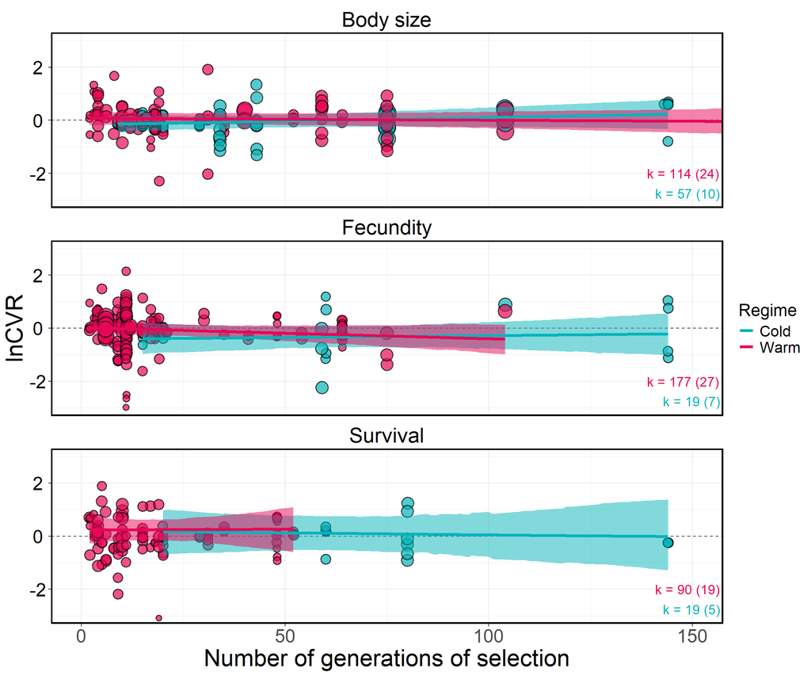

```r
# Generate predictions
emmeans_gen_selection <- as.data.frame(emmeans(
  lnCVR_model_gen_selection,
  specs = ~ gen_selection | trait_type * warm_cold,
  at = list(gen_selection = seq(min(data$gen_selection), max(data$gen_selection), by = 1),
            assay_temp_diff = 0))
  ) # Conditional effects on assay_temp_diff = 0


# Calculate range of values for each category
range_df <- data %>%
  group_by(trait_type, warm_cold) %>%
  summarize(
    min_gen_selection = min(gen_selection),
    max_gen_selection = max(gen_selection)
  )

emmeans_gen_selection$trait_type <- factor(emmeans_gen_selection$trait_type,
                          levels = c("body_size", "fecundity", "survival"),
                          labels = c("Body size", "Fecundity", "Survival"))

emmeans_gen_selection$warm_cold <- factor(emmeans_gen_selection$warm_cold,
                          levels = c("cold", "warm"),
                          labels = c("Cold", "Warm"))

# Tailor predictions to the range of the data
emmeans_gen_selection <- emmeans_gen_selection %>%
  left_join(range_df, by = c("trait_type", "warm_cold")) %>%
  filter(
    gen_selection >= min_gen_selection,
    gen_selection <= max_gen_selection
  )

# Plot
ggplot() +
    geom_hline(yintercept = 0, # Horizontal line
               linetype = 2,
               colour = "black",
               alpha = 0.75) +
    geom_point(data = data,  # Effect sizes, scaled by precision
                  aes(x = gen_selection,
                      y = lnCVR,
                      size = 1/sqrt(var_lnCVR),
                      fill = warm_cold),
                  shape = 21,
                  alpha = 0.7,
                  stroke = 1,
                  position = position_jitter(width = 0.05)) +
     geom_ribbon(data = emmeans_gen_selection, # Shaded area for credible intervals
                 aes(x = gen_selection,
                     ymin = lower.HPD,
                     ymax = upper.HPD,
                     fill = warm_cold,
                     group = warm_cold),
                 alpha = .5) +
     geom_line(data = emmeans_gen_selection, # Predicted regression line
               aes(y = emmean,
                   x = gen_selection,
                   color = warm_cold,
                   group = warm_cold),
               size = 1.5) +
     geom_text(data = sample_sizes,
              aes(x = Inf,
                  y = ifelse(warm_cold == "Warm", -2, -2.75),  # Sample sizes
                  label = paste0("k = ", estimates, " (", studies, ")"),
                  color = warm_cold),
              hjust = 1.05, size = 5, show.legend = FALSE) +
  facet_wrap(~ trait_type, ncol = 1) +  # Different panels for each trait
  scale_fill_manual(values = c("#06B4BA", "#E80756"))+
  scale_color_manual(values = c("#06B4BA", "#E80756"))+
  labs(x = "Number of generations of selection", y = "lnCVR", col = "Regime") +
  theme_bw() +
  scale_size_continuous(range = c(2, 8))+
  theme(text = element_text(size = 25, color = "black"),
          legend.title = ggplot2::element_text(size = 18),
          legend.text = ggplot2::element_text(size = 16),
          axis.text.y = ggplot2::element_text(size = 20,
                colour = "black", hjust = 0.5),
          axis.text.x = ggplot2::element_text(size = 20),
        panel.border = element_rect(color = "black", size = 1.5),
        strip.background = element_blank(),
        strip.text = element_text(color = "black", size = 22)) +
    guides(fill = "none", size = "none")+
    coord_cartesian(ylim = c(-3, 3),
                    xlim = c(0, 150))
```

```r
ggsave(file = "fig/lnCVR_gen_selection.png", width = 12, height = 7, dpi = 500)
```

### **Number of generations of common garden**

#### *Model specification*

```r
# Model specification
formula <- bf(lnCVR ~ 0 + trait_type:warm_cold +
                          trait_type:warm_cold:assay_temp_diff +
                          trait_type:warm_cold:scale(gen_common_garden) + # Separate effects by trait type
                (trait_type-1|ref) + # Correlation between traits among studies
                (1|species) + # Species-level random effect
                (1|gr(phylogeny, cov = phylo_matrix)) + # Phylogenetic relatedness
                (1|experiment_ID) + # Experiment-level random effect
                (1|obs) + # Observation-level random effect
                fcor(VCV_lnCVR)) # Variance covariance matix of correlated sampling variances

# Define priors
prior = c(
  prior(constant(1), class = "sigma")
) # Because the residual variance-covariance structure is specified in fcor, there is no need to estimate sigma so it is left as a constant

# Fit model
lnCVR_model_gen_common_garden <- brm(formula,
                                family = gaussian(),
                                data = data,
                                data2 = list(phylo_matrix = phylo_matrix,
                                             VCV_lnCVR = VCV_lnCVR),
                                prior = prior,
                                control = list(adapt_delta = 0.99, max_treedepth = 15),
                                iter = 4000,
                                warmup = 2000,
                                chains = 4,
                                cores = 4,
                                seed = 123)
# Save model
saveRDS(lnCVR_model_gen_common_garden, file = "RData/lnCVR_model_gen_common_garden.rds")
```

#### *Model output*

```r
# Load model
lnCVR_model_gen_common_garden <- readRDS("RData/lnCVR_model_gen_common_garden.rds")

# Display model output
summary(lnCVR_model_gen_common_garden)
```

```
##  Family: gaussian
##   Links: mu = identity; sigma = identity
## Formula: lnCVR ~ 0 + trait_type:warm_cold + trait_type:warm_cold:assay_temp_diff + trait_type:warm_cold:scale(gen_common_garden) + (trait_type - 1 | ref) + (1 | species) + (1 | gr(phylogeny, cov = phylo_matrix)) + (1 | experiment_ID) + (1 | obs) + fcor(VCV_lnCVR)
##    Data: data (Number of observations: 476)
##   Draws: 4 chains, each with iter = 4000; warmup = 2000; thin = 1;
##          total post-warmup draws = 8000
##
## Multilevel Hyperparameters:
## ~experiment_ID (Number of levels: 88)
##               Estimate Est.Error l-95% CI u-95% CI Rhat Bulk_ESS Tail_ESS
## sd(Intercept)     0.09      0.05     0.01     0.21 1.00     1293     2743
##
## ~obs (Number of levels: 476)
##               Estimate Est.Error l-95% CI u-95% CI Rhat Bulk_ESS Tail_ESS
## sd(Intercept)     0.40      0.04     0.33     0.48 1.00     2081     3793
##
## ~phylogeny (Number of levels: 25)
##               Estimate Est.Error l-95% CI u-95% CI Rhat Bulk_ESS Tail_ESS
## sd(Intercept)     0.10      0.08     0.00     0.29 1.00     2506     3222
##
## ~ref (Number of levels: 44)
##                                              Estimate Est.Error l-95% CI
## sd(trait_typebody_size)                          0.06      0.05     0.00
## sd(trait_typefecundity)                          0.10      0.08     0.00
## sd(trait_typesurvival)                           0.55      0.16     0.28
## cor(trait_typebody_size,trait_typefecundity)     0.05      0.49    -0.85
## cor(trait_typebody_size,trait_typesurvival)     -0.03      0.49    -0.88
## cor(trait_typefecundity,trait_typesurvival)     -0.04      0.45    -0.84
##                                              u-95% CI Rhat Bulk_ESS Tail_ESS
## sd(trait_typebody_size)                          0.18 1.00     3649     4252
## sd(trait_typefecundity)                          0.31 1.00     1538     2764
## sd(trait_typesurvival)                           0.90 1.00     3047     3663
## cor(trait_typebody_size,trait_typefecundity)     0.89 1.00     3297     5211
## cor(trait_typebody_size,trait_typesurvival)      0.87 1.01      938     2304
## cor(trait_typefecundity,trait_typesurvival)      0.83 1.00     1463     2653
##
## ~species (Number of levels: 25)
##               Estimate Est.Error l-95% CI u-95% CI Rhat Bulk_ESS Tail_ESS
## sd(Intercept)     0.06      0.05     0.00     0.19 1.00     2815     3543
##
```

[output cut: 51 more lines]

```
## trait_typesurvival:warm_coldwarm:assay_temp_diff             5295     5614
## trait_typebody_size:warm_coldcold:scalegen_common_garden     5230     5565
## trait_typefecundity:warm_coldcold:scalegen_common_garden     6984     5478
## trait_typesurvival:warm_coldcold:scalegen_common_garden      4118     5376
## trait_typebody_size:warm_coldwarm:scalegen_common_garden     5169     5857
## trait_typefecundity:warm_coldwarm:scalegen_common_garden     6263     6362
## trait_typesurvival:warm_coldwarm:scalegen_common_garden      4182     4925
##
## Further Distributional Parameters:
##       Estimate Est.Error l-95% CI u-95% CI Rhat Bulk_ESS Tail_ESS
## sigma     1.00      0.00     1.00     1.00   NA       NA       NA
##
## Draws were sampled using sampling(NUTS). For each parameter, Bulk_ESS
## and Tail_ESS are effective sample size measures, and Rhat is the potential
## scale reduction factor on split chains (at convergence, Rhat = 1).
```

```r
# R2
r2(lnCVR_model_gen_common_garden)
```

```
## # Bayesian R2 with Compatibility Interval
##
##   Conditional R2: 0.307 (95% CI [0.242, 0.373])
##      Marginal R2: 0.060 (95% CI [0.028, 0.101])
```

```r
# Cleaned model output
as.data.frame(fixef(lnCVR_model_gen_common_garden, summary = TRUE)) %>%
  # Rename categorical variables for cleaner display
  rownames_to_column(var = "Parameter") %>%
  mutate(
    # Simplify `trait_type` and `warm_cold` interactions
    Parameter = gsub("trait_type([a-z_]+):warm_cold(cold|warm)", "\\1(\\2)", Parameter),
    # Adjust for assay_temp_diff
    Parameter = gsub("trait_type([a-z_]+)\\((cold|warm)\\):assay_temp_diff", "\\1(\\2): assay_temp_diff", Parameter),
    # Remove "scale" from gen_common_garden
    Parameter = gsub("scalegen_common_garden", "gen_common_garden", Parameter)
  ) %>%
  # Round numbers to 3 decimal points
  mutate(across(c(Estimate, Q2.5, Q97.5), ~ round(., 3))) %>%
  select(Parameter, Estimate, `Lower CI` = Q2.5, `Upper CI` = Q97.5) %>%
  kable() %>%
  kable_styling(full_width = FALSE, position = "center", fixed_thead = TRUE) %>%
  column_spec(1, bold = TRUE, border_right = TRUE) %>%
  row_spec(0, background = "white", color = "black", bold = TRUE) %>%
  kable_styling(fixed_thead = TRUE)
```

| Parameter | Estimate | Lower CI | Upper CI |
| --- | --- | --- | --- |
| body_size(cold) | -0.014 | -0.245 | 0.242 |
| fecundity(cold) | -0.260 | -0.648 | 0.145 |
| survival(cold) | 0.124 | -0.500 | 0.759 |
| body_size(warm) | 0.043 | -0.162 | 0.265 |
| fecundity(warm) | -0.048 | -0.256 | 0.165 |
| survival(warm) | 0.244 | -0.138 | 0.634 |
| body_size(cold):assay_temp_diff | -0.008 | -0.049 | 0.035 |
| fecundity(cold):assay_temp_diff | -0.141 | -0.218 | -0.063 |
| survival(cold):assay_temp_diff | 0.027 | -0.048 | 0.104 |
| body_size(warm):assay_temp_diff | 0.001 | -0.032 | 0.036 |
| fecundity(warm):assay_temp_diff | 0.018 | -0.014 | 0.049 |
| survival(warm):assay_temp_diff | -0.026 | -0.075 | 0.023 |
| body_size(cold):gen_common_garden | -0.041 | -1.000 | 0.917 |
| fecundity(cold):gen_common_garden | 0.290 | -1.362 | 2.000 |
| survival(cold):gen_common_garden | 0.021 | -1.795 | 1.866 |
| body_size(warm):gen_common_garden | -0.314 | -1.079 | 0.466 |
| fecundity(warm):gen_common_garden | -0.022 | -0.079 | 0.035 |
| survival(warm):gen_common_garden | 0.046 | -1.608 | 1.627 |

#### *Data visualisation*

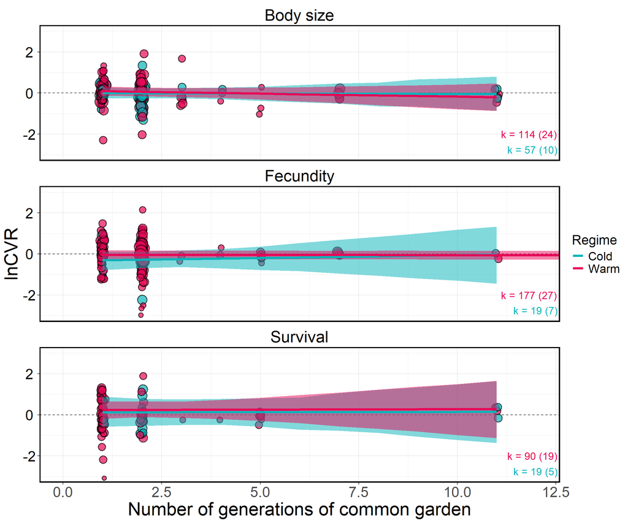

```r
# Generate predictions
emmeans_gen_common_garden <- as.data.frame(emmeans(
  lnCVR_model_gen_common_garden,
  specs = ~ gen_common_garden | trait_type * warm_cold,
  at = list(gen_common_garden = seq(min(data$gen_common_garden), max(data$gen_common_garden), by = 1),
            assay_temp_diff = 0))
  ) # Conditional effects on assay_temp_diff = 0

# Calculate range of values for each category
range_df <- data %>%
  group_by(trait_type, warm_cold) %>%
  summarize(
    min_gen_common_garden = min(gen_common_garden),
    max_gen_common_garden = max(gen_common_garden)
  )

emmeans_gen_common_garden$trait_type <- factor(emmeans_gen_common_garden$trait_type,
                          levels = c("body_size", "fecundity", "survival"),
                          labels = c("Body size", "Fecundity", "Survival"))

emmeans_gen_common_garden$warm_cold <- factor(emmeans_gen_common_garden$warm_cold,
                          levels = c("cold", "warm"),
                          labels = c("Cold", "Warm"))

# Tailor predictions to the range of the data
emmeans_gen_common_garden <- emmeans_gen_common_garden %>%
  left_join(range_df, by = c("trait_type", "warm_cold")) %>%
  filter(
    gen_common_garden >= min_gen_common_garden,
    gen_common_garden <= max_gen_common_garden
  )

# Plot
ggplot() +
    geom_hline(yintercept = 0, # Horizontal line
               linetype = 2,
               colour = "black",
               alpha = 0.75) +
    geom_point(data = data,  # Effect sizes, scaled by precision
                  aes(x = gen_common_garden,
                      y = lnCVR,
                      size = 1/sqrt(var_lnCVR),
                      fill = warm_cold),
                  shape = 21,
                  alpha = 0.7,
                  stroke = 1,
                  position = position_jitter(width = 0.05)) +
     geom_ribbon(data = emmeans_gen_common_garden, # Shaded area for credible intervals
                 aes(x = gen_common_garden,
                     ymin = lower.HPD,
                     ymax = upper.HPD,
                     fill = warm_cold,
                     group = warm_cold),
                 alpha = .5) +
     geom_line(data = emmeans_gen_common_garden, # Predicted regression line
               aes(y = emmean,
                   x = gen_common_garden,
                   color = warm_cold,
                   group = warm_cold),
               size = 1.5) +
     geom_text(data = sample_sizes,
              aes(x = Inf,
                  y = ifelse(warm_cold == "Warm", -2, -2.75),  # Sample sizes
                  label = paste0("k = ", estimates, " (", studies, ")"),
                  color = warm_cold),
              hjust = 1.05, size = 5, show.legend = FALSE) +
  facet_wrap(~ trait_type, ncol = 1) +  # Different panels for each trait
  scale_fill_manual(values = c("#06B4BA", "#E80756"))+
  scale_color_manual(values = c("#06B4BA", "#E80756"))+
  labs(x = "Number of generations of common garden", y = "lnCVR", col = "Regime") +
  theme_bw() +
  scale_size_continuous(range = c(2, 8))+
  theme(text = element_text(size = 25, color = "black"),
          legend.title = ggplot2::element_text(size = 18),
          legend.text = ggplot2::element_text(size = 16),
          axis.text.y = ggplot2::element_text(size = 20,
                colour = "black", hjust = 0.5),
          axis.text.x = ggplot2::element_text(size = 20),
        panel.border = element_rect(color = "black", size = 1.5),
        strip.background = element_blank(),
        strip.text = element_text(color = "black", size = 22)) +
    guides(fill = "none", size = "none")+
    coord_cartesian(ylim = c(-3, 3),
                    xlim = c(0, 12))
```

```r
ggsave(file = "fig/lnCVR_gen_common_garden.png", width = 12, height = 7, dpi = 500)
```

### **Population size**

#### *Model specification*

```r
# Model specification
formula <- bf(lnCVR ~ 0 + trait_type:warm_cold +
                          trait_type:warm_cold:assay_temp_diff +
                          trait_type:warm_cold:scale(pop_size) + # Separate effects by trait type
                (trait_type-1|ref) + # Correlation between traits among studies
                (1|species) + # Species-level random effect
                (1|gr(phylogeny, cov = phylo_matrix)) + # Phylogenetic relatedness
                (1|experiment_ID) + # Experiment-level random effect
                (1|obs) + # Observation-level random effect
                fcor(VCV_lnCVR)) # Variance covariance matix of correlated sampling variances

# Define priors
prior = c(
  prior(constant(1), class = "sigma")
) # Because the residual variance-covariance structure is specified in fcor, there is no need to estimate sigma so it is left as a constant

# Fit model
lnCVR_model_pop_size <- brm(formula,
                                family = gaussian(),
                                data = data,
                                data2 = list(phylo_matrix = phylo_matrix,
                                             VCV_lnCVR = VCV_lnCVR),
                                prior = prior,
                                control = list(adapt_delta = 0.99, max_treedepth = 15),
                                iter = 4000,
                                warmup = 2000,
                                chains = 4,
                                cores = 4,
                                seed = 123)
# Save model
saveRDS(lnCVR_model_pop_size, file = "RData/lnCVR_model_pop_size.rds")
```

#### *Model output*

```r
# Load model
lnCVR_model_pop_size <- readRDS("RData/lnCVR_model_pop_size.rds")

# Display model output
summary(lnCVR_model_pop_size)
```

```
##  Family: gaussian
##   Links: mu = identity; sigma = identity
## Formula: lnCVR ~ 0 + trait_type:warm_cold + trait_type:warm_cold:assay_temp_diff + trait_type:warm_cold:scale(pop_size) + (trait_type - 1 | ref) + (1 | species) + (1 | gr(phylogeny, cov = phylo_matrix)) + (1 | experiment_ID) + (1 | obs) + fcor(VCV_lnCVR)
##    Data: data (Number of observations: 426)
##   Draws: 4 chains, each with iter = 4000; warmup = 2000; thin = 1;
##          total post-warmup draws = 8000
##
## Multilevel Hyperparameters:
## ~experiment_ID (Number of levels: 79)
##               Estimate Est.Error l-95% CI u-95% CI Rhat Bulk_ESS Tail_ESS
## sd(Intercept)     0.08      0.05     0.00     0.19 1.00     1928     3870
##
## ~obs (Number of levels: 426)
##               Estimate Est.Error l-95% CI u-95% CI Rhat Bulk_ESS Tail_ESS
## sd(Intercept)     0.26      0.03     0.20     0.32 1.00     3563     4726
##
## ~phylogeny (Number of levels: 22)
##               Estimate Est.Error l-95% CI u-95% CI Rhat Bulk_ESS Tail_ESS
## sd(Intercept)     0.09      0.08     0.00     0.28 1.00     3836     5030
##
## ~ref (Number of levels: 41)
##                                              Estimate Est.Error l-95% CI
## sd(trait_typebody_size)                          0.07      0.06     0.00
## sd(trait_typefecundity)                          0.17      0.10     0.01
## sd(trait_typesurvival)                           0.31      0.13     0.06
## cor(trait_typebody_size,trait_typefecundity)    -0.01      0.48    -0.86
## cor(trait_typebody_size,trait_typesurvival)     -0.07      0.48    -0.88
## cor(trait_typefecundity,trait_typesurvival)      0.09      0.48    -0.82
##                                              u-95% CI Rhat Bulk_ESS Tail_ESS
## sd(trait_typebody_size)                          0.21 1.00     3844     4628
## sd(trait_typefecundity)                          0.40 1.00     1859     3255
## sd(trait_typesurvival)                           0.59 1.00     2879     1949
## cor(trait_typebody_size,trait_typefecundity)     0.87 1.00     3526     5348
## cor(trait_typebody_size,trait_typesurvival)      0.84 1.00     2377     4567
## cor(trait_typefecundity,trait_typesurvival)      0.90 1.00     3260     5476
##
## ~species (Number of levels: 22)
##               Estimate Est.Error l-95% CI u-95% CI Rhat Bulk_ESS Tail_ESS
## sd(Intercept)     0.07      0.06     0.00     0.22 1.00     3810     5167
##
```

[output cut: 51 more lines]

```
## trait_typesurvival:warm_coldwarm:assay_temp_diff      6555
## trait_typebody_size:warm_coldcold:scalepop_size       5270
## trait_typefecundity:warm_coldcold:scalepop_size       5760
## trait_typesurvival:warm_coldcold:scalepop_size        6860
## trait_typebody_size:warm_coldwarm:scalepop_size       6336
## trait_typefecundity:warm_coldwarm:scalepop_size       5785
## trait_typesurvival:warm_coldwarm:scalepop_size        5831
##
## Further Distributional Parameters:
##       Estimate Est.Error l-95% CI u-95% CI Rhat Bulk_ESS Tail_ESS
## sigma     1.00      0.00     1.00     1.00   NA       NA       NA
##
## Draws were sampled using sampling(NUTS). For each parameter, Bulk_ESS
## and Tail_ESS are effective sample size measures, and Rhat is the potential
## scale reduction factor on split chains (at convergence, Rhat = 1).
```

```r
# R2
r2(lnCVR_model_pop_size)
```

```
## # Bayesian R2 with Compatibility Interval
##
##   Conditional R2: 0.326 (95% CI [0.256, 0.398])
##      Marginal R2: 0.109 (95% CI [0.058, 0.166])
```

```r
# Cleaned model output
as.data.frame(fixef(lnCVR_model_pop_size, summary = TRUE)) %>%
  # Rename categorical variables for cleaner display
  rownames_to_column(var = "Parameter") %>%
  mutate(
    # Simplify `trait_type` and `warm_cold` interactions
    Parameter = gsub("trait_type([a-z_]+):warm_cold(cold|warm)", "\\1(\\2)", Parameter),
    # Adjust for assay_temp_diff
    Parameter = gsub("trait_type([a-z_]+)\\((cold|warm)\\):assay_temp_diff", "\\1(\\2): assay_temp_diff", Parameter),
    # Remove "scale" from pop_size
    Parameter = gsub("scalepop_size", "pop_size", Parameter)
  ) %>%
  # Round numbers to 3 decimal points
  mutate(across(c(Estimate, Q2.5, Q97.5), ~ round(., 3))) %>%
  select(Parameter, Estimate, `Lower CI` = Q2.5, `Upper CI` = Q97.5) %>%
  kable() %>%
  kable_styling(full_width = FALSE, position = "center", fixed_thead = TRUE) %>%
  column_spec(1, bold = TRUE, border_right = TRUE) %>%
  row_spec(0, background = "white", color = "black", bold = TRUE) %>%
  kable_styling(fixed_thead = TRUE)
```

| Parameter | Estimate | Lower CI | Upper CI |
| --- | --- | --- | --- |
| body_size(cold) | 0.018 | -0.211 | 0.256 |
| fecundity(cold) | -0.116 | -0.503 | 0.278 |
| survival(cold) | 0.050 | -0.439 | 0.543 |
| body_size(warm) | -0.007 | -0.211 | 0.201 |
| fecundity(warm) | 0.003 | -0.219 | 0.220 |
| survival(warm) | 0.011 | -0.282 | 0.315 |
| body_size(cold):assay_temp_diff | 0.007 | -0.028 | 0.043 |
| fecundity(cold):assay_temp_diff | -0.119 | -0.191 | -0.048 |
| survival(cold):assay_temp_diff | 0.028 | -0.038 | 0.094 |
| body_size(warm):assay_temp_diff | 0.008 | -0.021 | 0.037 |
| fecundity(warm):assay_temp_diff | -0.011 | -0.041 | 0.020 |
| survival(warm):assay_temp_diff | 0.001 | -0.042 | 0.042 |
| body_size(cold):pop_size | -0.119 | -0.267 | 0.026 |
| fecundity(cold):pop_size | -0.166 | -0.472 | 0.160 |
| survival(cold):pop_size | -0.055 | -0.527 | 0.417 |
| body_size(warm):pop_size | -0.005 | -0.102 | 0.092 |
| fecundity(warm):pop_size | -0.072 | -0.217 | 0.069 |
| survival(warm):pop_size | -0.086 | -0.301 | 0.137 |

#### *Data visualisation*

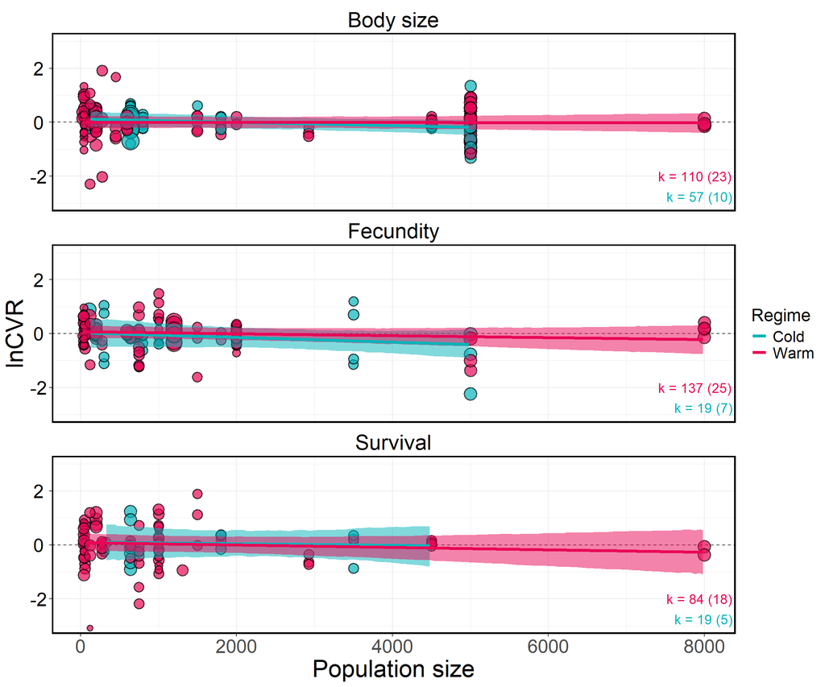

```r
# Generate predictions
emmeans_pop_size <- as.data.frame(emmeans(
  lnCVR_model_pop_size,
  specs = ~ pop_size | trait_type * warm_cold,
  at = list(pop_size = seq(min(data$pop_size, na.rm=T), max(data$pop_size, na.rm=T), by = 50),
            assay_temp_diff = 0))
  ) # Conditional effects on assay_temp_diff = 0

# Calculate range of values for each category
range_df <- data %>%
  group_by(trait_type, warm_cold) %>%
  summarize(
    min_pop_size = min(pop_size, na.rm=T),
    max_pop_size = max(pop_size, na.rm=T)
  )

emmeans_pop_size$trait_type <- factor(emmeans_pop_size$trait_type,
                          levels = c("body_size", "fecundity", "survival"),
                          labels = c("Body size", "Fecundity", "Survival"))

emmeans_pop_size$warm_cold <- factor(emmeans_pop_size$warm_cold,
                          levels = c("cold", "warm"),
                          labels = c("Cold", "Warm"))

# Tailor predictions to the range of the data
emmeans_pop_size <- emmeans_pop_size %>%
  left_join(range_df, by = c("trait_type", "warm_cold")) %>%
  filter(
    pop_size >= min_pop_size,
    pop_size <= max_pop_size
  )

# Calculate sample sizes and study counts for population size
sample_sizes_pop_size <- data %>%
  filter(is.na(pop_size)==FALSE) %>%
  group_by(trait_type, warm_cold) %>%
  summarise(
    estimates = n(),
    studies = n_distinct(ref)
  )

# Plot
ggplot() +
    geom_hline(yintercept = 0, # Horizontal line
               linetype = 2,
               colour = "black",
               alpha = 0.75) +
    geom_point(data = data,  # Effect sizes, scaled by precision
                  aes(x = pop_size,
                      y = lnCVR,
                      size = 1/sqrt(var_lnCVR),
                      fill = warm_cold),
                  shape = 21,
                  alpha = 0.7,
                  stroke = 1,
                  position = position_jitter(width = 0.05)) +
     geom_ribbon(data = emmeans_pop_size, # Shaded area for credible intervals
                 aes(x = pop_size,
                     ymin = lower.HPD,
                     ymax = upper.HPD,
                     fill = warm_cold,
                     group = warm_cold),
                 alpha = .5) +
     geom_line(data = emmeans_pop_size, # Predicted regression line
               aes(y = emmean,
                   x = pop_size,
                   color = warm_cold,
                   group = warm_cold),
               size = 1.5) +
     geom_text(data = sample_sizes_pop_size,
              aes(x = Inf,
                  y = ifelse(warm_cold == "Warm", -2, -2.75),  # Sample sizes
                  label = paste0("k = ", estimates, " (", studies, ")"),
                  color = warm_cold),
              hjust = 1.05, size = 5, show.legend = FALSE) +
  facet_wrap(~ trait_type, ncol = 1) +  # Different panels for each trait
  scale_fill_manual(values = c("#06B4BA", "#E80756"))+
  scale_color_manual(values = c("#06B4BA", "#E80756"))+
  labs(x = "Population size", y = "lnCVR", col = "Regime") +
  theme_bw() +
  scale_size_continuous(range = c(2, 8))+
  theme(text = element_text(size = 25, color = "black"),
          legend.title = ggplot2::element_text(size = 18),
          legend.text = ggplot2::element_text(size = 16),
          axis.text.y = ggplot2::element_text(size = 20,
                colour = "black", hjust = 0.5),
          axis.text.x = ggplot2::element_text(size = 20),
        panel.border = element_rect(color = "black", size = 1.5),
        strip.background = element_blank(),
        strip.text = element_text(color = "black", size = 22)) +
    guides(fill = "none", size = "none")+
    coord_cartesian(ylim = c(-3, 3))
```

```r
ggsave(file = "fig/lnCVR_pop_size.png", width = 12, height = 7, dpi = 500)
```

### **All moderators**

#### *Model specification*

```r
# Model specification
formula <- bf(lnCVR ~ 0 + trait_type:warm_cold +
                trait_type:warm_cold:assay_temp_diff +
                trait_type:warm_cold:scale(select_temp_diff) +
                trait_type:warm_cold:scale(gen_selection) +
                trait_type:warm_cold:scale(gen_common_garden) + # Separate effects by trait type
                (trait_type-1|ref) + # Correlation between traits among studies
                (1|species) + # Species-level random effect
                (1|gr(phylogeny, cov = phylo_matrix)) + # Phylogenetic relatedness
                (1|experiment_ID) + # Experiment-level random effect
                (1|obs) + # Observation-level random effect
                fcor(VCV_lnCVR)) # Variance covariance matix of correlated sampling variances

# Define priors
prior = c(
  prior(constant(1), class = "sigma")
) # Because the residual variance-covariance structure is specified in fcor, there is no need to estimate sigma so it is left as a constant

# Fit model
lnCVR_model_all_moderators <- brm(formula,
                                  family = gaussian(),
                                  data = data,
                                  data2 = list(phylo_matrix = phylo_matrix,
                                               VCV_lnCVR = VCV_lnCVR),
                                  prior = prior,
                                  control = list(adapt_delta = 0.99, max_treedepth = 15),
                                  iter = 4000,
                                  warmup = 2000,
                                  chains = 4,
                                  cores = 4,
                                  seed = 123)

# Save model
saveRDS(lnCVR_model_all_moderators, file = "RData/lnCVR_model_all_moderators.rds")
```

#### *Model output*

```r
# Load model
lnCVR_model_all_moderators <- readRDS("RData/lnCVR_model_all_moderators.rds")

# Display model output
summary(lnCVR_model_all_moderators)
```

```
##  Family: gaussian
##   Links: mu = identity; sigma = identity
## Formula: lnCVR ~ 0 + trait_type:warm_cold + trait_type:warm_cold:assay_temp_diff + trait_type:warm_cold:scale(select_temp_diff) + trait_type:warm_cold:scale(gen_selection) + trait_type:warm_cold:scale(gen_common_garden) + (trait_type - 1 | ref) + (1 | species) + (1 | gr(phylogeny, cov = phylo_mat…
##    Data: data (Number of observations: 476)
##   Draws: 4 chains, each with iter = 4000; warmup = 2000; thin = 1;
##          total post-warmup draws = 8000
##
## Multilevel Hyperparameters:
## ~experiment_ID (Number of levels: 88)
##               Estimate Est.Error l-95% CI u-95% CI Rhat Bulk_ESS Tail_ESS
## sd(Intercept)     0.10      0.06     0.01     0.22 1.00     1377     3121
##
## ~obs (Number of levels: 476)
##               Estimate Est.Error l-95% CI u-95% CI Rhat Bulk_ESS Tail_ESS
## sd(Intercept)     0.40      0.04     0.32     0.48 1.00     2187     4271
##
## ~phylogeny (Number of levels: 25)
##               Estimate Est.Error l-95% CI u-95% CI Rhat Bulk_ESS Tail_ESS
## sd(Intercept)     0.10      0.08     0.00     0.29 1.00     4220     4874
##
## ~ref (Number of levels: 44)
##                                              Estimate Est.Error l-95% CI
## sd(trait_typebody_size)                          0.07      0.05     0.00
## sd(trait_typefecundity)                          0.12      0.10     0.00
## sd(trait_typesurvival)                           0.67      0.20     0.34
## cor(trait_typebody_size,trait_typefecundity)     0.01      0.50    -0.88
## cor(trait_typebody_size,trait_typesurvival)     -0.01      0.50    -0.88
## cor(trait_typefecundity,trait_typesurvival)     -0.01      0.45    -0.84
##                                              u-95% CI Rhat Bulk_ESS Tail_ESS
## sd(trait_typebody_size)                          0.20 1.00     4609     4688
## sd(trait_typefecundity)                          0.36 1.00     1890     3738
## sd(trait_typesurvival)                           1.12 1.00     2811     4651
## cor(trait_typebody_size,trait_typefecundity)     0.87 1.00     4835     5800
## cor(trait_typebody_size,trait_typesurvival)      0.88 1.00     1376     3874
## cor(trait_typefecundity,trait_typesurvival)      0.83 1.00     1920     3925
##
## ~species (Number of levels: 25)
##               Estimate Est.Error l-95% CI u-95% CI Rhat Bulk_ESS Tail_ESS
## sd(Intercept)     0.06      0.05     0.00     0.19 1.00     4809     5078
##
```

[output cut: 87 more lines]

```
## trait_typesurvival:warm_coldwarm:scalegen_selection          5684     4810
## trait_typebody_size:warm_coldcold:scalegen_common_garden    10553     7087
## trait_typefecundity:warm_coldcold:scalegen_common_garden    10086     6398
## trait_typesurvival:warm_coldcold:scalegen_common_garden      5725     5479
## trait_typebody_size:warm_coldwarm:scalegen_common_garden     9508     6315
## trait_typefecundity:warm_coldwarm:scalegen_common_garden     9450     6865
## trait_typesurvival:warm_coldwarm:scalegen_common_garden      8083     6912
##
## Further Distributional Parameters:
##       Estimate Est.Error l-95% CI u-95% CI Rhat Bulk_ESS Tail_ESS
## sigma     1.00      0.00     1.00     1.00   NA       NA       NA
##
## Draws were sampled using sampling(NUTS). For each parameter, Bulk_ESS
## and Tail_ESS are effective sample size measures, and Rhat is the potential
## scale reduction factor on split chains (at convergence, Rhat = 1).
```

```r
# R2
r2(lnCVR_model_all_moderators)
```

```
## # Bayesian R2 with Compatibility Interval
##
##   Conditional R2: 0.323 (95% CI [0.256, 0.385])
##      Marginal R2: 0.106 (95% CI [0.060, 0.176])
```

```r
# Cleaned model output
as.data.frame(fixef(lnCVR_model_all_moderators, summary = TRUE)) %>%
  # Rename categorical variables for cleaner display
  rownames_to_column(var = "Parameter") %>%
  mutate(
    # Simplify `trait_type` and `warm_cold` interactions
    Parameter = gsub("trait_type([a-z_]+):warm_cold(cold|warm)", "\\1(\\2)", Parameter),
    # Adjust for assay_temp_diff
    Parameter = gsub("trait_type([a-z_]+)\\((cold|warm)\\):assay_temp_diff", "\\1(\\2): assay_temp_diff", Parameter),
    # Remove "scale" from all moderator variables
    Parameter = gsub("scale", "", Parameter)
  ) %>%
  # Round numbers to 3 decimal points
  mutate(across(c(Estimate, Q2.5, Q97.5), ~ round(., 3))) %>%
  select(Parameter, Estimate, `Lower CI` = Q2.5, `Upper CI` = Q97.5) %>%
  kable() %>%
  kable_styling(full_width = FALSE, position = "center", fixed_thead = TRUE) %>%
  column_spec(1, bold = TRUE, border_right = TRUE) %>%
  row_spec(0, background = "white", color = "black", bold = TRUE) %>%
  kable_styling(fixed_thead = TRUE)
```

| Parameter | Estimate | Lower CI | Upper CI |
| --- | --- | --- | --- |
| body_size(cold) | -0.090 | -0.344 | 0.182 |
| fecundity(cold) | -0.399 | -0.930 | 0.142 |
| survival(cold) | 0.223 | -0.918 | 1.350 |
| body_size(warm) | -0.017 | -0.243 | 0.214 |
| fecundity(warm) | -0.119 | -0.364 | 0.133 |
| survival(warm) | 0.265 | -0.278 | 0.813 |
| body_size(cold):assay_temp_diff | 0.006 | -0.038 | 0.053 |
| fecundity(cold):assay_temp_diff | -0.138 | -0.226 | -0.051 |
| survival(cold):assay_temp_diff | 0.030 | -0.050 | 0.110 |
| body_size(warm):assay_temp_diff | 0.015 | -0.022 | 0.054 |
| fecundity(warm):assay_temp_diff | 0.024 | -0.009 | 0.057 |
| survival(warm):assay_temp_diff | -0.025 | -0.076 | 0.026 |
| body_size(cold):select_temp_diff | 0.102 | -0.153 | 0.370 |
| fecundity(cold):select_temp_diff | 0.004 | -0.506 | 0.511 |
| survival(cold):select_temp_diff | 0.117 | -2.070 | 2.265 |
| body_size(warm):select_temp_diff | -0.149 | -0.325 | 0.027 |
| fecundity(warm):select_temp_diff | -0.060 | -0.278 | 0.147 |
| survival(warm):select_temp_diff | -0.085 | -0.481 | 0.261 |
| body_size(cold):gen_selection | 0.069 | -0.126 | 0.269 |
| fecundity(cold):gen_selection | 0.088 | -0.258 | 0.420 |
| survival(cold):gen_selection | -0.130 | -1.072 | 0.824 |
| body_size(warm):gen_selection | -0.042 | -0.164 | 0.079 |
| fecundity(warm):gen_selection | -0.122 | -0.359 | 0.118 |
| survival(warm):gen_selection | 0.047 | -0.898 | 0.971 |
| body_size(cold):gen_common_garden | -0.063 | -1.147 | 0.997 |
| fecundity(cold):gen_common_garden | 0.508 | -1.400 | 2.428 |
| survival(cold):gen_common_garden | -0.334 | -3.426 | 2.647 |
| body_size(warm):gen_common_garden | -0.236 | -1.020 | 0.562 |
| fecundity(warm):gen_common_garden | -0.011 | -0.073 | 0.051 |
| survival(warm):gen_common_garden | 0.038 | -1.822 | 1.914 |

```r
# Generate predicted values at different assay temperatures
emmeans_full_model <- as.data.frame(emmeans(
  lnCVR_model_all_moderators,
  specs = ~ assay_temp_diff * select_temp_diff * gen_selection * gen_common_garden | trait_type * warm_cold,
  at = list(assay_temp_diff = c(-8.5, -4, 0, 4, 5, -5, 17, 20)) # Predict at unique min, control, max values
))

# Calculate range of values for each category
range_df <- data %>%
  group_by(trait_type, warm_cold) %>%
  summarize(
    min_assay = min(assay_temp_diff),
    max_assay = max(assay_temp_diff),
    control_assay = 0
  )

emmeans_full_model$trait_type <- factor(emmeans_full_model$trait_type,
                          levels = c("body_size", "fecundity", "survival"),
                          labels = c("Body size", "Fecundity", "Survival"))

emmeans_full_model$warm_cold <- factor(emmeans_full_model$warm_cold,
                          levels = c("cold", "warm"),
                          labels = c("Cold", "Warm"))

# Tailor predictions to the range of the data
emmeans_full_model %>%
  left_join(range_df, by = c("trait_type", "warm_cold")) %>%
  filter(
    assay_temp_diff == min_assay |
    assay_temp_diff == max_assay |
    assay_temp_diff == control_assay) %>%
    dplyr::select(-min_assay, -max_assay, -control_assay) %>%
    mutate(percentage_change = (exp(emmean) - 1) * 100,
           percentage_lower_HPD = (exp(lower.HPD) - 1) * 100,
           percentage_upper_HPD = (exp(upper.HPD) - 1) * 100) %>%
  mutate(across(c(emmean,
                  lower.HPD,
                  upper.HPD,
                  percentage_change,
                  percentage_lower_HPD,
                  percentage_upper_HPD), ~ round(., 3))) %>%   # Round numbers to 3 decimal points
  kable() %>%
  kable_styling(full_width = FALSE, position = "center", fixed_thead = TRUE) %>%
  column_spec(1, bold = TRUE, border_right = TRUE) %>%
  row_spec(0, background = "white", color = "black", bold = TRUE) %>%
  kable_styling(fixed_thead = TRUE)
```

| assay_temp_diff | select_temp_diff | gen_selection | gen_common_garden | trait_type | warm_cold | emmean | lower.HPD | upper.HPD | percentage_change | percentage_lower_HPD | percentage_upper_HPD |
| --- | --- | --- | --- | --- | --- | --- | --- | --- | --- | --- | --- |
| -8.5 | 5.64645 | 29.0084 | 2.710084 | Body size | Cold | -0.140 | -0.594 | 0.329 | -13.104 | -44.796 | 38.892 |
| 0.0 | 5.64645 | 29.0084 | 2.710084 | Body size | Cold | -0.092 | -0.349 | 0.172 | -8.758 | -29.473 | 18.818 |
| 5.0 | 5.64645 | 29.0084 | 2.710084 | Body size | Cold | -0.062 | -0.417 | 0.278 | -6.047 | -34.070 | 31.988 |
| -8.5 | 5.64645 | 29.0084 | 2.710084 | Fecundity | Cold | 0.767 | -0.165 | 1.688 | 115.263 | -15.191 | 440.604 |
| 0.0 | 5.64645 | 29.0084 | 2.710084 | Fecundity | Cold | -0.400 | -0.941 | 0.125 | -32.991 | -60.993 | 13.367 |
| 5.0 | 5.64645 | 29.0084 | 2.710084 | Fecundity | Cold | -1.090 | -1.785 | -0.435 | -66.371 | -83.222 | -35.277 |
| -8.5 | 5.64645 | 29.0084 | 2.710084 | Survival | Cold | -0.036 | -1.311 | 1.247 | -3.495 | -73.041 | 248.077 |
| 0.0 | 5.64645 | 29.0084 | 2.710084 | Survival | Cold | 0.222 | -0.910 | 1.353 | 24.911 | -59.739 | 286.737 |
| 4.0 | 5.64645 | 29.0084 | 2.710084 | Survival | Cold | 0.344 | -0.824 | 1.561 | 40.996 | -56.111 | 376.140 |
| 0.0 | 5.64645 | 29.0084 | 2.710084 | Body size | Warm | -0.019 | -0.245 | 0.211 | -1.860 | -21.713 | 23.475 |
| -5.0 | 5.64645 | 29.0084 | 2.710084 | Body size | Warm | -0.092 | -0.450 | 0.243 | -8.819 | -36.239 | 27.506 |
| 17.0 | 5.64645 | 29.0084 | 2.710084 | Body size | Warm | 0.235 | -0.342 | 0.815 | 26.499 | -28.962 | 125.950 |
| -4.0 | 5.64645 | 29.0084 | 2.710084 | Fecundity | Warm | -0.215 | -0.545 | 0.117 | -19.318 | -42.019 | 12.451 |
| 0.0 | 5.64645 | 29.0084 | 2.710084 | Fecundity | Warm | -0.122 | -0.369 | 0.126 | -11.486 | -30.832 | 13.427 |
| 20.0 | 5.64645 | 29.0084 | 2.710084 | Fecundity | Warm | 0.357 | -0.227 | 0.938 | 42.928 | -20.273 | 155.540 |
| 0.0 | 5.64645 | 29.0084 | 2.710084 | Survival | Warm | 0.260 | -0.297 | 0.790 | 29.726 | -25.718 | 120.370 |
| -5.0 | 5.64645 | 29.0084 | 2.710084 | Survival | Warm | 0.385 | -0.268 | 1.036 | 46.921 | -23.532 | 181.703 |
| 17.0 | 5.64645 | 29.0084 | 2.710084 | Survival | Warm | -0.160 | -1.057 | 0.798 | -14.760 | -65.256 | 122.177 |

#### *Data visualisation*

**Marginal means**

```r
# Generate predictions at assay_temp_diff = 0, or 5 degrees below or above the control temperatures
emmeans_full_model <- as.data.frame(emmeans(
  lnCVR_model_all_moderators,
  specs = ~ assay_temp_diff * select_temp_diff * gen_selection * gen_common_garden | trait_type * warm_cold,
  at = list(assay_temp_diff = c(-5, 0, 5) # Re-acclimated to control, or 5 degrees above/below the contol
  )))

# Rename variable levels
emmeans_full_model$trait_type <- factor(emmeans_full_model$trait_type,
                          levels = c("body_size", "fecundity", "survival"),
                          labels = c("Body size", "Fecundity", "Survival"))

emmeans_full_model$warm_cold <- factor(emmeans_full_model$warm_cold,
                          levels = c("cold", "warm"),
                          labels = c("Cold", "Warm"))
emmeans_full_model
```

```
## trait_type = Body size, warm_cold = Cold:
##  assay_temp_diff select_temp_diff gen_selection gen_common_garden     emmean
##               -5          5.64645       29.0084          2.710084 -0.1213345
##                0          5.64645       29.0084          2.710084 -0.0916597
##                5          5.64645       29.0084          2.710084 -0.0623747
##   lower.HPD  upper.HPD
##  -0.4517610  0.2373984
##  -0.3491781  0.1724248
##  -0.4165708  0.2775442
##
## trait_type = Fecundity, warm_cold = Cold:
##  assay_temp_diff select_temp_diff gen_selection gen_common_garden     emmean
##               -5          5.64645       29.0084          2.710084  0.2833302
##                0          5.64645       29.0084          2.710084 -0.4003454
##                5          5.64645       29.0084          2.710084 -1.0897919
##   lower.HPD  upper.HPD
##  -0.3821255  1.0269214
##  -0.9414361  0.1254571
##  -1.7851123 -0.4350608
##
## trait_type = Survival, warm_cold = Cold:
##  assay_temp_diff select_temp_diff gen_selection gen_common_garden     emmean
##               -5          5.64645       29.0084          2.710084  0.0695553
##                0          5.64645       29.0084          2.710084  0.2224342
##                5          5.64645       29.0084          2.710084  0.3717481
##   lower.HPD  upper.HPD
##  -1.1210984  1.2306247
##  -0.9097910  1.3525739
##  -0.8646504  1.5842286
##
## trait_type = Body size, warm_cold = Warm:
##  assay_temp_diff select_temp_diff gen_selection gen_common_garden     emmean
##               -5          5.64645       29.0084          2.710084 -0.0923210
##                0          5.64645       29.0084          2.710084 -0.0187716
##                5          5.64645       29.0084          2.710084  0.0562653
##   lower.HPD  upper.HPD
##  -0.4500300  0.2429957
##  -0.2447877  0.2108647
##  -0.1755918  0.2826457
##
## trait_type = Fecundity, warm_cold = Warm:
##  assay_temp_diff select_temp_diff gen_selection gen_common_garden     emmean
##               -5          5.64645       29.0084          2.710084 -0.2383308
##                0          5.64645       29.0084          2.710084 -0.1220054
##                5          5.64645       29.0084          2.710084 -0.0030450
##   lower.HPD  upper.HPD
##  -0.5884738  0.1208489
##  -0.3686250  0.1259859
##  -0.2146602  0.2373331
##
## trait_type = Survival, warm_cold = Warm:
##  assay_temp_diff select_temp_diff gen_selection gen_common_garden     emmean
##               -5          5.64645       29.0084          2.710084  0.3847272
##                0          5.64645       29.0084          2.710084  0.2602578
##                5          5.64645       29.0084          2.710084  0.1414285
##   lower.HPD  upper.HPD
##  -0.2682933  1.0356829
##  -0.2973033  0.7901396
##  -0.4144538  0.6911635
##
## Point estimate displayed: median
## HPD interval probability: 0.95
```

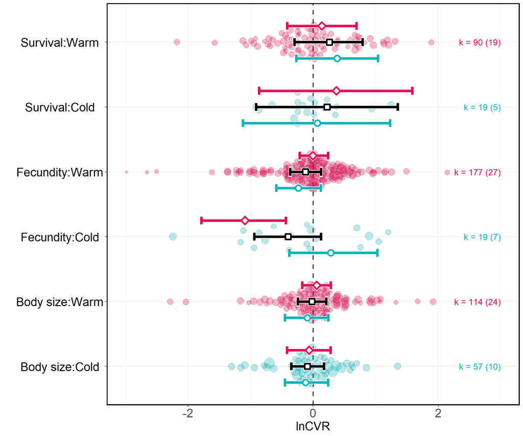

```r
# Plot
ggplot() +
    geom_hline(yintercept = 0, # Horizontal line
               linetype = 2,
               colour = "black",
               alpha = 0.75,
               lwd=1) +
    geom_quasirandom(data = data,     # Plot effect sizes, scaled by precision
                     aes(x = trait_type:warm_cold,
                         y = lnCVR,
                         fill = trait_type:warm_cold,
                         size = 1/sqrt(var_lnCVR)),
                     color = "black",
                     shape = 21,
                     width = 0.3,
                     alpha = 0.3) +
    geom_errorbar(data = filter(emmeans_full_model,
                                assay_temp_diff == "-5"),  # 5 degrees below control (background)
                  aes(x = trait_type:warm_cold,
                      ymin = lower.HPD,
                      ymax = upper.HPD),
                  color="white",
                  size = 2.75,
                  width = 0.16,
               position = position_nudge(x=-0.25)) +
    geom_point(data = filter(emmeans_full_model,
                             assay_temp_diff == "-5"),  # 5 degrees below control (background)
               aes(x = trait_type:warm_cold,
                   y = emmean),
               shape = 21,
               size = 4.5,
               stroke = 2,
               color="white",
               fill = "white",
               position = position_nudge(x=-0.25)) +
    geom_errorbar(data = filter(emmeans_full_model,
                             assay_temp_diff == "-5"), # 5 degrees below control (credible intervals)
                  aes(x = trait_type:warm_cold,
                      ymin = lower.HPD,
                      ymax = upper.HPD),
                  color="#06B4BA",
                  size = 2,
                  width = 0.12,
               position = position_nudge(x=-0.25)) +
    geom_point(data = filter(emmeans_full_model,
                             assay_temp_diff == "-5"), # 5 degrees below control  (point estimates)
               aes(x = trait_type:warm_cold,
                   y = emmean),
               shape = 21,
               size = 3.5,
               stroke = 2,
               color="#06B4BA",
               fill = "white",
               position = position_nudge(x=-0.25)) +

      geom_errorbar(data = filter(emmeans_full_model,
                                assay_temp_diff == "0"),  # control temperature (background)
                  aes(x = trait_type:warm_cold,
                      ymin = lower.HPD,
                      ymax = upper.HPD),
                  color="white",
                  size = 2.75,
                  width = 0.16,
               position = position_nudge(x=0)) +
    geom_point(data = filter(emmeans_full_model,
                             assay_temp_diff == "0"),  # control temperature (background)
               aes(x = trait_type:warm_cold,
                   y = emmean),
               shape = 22,
               size = 4.5,
               stroke = 2,
               color="white",
               fill = "white",
               position = position_nudge(x=0)) +
    geom_errorbar(data = filter(emmeans_full_model,
                             assay_temp_diff == "0"), # control temperature (credible intervals)
                  aes(x = trait_type:warm_cold,
                      ymin = lower.HPD,
                      ymax = upper.HPD),
                  color="black",
                  size = 2,
                  width = 0.12,
               position = position_nudge(x=0)) +
    geom_point(data = filter(emmeans_full_model,
                             assay_temp_diff == "0"), # control temperature (point estimates)
               aes(x = trait_type:warm_cold,
                   y = emmean),
               shape = 22,
               size = 3.5,
               stroke = 2,
               color="black",
               fill = "white",
               position = position_nudge(x=0)) +

      geom_errorbar(data = filter(emmeans_full_model,
                                assay_temp_diff == "5"),  # 5 degrees above control (background)
                  aes(x = trait_type:warm_cold,
                      ymin = lower.HPD,
                      ymax = upper.HPD),
                  color="white",
                  size = 2.75,
                  width = 0.16,
               position = position_nudge(x=0.25)) +
    geom_point(data = filter(emmeans_full_model,
                             assay_temp_diff == "5"),  # 5 degrees above control (background)
               aes(x = trait_type:warm_cold,
                   y = emmean),
               shape = 23,
               size = 4.5,
               stroke = 2,
               color="white",
               fill = "white",
               position = position_nudge(x=0.25)) +
    geom_errorbar(data = filter(emmeans_full_model,
                             assay_temp_diff == "5"), # 5 degrees above control (credible intervals)
                  aes(x = trait_type:warm_cold,
                      ymin = lower.HPD,
                      ymax = upper.HPD),
                  color="#E80756",
                  size = 2,
                  width = 0.12,
               position = position_nudge(x=0.25)) +
    geom_point(data = filter(emmeans_full_model,
                             assay_temp_diff == "5"), # 5 degrees above control (point estimates)
               aes(x = trait_type:warm_cold,
                   y = emmean),
               shape = 23,
               size = 3.5,
               stroke = 2,
               color="#E80756",
               fill = "white",
               position = position_nudge(x=0.25)) +

    geom_text(data = sample_sizes,  # Sample size annotations
              aes(x = trait_type:warm_cold,
                  y = 3,
                  label = paste0("k = ", estimates, " (", studies, ")"),
                  color = warm_cold),
              hjust = 1, size = 5, show.legend = FALSE) +

    theme_bw() +     # Customize the plot
    labs(y = "lnCVR", x = "") +
    scale_size_continuous(range = c(2, 8))+
    scale_fill_manual(values = c("#06B4BA", "#E80756", "#06B4BA", "#E80756", "#06B4BA", "#E80756"))+
    scale_color_manual(values = c("Cold" = "#06B4BA", "Warm" = "#E80756")) +  # Text colour
    theme(text = element_text(size = 20, color = "black"),
          legend.title = ggplot2::element_text(size = 16),
          legend.text = ggplot2::element_text(size = 14),
          axis.text.y = ggplot2::element_text(size = 20,
                colour = "black", hjust = 0.5),
          axis.text.x = ggplot2::element_text(size = 20),
          panel.border = element_rect(color = "black", size = 1.5)) +
    guides(fill = "none", size = "none")+
    coord_flip() +
    ylim(-3, 3)
```

```r
ggsave(file = "fig/lnCVR_all_moderators_marginal_means.png", width = 12, height = 8, dpi = 500)
```

**Overall trend with assay temperature**

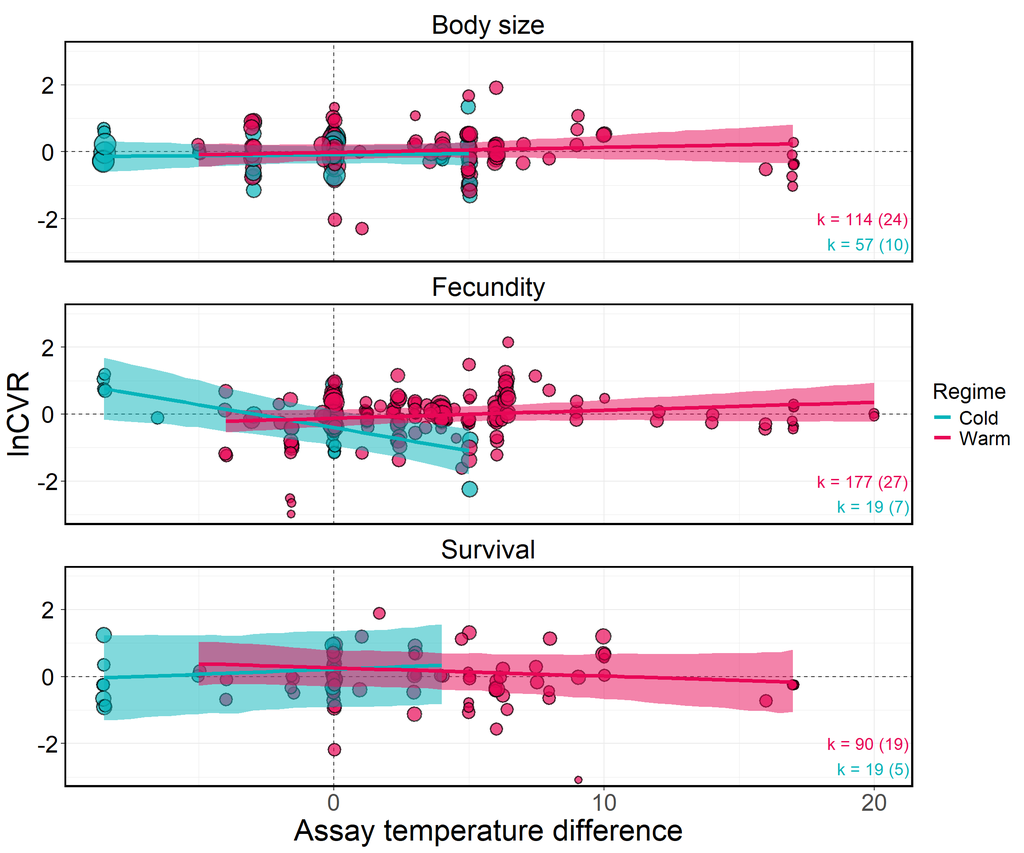

```r
# Generate predictions for all assay temperatures
emmeans_full_model_assay <- as.data.frame(emmeans(
  lnCVR_model_all_moderators,
  specs = ~ assay_temp_diff * select_temp_diff * gen_selection * gen_common_garden | trait_type * warm_cold,
  at = list(assay_temp_diff = seq(min(data$assay_temp_diff), max(data$assay_temp_diff), by = 0.5) # Re-acclimated to control, or 5 degrees above/below the contol
  )))

# Calculate range of values for each category
range_df <- data %>%
  group_by(trait_type, warm_cold) %>%
  summarize(
    min_assay_temp_diff = min(assay_temp_diff),
    max_assay_temp_diff = max(assay_temp_diff)
  )

# Rename variable levels
emmeans_full_model_assay$trait_type <- factor(emmeans_full_model_assay$trait_type,
                          levels = c("body_size", "fecundity", "survival"),
                          labels = c("Body size", "Fecundity", "Survival"))

emmeans_full_model_assay$warm_cold <- factor(emmeans_full_model_assay$warm_cold,
                          levels = c("cold", "warm"),
                          labels = c("Cold", "Warm"))

# Tailor predictions to the range of the data
emmeans_full_model_assay <- emmeans_full_model_assay %>%
  left_join(range_df, by = c("trait_type", "warm_cold")) %>%
  filter(
    assay_temp_diff >= min_assay_temp_diff,
    assay_temp_diff <= max_assay_temp_diff
  )


# Plot
ggplot() +
    geom_hline(yintercept = 0, # Horizontal line
               linetype = 2,
               colour = "black",
               alpha = 0.75) +
    geom_vline(xintercept = 0, # Vertical line
               linetype = 2,
               colour = "black",
               alpha = 0.75) +
    geom_point(data = data, # Effect sizes, scaled by precision
                  aes(x = assay_temp_diff,
                      y = lnCVR,
                      size = 1/sqrt(var_lnCVR),
                      fill = warm_cold),
                  shape = 21,
                  alpha = 0.7,
                  stroke = 1,
                  position = position_jitter(width = 0.05)) +
     geom_ribbon(data = emmeans_full_model_assay, # Shaded area for credible intervals
                 aes(x = assay_temp_diff,
                     ymin = lower.HPD,
                     ymax = upper.HPD,
                     fill = warm_cold,
                     group = warm_cold),
                 alpha = .5) +
     geom_line(data = emmeans_full_model_assay,  # Predicted regression line
               aes(y = emmean,
                   x = assay_temp_diff,
                   color = warm_cold,
                   group = warm_cold),
               size = 1.5) +

    geom_text(data = sample_sizes,
              aes(x = Inf,
                  y = ifelse(warm_cold == "Warm", -2, -2.75),  # Sample sizes
                  label = paste0("k = ", estimates, " (", studies, ")"),
                  color = warm_cold),
              hjust = 1.05, size = 5, show.legend = FALSE) +

  facet_wrap(~ trait_type, ncol = 1) + # Different panels for each trait
  scale_fill_manual(values = c("#06B4BA", "#E80756"))+
  scale_color_manual(values = c("#06B4BA", "#E80756"))+
  labs(x = "Assay temperature difference", y = "lnCVR",
       col = "Regime") +
  theme_bw() +
  scale_size_continuous(range = c(2, 8))+
  theme(text = element_text(size = 25, color = "black"),
          legend.title = ggplot2::element_text(size = 18),
          legend.text = ggplot2::element_text(size = 16),
          axis.text.y = ggplot2::element_text(size = 20,
                colour = "black", hjust = 0.5),
          axis.text.x = ggplot2::element_text(size = 20),
        panel.border = element_rect(color = "black", size = 1.5),
        strip.background = element_blank(),
        strip.text = element_text(color = "black", size = 22)) +
    guides(fill = "none", size = "none")+
    coord_cartesian(ylim = c(-3, 3))
```

```r
ggsave(file = "fig/lnCVR_all_moderators_assay_temp_diff.png", width = 12, height = 10, dpi = 500)
```